# Clean PHQ data for all waves. Save a seperate RAMP baseline data for CFA in addition to all wave for GMM

K L Purves

24 September, 2021

# Setup

```r
# clear global environment
remove(list = ls())
```

Note: load tidyverse last!

```r
if(!require(summarytools)){
  install.packages("summarytools")
  library(summarytools)
}
```

```
For best results, restart R session and update pander using devtools:: or remotes::install_github('rapporter/pander')
```

```r
if(!require(ggplot2)){
  install.packages("ggplot2")
  library(ggplot2)
}
if(!require(psych)){
  install.packages("psych")
  library(psych)
}
if(!require(tidyverse)){
  install.packages("tidyverse")
  library(tidyverse)
}
```

```
x psych::%+%()    masks ggplot2::%+%()
```

```r
if(!require(kableExtra)){
  install.packages("kableExtra")
  library(kableExtra)
}
if(!require(modeest)){
  install.packages("modeest")
  library(modeest)
}
if(!require(dplyr)){
  install.packages("dplyr")
  library(dplyr)
}
```

```r
# read in the files (save to environment)

source("../../../Credentials/paths_anhedonia_analysis.R")
```

## read in all functions from function library

```r
# source all functions in the function library folder
files.sources = paste0("../functions/",list.files("../functions"))
sapply(files.sources, source)
```

```
        ../functions/add_numeric.R ../functions/calculate_totals.R
value   ?                          ?
visible FALSE                      FALSE
        ../functions/generate_items_gad.R ../functions/generate_items_masq.R
value   ?                                 ?
visible FALSE                             FALSE
        ../functions/generate_items_phq.R ../functions/relative_risk_forest.R
value   ?                                 ?
visible FALSE                             FALSE
        ../functions/rename_mplus_class_output_data.R
value   ?
visible FALSE
```

# COPING data preprocessing

## read in and rename

### COPING Baseline

```r
# Read in the data

COPING_EDGI <- readRDS(file = paste0(ilovedata, "/data_raw/2021-05-20/coping_edgi/phq_coping_edgi.rds"))
COPING_GLAD <- readRDS(file = paste0(ilovedata, "/data_raw/2021-05-20/coping_glad/phq_coping_glad.rds"))
COPING_NBR <- readRDS(file = paste0(ilovedata, "/data_raw/2021-05-20/coping_nbr/phq9_coping_nbr.rds"))

names(COPING_EDGI)
```

```
 [1] "externalDataReference"
 [2] "startDate"
 [3] "endDate"
 [4] "phq9.little_interest_or_pleasure_in_doing_things"
 [5] "phq9.feeling_down_depressed_or_hopeless"
 [6] "phq9.staying_asleep_sleeping_trouble"
 [7] "phq9.feeling_tired_or_having_little_energy"
 [8] "phq9.poor_appetite_or_overeating"
 [9] "phq9.feeling_bad_failure_family"
[10] "phq9.trouble_concentrating_reading_newspaper"
[11] "phq9.moving_fidgety_noticed_opposite"
[12] "phq9.dead_hurting_thoughts"
[13] "phq.care_difficult_home_things"
[14] "phq.pandemic_feelings_felt"
[15] "phq.little_interest_or_pleasure_in_doing_things.1"
[16] "phq.feeling_down_depressed_or_hopeless.1"
[17] "phq.staying_asleep_sleeping_trouble.1"
[18] "phq.feeling_tired_or_having_little_energy.1"
[19] "phq.poor_appetite_or_overeating.1"
[20] "phq.family_feeling_bad_failure.1"
[21] "phq.trouble_concentrating_newspaper_reading.1"
[22] "phq.moving_fidgety_opposite_slowly.1"
[23] "phq.dead_hurting_thoughts.1"
```

```r
names(COPING_GLAD)
```

```
 [1] "externalDataReference"
 [2] "startDate"
 [3] "endDate"
 [4] "phq.little_interest_or_pleasure_in_doing_things"
 [5] "phq.feeling_down_depressed_or_hopeless"
 [6] "phq.staying_asleep_sleeping_trouble"
 [7] "phq.feeling_tired_or_having_little_energy"
 [8] "phq.poor_appetite_or_overeating"
 [9] "phq.feeling_bad_failure_family"
[10] "phq.trouble_concentrating_newspaper_reading"
[11] "phq.moving_fidgety_opposite_slowly"
[12] "phq.dead_hurting_thoughts"
[13] "phq.problems_made_difficult_care"
[14] "phq.pandemic_feelings_felt"
[15] "phq.little_interest_or_pleasure_in_doing_things.1"
[16] "phq.feeling_down_depressed_or_hopeless.1"
[17] "phq.staying_asleep_sleeping_trouble.1"
[18] "phq.feeling_tired_or_having_little_energy.1"
[19] "phq.poor_appetite_or_overeating.1"
[20] "phq.feeling_bad_failure_family.1"
[21] "phq.trouble_concentrating_newspaper_reading.1"
[22] "phq.moving_fidgety_opposite_slowly.1"
[23] "phq.dead_hurting_thoughts.1"
```

```r
names(COPING_NBR)
```

```
 [1] "externalDataReference"
 [2] "startDate"
 [3] "endDate"
 [4] "subjectid"
 [5] "phq9.little_interest_or_pleasure_in_doing_things"
 [6] "phq9.feeling_down_depressed_or_hopeless"
 [7] "phq9.staying_asleep_sleeping_trouble"
 [8] "phq9.feeling_tired_or_having_little_energy"
 [9] "phq9.poor_appetite_or_overeating"
[10] "phq9.feeling_bad_failure_family"
[11] "phq9.trouble_concentrating_reading_newspaper"
[12] "phq9.moving_fidgety_noticed_opposite"
[13] "phq9.dead_hurting_thoughts"
[14] "phq.problems_made_care_difficult"
[15] "phq.pandemic_feelings_felt"
[16] "phq.little_interest_or_pleasure_in_doing_things.1"
[17] "phq.feeling_down_depressed_or_hopeless.1"
[18] "phq.staying_asleep_sleeping_trouble.1"
[19] "phq.feeling_tired_or_having_little_energy.1"
[20] "phq.poor_appetite_or_overeating.1"
[21] "phq.family_feeling_bad_failure.1"
[22] "phq.trouble_concentrating_newspaper_reading.1"
[23] "phq.moving_fidgety_opposite_slowly.1"
[24] "phq.dead_hurting_thoughts.1"
```

```r
dim(COPING_EDGI)
```

```
[1] 1146   23
```

```r
dim(COPING_GLAD)
```

```
[1] 17351    23
```

```r
dim(COPING_NBR)
```

```
[1] 25710    24
```

```r
print("n with complete cases for each sample")
```

```
[1] "n with complete cases for each sample"
```

```r
COPING_EDGI %>%
  select(-externalDataReference,-startDate,-endDate) %>%
  filter(complete.cases(.)) %>%
  dim()
```

```
[1] 809  20
```

```r
COPING_GLAD %>%
  select(-externalDataReference,-startDate,-endDate) %>%
  filter(complete.cases(.)) %>%
  dim()
```

```
[1] 10665    20
```

```r
COPING_NBR %>%
  select(-externalDataReference,-startDate,-endDate) %>%
  filter(complete.cases(.)) %>%
  dim()
```

```
[1] 7682   21
```

Select & rename relevant columns (will be a function at some point) EDGI

```r
COPING_EDGI.id.wdate <- COPING_EDGI %>% #new dataset with ID
  drop_na(externalDataReference) %>% # Drop NAs
  select(-phq.little_interest_or_pleasure_in_doing_things.1,
         -phq.feeling_down_depressed_or_hopeless.1,
         -phq.staying_asleep_sleeping_trouble.1,
         -phq.feeling_tired_or_having_little_energy.1,
         -phq.poor_appetite_or_overeating.1,
         -phq.family_feeling_bad_failure.1,
         -phq.trouble_concentrating_newspaper_reading.1,
         -phq.moving_fidgety_opposite_slowly.1,
         -phq.dead_hurting_thoughts.1,
         -phq.care_difficult_home_things,
         -phq.pandemic_feelings_felt,
         -externalDataReference,
         ID = externalDataReference, # ID
         startDate,
         endDate,
         phq9.pandemic_little_interest_or_pleasure = phq9.little_interest_or_pleasure_in_doing_things,
         phq9.pandemic_down_depressed_hopeless = phq9.feeling_down_depressed_or_hopeless,
         phq9.pandemic_trouble_falling_or_staying_asleep = phq9.staying_asleep_sleeping_trouble,
         phq9.pandemic_feel_tired_little_energy = phq9.feeling_tired_or_having_little_energy,
         phq9.pandemic_poor_appetite_or_overeating = phq9.poor_appetite_or_overeating,
         phq9.pandemic_feeling_like_a_failure = phq9.feeling_bad_failure_family,
         phq9.pandemic_trouble_concentrating = phq9.trouble_concentrating_reading_newspaper,
         phq9.pandemic_fidgeting_or_moving_slowly = phq9.moving_fidgety_noticed_opposite,
         phq9.pandemic_thoughts_better_off_dead = phq9.dead_hurting_thoughts) %>%
  relocate(ID, .before=phq9.pandemic_little_interest_or_pleasure)

COPING_EDGI.id <- COPING_EDGI %>% #new dataset with ID
  drop_na(externalDataReference) %>% # Drop NAs
  select(-phq.little_interest_or_pleasure_in_doing_things.1,
         -phq.feeling_down_depressed_or_hopeless.1,
         -phq.staying_asleep_sleeping_trouble.1,
         -phq.feeling_tired_or_having_little_energy.1,
         -phq.poor_appetite_or_overeating.1,
         -phq.family_feeling_bad_failure.1,
         -phq.trouble_concentrating_newspaper_reading.1,
         -phq.moving_fidgety_opposite_slowly.1,
         -phq.dead_hurting_thoughts.1,
         -phq.care_difficult_home_things,
         -phq.pandemic_feelings_felt,
         -externalDataReference,
         ID = externalDataReference, # ID
         -startDate,
         -endDate,
         phq9.pandemic_little_interest_or_pleasure = phq9.little_interest_or_pleasure_in_doing_things,
         phq9.pandemic_down_depressed_hopeless = phq9.feeling_down_depressed_or_hopeless,
         phq9.pandemic_trouble_falling_or_staying_asleep = phq9.staying_asleep_sleeping_trouble,
         phq9.pandemic_feel_tired_little_energy = phq9.feeling_tired_or_having_little_energy,
         phq9.pandemic_poor_appetite_or_overeating = phq9.poor_appetite_or_overeating,
         phq9.pandemic_feeling_like_a_failure = phq9.feeling_bad_failure_family,
         phq9.pandemic_trouble_concentrating = phq9.trouble_concentrating_reading_newspaper,
         phq9.pandemic_fidgeting_or_moving_slowly = phq9.moving_fidgety_noticed_opposite,
         phq9.pandemic_thoughts_better_off_dead = phq9.dead_hurting_thoughts) %>%
  relocate(ID, .before=phq9.pandemic_little_interest_or_pleasure)


# Inspect colnames
colnames(COPING_EDGI.id)
```

```
 [1] "ID"
 [2] "phq9.pandemic_little_interest_or_pleasure"
 [3] "phq9.pandemic_down_depressed_hopeless"
 [4] "phq9.pandemic_trouble_falling_or_staying_asleep"
 [5] "phq9.pandemic_feel_tired_little_energy"
 [6] "phq9.pandemic_poor_appetite_or_overeating"
 [7] "phq9.pandemic_feeling_like_a_failure"
 [8] "phq9.pandemic_trouble_concentrating"
 [9] "phq9.pandemic_fidgeting_or_moving_slowly"
[10] "phq9.pandemic_thoughts_better_off_dead"
```

```r
dim(COPING_EDGI.id)
```

```
[1] 1146   10
```

GLAD

```r
COPING_GLAD.id.wdate <- COPING_GLAD %>% #new dataset with ID
  drop_na(externalDataReference) %>% # Drop NAs
  select(-phq.little_interest_or_pleasure_in_doing_things.1,
         -phq.feeling_down_depressed_or_hopeless.1,
         -phq.staying_asleep_sleeping_trouble.1,
         -phq.feeling_tired_or_having_little_energy.1,
         -phq.poor_appetite_or_overeating.1,
         -phq.feeling_bad_failure_family.1,
         -phq.trouble_concentrating_newspaper_reading.1,
         -phq.moving_fidgety_opposite_slowly.1,
         -phq.dead_hurting_thoughts.1,
         -phq.problems_made_difficult_care,
         -phq.pandemic_feelings_felt,
         -externalDataReference,
         ID = externalDataReference, # ID
         startDate,
         endDate,
         phq9.pandemic_little_interest_or_pleasure = phq.little_interest_or_pleasure_in_doing_things,
         phq9.pandemic_down_depressed_hopeless = phq.feeling_down_depressed_or_hopeless,
         phq9.pandemic_trouble_falling_or_staying_asleep = phq.staying_asleep_sleeping_trouble,
         phq9.pandemic_feel_tired_little_energy = phq.feeling_tired_or_having_little_energy,
         phq9.pandemic_poor_appetite_or_overeating = phq.poor_appetite_or_overeating,
         phq9.pandemic_feeling_like_a_failure = phq.feeling_bad_failure_family,
         phq9.pandemic_trouble_concentrating = phq.trouble_concentrating_newspaper_reading,
         phq9.pandemic_fidgeting_or_moving_slowly = phq.moving_fidgety_opposite_slowly,
         phq9.pandemic_thoughts_better_off_dead = phq.dead_hurting_thoughts) %>%
  relocate(ID, .before=phq9.pandemic_little_interest_or_pleasure)

COPING_GLAD.id <- COPING_GLAD %>% #new dataset with ID
  drop_na(externalDataReference) %>% # Drop NAs
  select(-phq.little_interest_or_pleasure_in_doing_things.1,
         -phq.feeling_down_depressed_or_hopeless.1,
         -phq.staying_asleep_sleeping_trouble.1,
         -phq.feeling_tired_or_having_little_energy.1,
         -phq.poor_appetite_or_overeating.1,
         -phq.feeling_bad_failure_family.1,
         -phq.trouble_concentrating_newspaper_reading.1,
         -phq.moving_fidgety_opposite_slowly.1,
         -phq.dead_hurting_thoughts.1,
         -phq.problems_made_difficult_care,
         -phq.pandemic_feelings_felt,
         -externalDataReference,
         ID = externalDataReference, # ID
         -startDate,
         -endDate,
         phq9.pandemic_little_interest_or_pleasure = phq.little_interest_or_pleasure_in_doing_things,
         phq9.pandemic_down_depressed_hopeless = phq.feeling_down_depressed_or_hopeless,
         phq9.pandemic_trouble_falling_or_staying_asleep = phq.staying_asleep_sleeping_trouble,
         phq9.pandemic_feel_tired_little_energy = phq.feeling_tired_or_having_little_energy,
         phq9.pandemic_poor_appetite_or_overeating = phq.poor_appetite_or_overeating,
         phq9.pandemic_feeling_like_a_failure = phq.feeling_bad_failure_family,
         phq9.pandemic_trouble_concentrating = phq.trouble_concentrating_newspaper_reading,
         phq9.pandemic_fidgeting_or_moving_slowly = phq.moving_fidgety_opposite_slowly,
         phq9.pandemic_thoughts_better_off_dead = phq.dead_hurting_thoughts) %>%
  relocate(ID, .before=phq9.pandemic_little_interest_or_pleasure)


# Inspect colnames
colnames(COPING_GLAD.id)
```

```
 [1] "ID"
 [2] "phq9.pandemic_little_interest_or_pleasure"
 [3] "phq9.pandemic_down_depressed_hopeless"
 [4] "phq9.pandemic_trouble_falling_or_staying_asleep"
 [5] "phq9.pandemic_feel_tired_little_energy"
 [6] "phq9.pandemic_poor_appetite_or_overeating"
 [7] "phq9.pandemic_feeling_like_a_failure"
 [8] "phq9.pandemic_trouble_concentrating"
 [9] "phq9.pandemic_fidgeting_or_moving_slowly"
[10] "phq9.pandemic_thoughts_better_off_dead"
```

```r
dim(COPING_GLAD.id)
```

```
[1] 17348    10
```

NBR

```r
COPING_NBR.id.wdate <- COPING_NBR %>% #new dataset with ID
  drop_na(subjectid) %>% # Drop NAs
  select(-phq.little_interest_or_pleasure_in_doing_things.1,
         -phq.feeling_down_depressed_or_hopeless.1,
         -phq.staying_asleep_sleeping_trouble.1,
         -phq.feeling_tired_or_having_little_energy.1,
         -phq.poor_appetite_or_overeating.1,
         -phq.family_feeling_bad_failure.1,
         -phq.trouble_concentrating_newspaper_reading.1,
         -phq.moving_fidgety_opposite_slowly.1,
         -phq.dead_hurting_thoughts.1,
         -phq.problems_made_care_difficult,
         -phq.pandemic_feelings_felt,
         -externalDataReference,
         ID = subjectid, # ID
         startDate,
         endDate,
         phq9.pandemic_little_interest_or_pleasure = phq9.little_interest_or_pleasure_in_doing_things,
         phq9.pandemic_down_depressed_hopeless = phq9.feeling_down_depressed_or_hopeless,
         phq9.pandemic_trouble_falling_or_staying_asleep = phq9.staying_asleep_sleeping_trouble,
         phq9.pandemic_feel_tired_little_energy = phq9.feeling_tired_or_having_little_energy,
         phq9.pandemic_poor_appetite_or_overeating = phq9.poor_appetite_or_overeating,
         phq9.pandemic_feeling_like_a_failure = phq9.feeling_bad_failure_family,
         phq9.pandemic_trouble_concentrating = phq9.trouble_concentrating_reading_newspaper,
         phq9.pandemic_fidgeting_or_moving_slowly = phq9.moving_fidgety_noticed_opposite,
         phq9.pandemic_thoughts_better_off_dead = phq9.dead_hurting_thoughts) %>%
  relocate(ID, .before=phq9.pandemic_little_interest_or_pleasure)

COPING_NBR.id <- COPING_NBR %>% #new dataset with ID
  drop_na(subjectid) %>% # Drop NAs
  select(-phq.little_interest_or_pleasure_in_doing_things.1,
         -phq.feeling_down_depressed_or_hopeless.1,
         -phq.staying_asleep_sleeping_trouble.1,
         -phq.feeling_tired_or_having_little_energy.1,
         -phq.poor_appetite_or_overeating.1,
         -phq.family_feeling_bad_failure.1,
         -phq.trouble_concentrating_newspaper_reading.1,
         -phq.moving_fidgety_opposite_slowly.1,
         -phq.dead_hurting_thoughts.1,
         -phq.problems_made_care_difficult,
         -phq.pandemic_feelings_felt,
         -externalDataReference,
         ID = subjectid, # ID
         -startDate,
         -endDate,
         phq9.pandemic_little_interest_or_pleasure = phq9.little_interest_or_pleasure_in_doing_things,
         phq9.pandemic_down_depressed_hopeless = phq9.feeling_down_depressed_or_hopeless,
         phq9.pandemic_trouble_falling_or_staying_asleep = phq9.staying_asleep_sleeping_trouble,
         phq9.pandemic_feel_tired_little_energy = phq9.feeling_tired_or_having_little_energy,
         phq9.pandemic_poor_appetite_or_overeating = phq9.poor_appetite_or_overeating,
         phq9.pandemic_feeling_like_a_failure = phq9.feeling_bad_failure_family,
         phq9.pandemic_trouble_concentrating = phq9.trouble_concentrating_reading_newspaper,
         phq9.pandemic_fidgeting_or_moving_slowly = phq9.moving_fidgety_noticed_opposite,
         phq9.pandemic_thoughts_better_off_dead = phq9.dead_hurting_thoughts) %>%
  relocate(ID, .before=phq9.pandemic_little_interest_or_pleasure)


# Inspect colnames
colnames(COPING_NBR.id)
```

```
 [1] "ID"
 [2] "phq9.pandemic_little_interest_or_pleasure"
 [3] "phq9.pandemic_down_depressed_hopeless"
 [4] "phq9.pandemic_trouble_falling_or_staying_asleep"
 [5] "phq9.pandemic_feel_tired_little_energy"
 [6] "phq9.pandemic_poor_appetite_or_overeating"
 [7] "phq9.pandemic_feeling_like_a_failure"
 [8] "phq9.pandemic_trouble_concentrating"
 [9] "phq9.pandemic_fidgeting_or_moving_slowly"
[10] "phq9.pandemic_thoughts_better_off_dead"
```

```r
dim(COPING_NBR.id)
```

```
[1] 25706    10
```

```r
# merge GLAD, EDGI and NBR

COPING_baseline.id <- full_join(COPING_NBR.id, COPING_GLAD.id)
COPING_baseline.id <- full_join(COPING_baseline.id, COPING_EDGI.id)
COPING_baseline.id.wdate <- full_join(COPING_NBR.id.wdate, COPING_GLAD.id.wdate)
COPING_baseline.id.wdate <- full_join(COPING_baseline.id.wdate, COPING_EDGI.id.wdate)
# Check column names
COPING_baseline.id %>%
  colnames()
```

```
 [1] "ID"
 [2] "phq9.pandemic_little_interest_or_pleasure"
 [3] "phq9.pandemic_down_depressed_hopeless"
 [4] "phq9.pandemic_trouble_falling_or_staying_asleep"
 [5] "phq9.pandemic_feel_tired_little_energy"
 [6] "phq9.pandemic_poor_appetite_or_overeating"
 [7] "phq9.pandemic_feeling_like_a_failure"
 [8] "phq9.pandemic_trouble_concentrating"
 [9] "phq9.pandemic_fidgeting_or_moving_slowly"
[10] "phq9.pandemic_thoughts_better_off_dead"
```

```r
# Check dimensions
COPING_baseline.id %>%
  dim()
```

```
[1] 44200    10
```

```r
# Look at top rows of the data frame
COPING_baseline.id %>%
  head()
```

| ID | phq9.pandemic_little_interest_or_pleasure | phq9.pandemic_down_depressed_hopeless | phq9.pandemic_trouble_falling_or_staying_asleep | phq9.pandemic_feel_tired_little_energy | phq9.pandemic_poor_appetite_or_overeating | phq9.pandemic_feeling_like_a_failure | phq9.pandemic_trouble_concentrating | phq9.pandemic_fidgeting_or_moving_slowly | phq9.pandemic_thoughts_better_off_dead |
| --- | --- | --- | --- | --- | --- | --- | --- | --- | --- |
| 8f02cfda04fb4138f38e8dd36cf0 | 0 | 0 | 0 | 1 | 1 | 0 | 0 | 0 | 0 |
| f39cb9cd7489289bdb46e9dd98ae | 3 | 2 | 2 | 3 | 1 | 0 | 1 | 0 | 0 |
| d7402c944dbeb694950c572693df | 0 | 0 | 0 | 0 | 0 | 0 | 0 | 0 | 0 |
| 9f307c106b8deae8abc405372291 | 0 | 1 | 0 | 0 | 0 | 0 | 0 | 0 | 0 |
| e898ec4564bc3895ede55a689ae0 | 0 | 0 | 0 | 1 | 0 | 0 | 0 | 0 | 0 |
| 9139c19d286610622613d76e7014 | 0 | 0 | 0 | 0 | 0 | 0 | 0 | 0 | 0 |

### COPING follow up A

```r
# Read in the data
COPING_followupA <- readRDS(file = paste0(ilovedata, "/data_raw/2021-05-20/coping_followupa/phq_coping_followupa.rds"))

  # Check column names
COPING_followupA %>%
  colnames()
```

```
 [1] "externalDataReference"
 [2] "startDate"
 [3] "endDate"
 [4] "phq.little_interest_or_pleasure_in_doing_things"
 [5] "phq.feeling_down_depressed_or_hopeless"
 [6] "phq.staying_asleep_sleeping_trouble"
 [7] "phq.feeling_tired_or_having_little_energy"
 [8] "phq.poor_appetite_or_overeating"
 [9] "phq.failure_feeling_bad_family"
[10] "phq.newspaper_reading_things_trouble"
[11] "phq.slowly_speaking_moving_noticed"
[12] "phq.fidgety_opposite_moving_restless"
[13] "phq.dead_hurting_thoughts"
[14] "phq.difficult_daily_life_issues"
```

```r
# Check dimensions
COPING_followupA %>%
  dim()
```

```
[1] 22564    14
```

```r
# Look at top rows of the data frame
COPING_followupA %>%
  arrange(externalDataReference) %>%
  head()
```

| externalDataReference | startDate | endDate | phq.little_interest_or_pleasure_in_doing_things | phq.feeling_down_depressed_or_hopeless | phq.staying_asleep_sleeping_trouble | phq.feeling_tired_or_having_little_energy | phq.poor_appetite_or_overeating | phq.failure_feeling_bad_family | phq.newspaper_reading_things_trouble | phq.slowly_speaking_moving_noticed | phq.fidgety_opposite_moving_restless | phq.dead_hurting_thoughts | phq.difficult_daily_life_issues |
| --- | --- | --- | --- | --- | --- | --- | --- | --- | --- | --- | --- | --- | --- |
| 0000e9e5feb12a3dab32a15cd151 | 2020-05-23 11:34:55 | 2020-05-23 11:49:18 | 2 | 1 | 3 | 2 | 3 | 1 | 3 | NA | 1 | 0 | 3 |
| 0006b6a1a44f4ea092926c85a08e | 2020-05-23 18:07:43 | 2020-05-23 18:55:48 | 3 | 1 | 3 | 3 | 3 | 1 | 0 | NA | 0 | 0 | 2 |
| 000f4306a31e97635bd552e36682 | 2020-05-19 08:41:30 | 2020-05-23 09:02:56 | 2 | 1 | 3 | 2 | 3 | 1 | 3 | NA | 1 | 1 | 3 |
| 0014d1eadd3684e8f8d8e9964bbf | 2020-05-19 10:18:23 | 2020-05-19 10:41:33 | 0 | 0 | 0 | 0 | 1 | 0 | 0 | NA | 0 | 0 | 1 |
| 0016a676549c629e8193327e6545 | 2020-05-19 19:55:07 | 2020-05-19 20:07:22 | 1 | 0 | 0 | 1 | 0 | 0 | 0 | NA | 0 | 0 | 1 |
| 001912c7f3f3a50d35a35d7759ab | 2020-05-23 16:00:48 | 2020-05-23 16:34:44 | 3 | 2 | 3 | 3 | 3 | 2 | 2 | NA | 1 | 1 | 2 |

```r
COPING_followupA.id <- COPING_followupA %>% #new dataset with ID
  drop_na(externalDataReference) %>% # Drop NAs
  add_column(sample = "COPING_followupA", .after = "externalDataReference") %>% #create new column
  select(-phq.difficult_daily_life_issues,
         ID = externalDataReference, # ID
         sample,
         startDate,
         endDate,
         phq9.pandemic_little_interest_or_pleasure = phq.little_interest_or_pleasure_in_doing_things,
         phq9.pandemic_down_depressed_hopeless = phq.feeling_down_depressed_or_hopeless,
         phq9.pandemic_trouble_falling_or_staying_asleep = phq.staying_asleep_sleeping_trouble,
         phq9.pandemic_feel_tired_little_energy = phq.feeling_tired_or_having_little_energy,
         phq9.pandemic_poor_appetite_or_overeating = phq.poor_appetite_or_overeating,
         phq9.pandemic_feeling_like_a_failure = phq.failure_feeling_bad_family,
         phq9.pandemic_trouble_concentrating = phq.newspaper_reading_things_trouble,
         phq9.pandemic_moving_slowy = phq.slowly_speaking_moving_noticed,
         phq9.pandemic_fidgeting = phq.fidgety_opposite_moving_restless,
         phq9.pandemic_thoughts_better_off_dead = phq.dead_hurting_thoughts)

# Inspect colnames
colnames(COPING_followupA.id)
```

```
 [1] "ID"
 [2] "sample"
 [3] "startDate"
 [4] "endDate"
 [5] "phq9.pandemic_little_interest_or_pleasure"
 [6] "phq9.pandemic_down_depressed_hopeless"
 [7] "phq9.pandemic_trouble_falling_or_staying_asleep"
 [8] "phq9.pandemic_feel_tired_little_energy"
 [9] "phq9.pandemic_poor_appetite_or_overeating"
[10] "phq9.pandemic_feeling_like_a_failure"
[11] "phq9.pandemic_trouble_concentrating"
[12] "phq9.pandemic_moving_slowy"
[13] "phq9.pandemic_fidgeting"
[14] "phq9.pandemic_thoughts_better_off_dead"
```

### COPING follow up B

```r
# Read in the data
COPING_followupB <- readRDS(file = paste0(ilovedata, "/data_raw/2021-05-20/coping_followupb/phq_coping_followupb.rds"))

# Check column names
COPING_followupB %>%
  colnames()
```

```
 [1] "externalDataReference"
 [2] "startDate"
 [3] "endDate"
 [4] "phq.little_interest_or_pleasure_in_doing_things"
 [5] "phq.feeling_down_depressed_or_hopeless"
 [6] "phq.staying_asleep_sleeping_trouble"
 [7] "phq.feeling_tired_or_having_little_energy"
 [8] "phq.poor_appetite_or_overeating"
 [9] "phq.failure_family_feeling_bad"
[10] "phq.trouble_concentrating_newspaper_reading"
[11] "phq.slowly_noticed_speaking_moving"
[12] "phq.fidgety_opposite_moving_restless"
[13] "phq.dead_hurting_thoughts"
[14] "phq.difficult_daily_life_issues"
```

```r
# Check dimensions
COPING_followupB %>%
  dim()
```

```
[1] 129612     14
```

```r
# Look at top rows of the data frame
COPING_followupB %>%
  arrange(externalDataReference) %>%
  head()
```

| externalDataReference | startDate | endDate | phq.little_interest_or_pleasure_in_doing_things | phq.feeling_down_depressed_or_hopeless | phq.staying_asleep_sleeping_trouble | phq.feeling_tired_or_having_little_energy | phq.poor_appetite_or_overeating | phq.failure_family_feeling_bad | phq.trouble_concentrating_newspaper_reading | phq.slowly_noticed_speaking_moving | phq.fidgety_opposite_moving_restless | phq.dead_hurting_thoughts | phq.difficult_daily_life_issues |
| --- | --- | --- | --- | --- | --- | --- | --- | --- | --- | --- | --- | --- | --- |
| 0000e9e5feb12a3dab32a15cd151 | 2020-06-02 18:36:22 | 2020-06-02 18:44:44 | 1 | 1 | 1 | 1 | 1 | 1 | 1 | NA | 0 | 0 | 2 |
| 0000e9e5feb12a3dab32a15cd151 | 2020-07-01 18:27:14 | 2020-07-01 18:39:55 | 1 | 1 | 2 | 2 | 2 | 1 | 1 | NA | 0 | 0 | 2 |
| 0000e9e5feb12a3dab32a15cd151 | 2020-07-29 08:36:58 | 2020-07-29 08:49:43 | 1 | 1 | 2 | 2 | 2 | 1 | 2 | NA | 0 | 0 | 2 |
| 0000e9e5feb12a3dab32a15cd151 | 2020-09-22 17:11:31 | 2020-09-22 17:26:14 | 2 | 3 | 3 | 2 | 2 | 2 | 2 | NA | 1 | 0 | 2 |
| 0000e9e5feb12a3dab32a15cd151 | 2020-11-21 15:53:46 | 2020-11-21 16:07:47 | 1 | 1 | 2 | 2 | 2 | 1 | 2 | NA | 1 | 0 | 2 |
| 0000e9e5feb12a3dab32a15cd151 | 2021-01-17 16:12:53 | 2021-01-17 16:23:18 | 0 | 0 | 1 | 1 | 1 | 0 | 1 | NA | 0 | 0 | 2 |

Select & rename relevant columns (will be a function at some point)

```r
COPING_followupB.id <- COPING_followupB %>% #new dataset with ID
  drop_na(externalDataReference) %>% # Drop NAs
  add_column(sample = "COPING_followupB", .after = "externalDataReference") %>% #create new column
  select(-phq.difficult_daily_life_issues,
         ID = externalDataReference, # ID
         sample,
         startDate,
         endDate,
         phq9.pandemic_little_interest_or_pleasure = phq.little_interest_or_pleasure_in_doing_things,
         phq9.pandemic_down_depressed_hopeless = phq.feeling_down_depressed_or_hopeless,
         phq9.pandemic_trouble_falling_or_staying_asleep = phq.staying_asleep_sleeping_trouble,
         phq9.pandemic_feel_tired_little_energy = phq.feeling_tired_or_having_little_energy,
         phq9.pandemic_poor_appetite_or_overeating = phq.poor_appetite_or_overeating,
         phq9.pandemic_feeling_like_a_failure = phq.failure_family_feeling_bad,
         phq9.pandemic_trouble_concentrating = phq.trouble_concentrating_newspaper_reading,
         phq9.pandemic_moving_slowy = phq.slowly_noticed_speaking_moving,
         phq9.pandemic_fidgeting = phq.fidgety_opposite_moving_restless,
         phq9.pandemic_thoughts_better_off_dead = phq.dead_hurting_thoughts)


# Inspect colnames
colnames(COPING_followupB.id)
```

```
 [1] "ID"
 [2] "sample"
 [3] "startDate"
 [4] "endDate"
 [5] "phq9.pandemic_little_interest_or_pleasure"
 [6] "phq9.pandemic_down_depressed_hopeless"
 [7] "phq9.pandemic_trouble_falling_or_staying_asleep"
 [8] "phq9.pandemic_feel_tired_little_energy"
 [9] "phq9.pandemic_poor_appetite_or_overeating"
[10] "phq9.pandemic_feeling_like_a_failure"
[11] "phq9.pandemic_trouble_concentrating"
[12] "phq9.pandemic_moving_slowy"
[13] "phq9.pandemic_fidgeting"
[14] "phq9.pandemic_thoughts_better_off_dead"
```

### COPING followup A ongoing

```r
# Read in the data
COPING_followupA_ong <- readRDS(file = paste0(ilovedata, "/data_raw/2021-05-20/coping_followupa_ongoing/phq_coping_followupa_ongoing.rds"))

# Check column names
COPING_followupA_ong %>%
  colnames()
```

```
 [1] "externalDataReference"
 [2] "startDate"
 [3] "endDate"
 [4] "phq.little_interest_or_pleasure_in_doing_things"
 [5] "phq.feeling_down_depressed_or_hopeless"
 [6] "phq.staying_asleep_sleeping_trouble"
 [7] "phq.feeling_tired_or_having_little_energy"
 [8] "phq.poor_appetite_or_overeating"
 [9] "phq.failure_feeling_bad_family"
[10] "phq.newspaper_reading_things_trouble"
[11] "phq.slowly_speaking_moving_noticed"
[12] "phq.fidgety_opposite_moving_restless"
[13] "phq.dead_hurting_thoughts"
[14] "phq.difficult_daily_life_issues"
```

```r
# Check dimensions
COPING_followupA_ong %>%
  dim()
```

```
[1] 109319     14
```

```r
# Look at top rows of the data frame
COPING_followupA_ong %>%
  arrange(externalDataReference) %>%
  head()
```

| externalDataReference | startDate | endDate | phq.little_interest_or_pleasure_in_doing_things | phq.feeling_down_depressed_or_hopeless | phq.staying_asleep_sleeping_trouble | phq.feeling_tired_or_having_little_energy | phq.poor_appetite_or_overeating | phq.failure_feeling_bad_family | phq.newspaper_reading_things_trouble | phq.slowly_speaking_moving_noticed | phq.fidgety_opposite_moving_restless | phq.dead_hurting_thoughts | phq.difficult_daily_life_issues |
| --- | --- | --- | --- | --- | --- | --- | --- | --- | --- | --- | --- | --- | --- |
| 0000e9e5feb12a3dab32a15cd151 | 2020-06-16 18:11:13 | 2020-06-16 18:19:33 | 1 | 1 | 1 | 1 | 1 | 1 | 1 | NA | 0 | 0 | 2 |
| 0000e9e5feb12a3dab32a15cd151 | 2020-07-15 09:34:49 | 2020-07-15 09:44:17 | 1 | 1 | 1 | 1 | 1 | 1 | 1 | NA | 0 | 0 | 2 |
| 0000e9e5feb12a3dab32a15cd151 | 2020-08-29 09:27:02 | 2020-08-29 09:39:33 | 1 | 1 | 3 | 2 | 2 | 1 | 2 | NA | 1 | 0 | 2 |
| 0000e9e5feb12a3dab32a15cd151 | 2020-10-20 14:52:48 | 2020-10-20 15:04:19 | 1 | 1 | 2 | 2 | 1 | 1 | 1 | NA | 0 | 0 | 2 |
| 0000e9e5feb12a3dab32a15cd151 | 2020-12-19 15:28:51 | 2020-12-19 15:38:34 | 1 | 1 | 1 | 1 | 1 | 1 | 1 | NA | 0 | 0 | 2 |
| 0000e9e5feb12a3dab32a15cd151 | 2021-02-14 16:31:15 | 2021-02-14 16:40:41 | 1 | 1 | 1 | 1 | 0 | 0 | 1 | NA | 0 | 0 | 2 |

Select & rename relevant columns (will be a function at some point)

```r
COPING_followupA_ong.id <- COPING_followupA_ong %>% #new dataset with ID
  drop_na(externalDataReference) %>% # Drop NAs

  add_column(sample = "COPING_followupA_ong", .after = "externalDataReference") %>% #create new column
  select(-phq.difficult_daily_life_issues,
         ID = externalDataReference, # ID
         sample,
         startDate,
         endDate,
         phq9.pandemic_little_interest_or_pleasure = phq.little_interest_or_pleasure_in_doing_things,
         phq9.pandemic_down_depressed_hopeless = phq.feeling_down_depressed_or_hopeless,
         phq9.pandemic_trouble_falling_or_staying_asleep = phq.staying_asleep_sleeping_trouble,
         phq9.pandemic_feel_tired_little_energy = phq.feeling_tired_or_having_little_energy,
         phq9.pandemic_poor_appetite_or_overeating = phq.poor_appetite_or_overeating,
         phq9.pandemic_feeling_like_a_failure = phq.failure_feeling_bad_family,
         phq9.pandemic_trouble_concentrating = phq.newspaper_reading_things_trouble,
         phq9.pandemic_moving_slowy = phq.slowly_speaking_moving_noticed,
         phq9.pandemic_fidgeting = phq.fidgety_opposite_moving_restless,
         phq9.pandemic_thoughts_better_off_dead = phq.dead_hurting_thoughts)


# Inspect colnames
colnames(COPING_followupA_ong.id)
```

```
 [1] "ID"
 [2] "sample"
 [3] "startDate"
 [4] "endDate"
 [5] "phq9.pandemic_little_interest_or_pleasure"
 [6] "phq9.pandemic_down_depressed_hopeless"
 [7] "phq9.pandemic_trouble_falling_or_staying_asleep"
 [8] "phq9.pandemic_feel_tired_little_energy"
 [9] "phq9.pandemic_poor_appetite_or_overeating"
[10] "phq9.pandemic_feeling_like_a_failure"
[11] "phq9.pandemic_trouble_concentrating"
[12] "phq9.pandemic_moving_slowy"
[13] "phq9.pandemic_fidgeting"
[14] "phq9.pandemic_thoughts_better_off_dead"
```

# fix 10 item issue

COPING follow up PHQ coded one item (*Moving or speaking so slowly that other people could have noticed? Or the opposite - being so fidgety or restless that you have been moving around a lot more than usual?*) into two items due to early mistake which meant that only the psychomotor retardation was being captured in early cases. I am resolving by taking the highest value for either item as the persons response

```r
COPING_followupA.id <- COPING_followupA.id %>%
  mutate(phq9.pandemic_fidgeting_or_moving_slowly = case_when(!is.na(phq9.pandemic_moving_slowy) & is.na(phq9.pandemic_fidgeting) ~ .$phq9.pandemic_moving_slowy,
                                                              is.na(phq9.pandemic_moving_slowy) & !is.na(phq9.pandemic_fidgeting) ~ .$phq9.pandemic_fidgeting,
                                                              phq9.pandemic_moving_slowy == phq9.pandemic_fidgeting ~ .$phq9.pandemic_moving_slowy,
                                                              phq9.pandemic_moving_slowy > phq9.pandemic_fidgeting ~ .$phq9.pandemic_moving_slowy,
                                                              phq9.pandemic_moving_slowy < phq9.pandemic_fidgeting ~ .$phq9.pandemic_fidgeting)) %>%
  select(-phq9.pandemic_moving_slowy,
         -phq9.pandemic_fidgeting)




COPING_followupA_ong.id <- COPING_followupA_ong.id %>%
  mutate(phq9.pandemic_fidgeting_or_moving_slowly = case_when(!is.na(phq9.pandemic_moving_slowy) & is.na(phq9.pandemic_fidgeting) ~ .$phq9.pandemic_moving_slowy,
                                                              is.na(phq9.pandemic_moving_slowy) & !is.na(phq9.pandemic_fidgeting) ~ .$phq9.pandemic_fidgeting,
                                                              phq9.pandemic_moving_slowy == phq9.pandemic_fidgeting ~ .$phq9.pandemic_moving_slowy,
                                                              phq9.pandemic_moving_slowy > phq9.pandemic_fidgeting ~ .$phq9.pandemic_moving_slowy,
                                                              phq9.pandemic_moving_slowy < phq9.pandemic_fidgeting ~ .$phq9.pandemic_fidgeting)) %>%
  select(-phq9.pandemic_moving_slowy,
         -phq9.pandemic_fidgeting)


COPING_followupB.id <- COPING_followupB.id %>%
  mutate(phq9.pandemic_fidgeting_or_moving_slowly = case_when(!is.na(phq9.pandemic_moving_slowy) & is.na(phq9.pandemic_fidgeting) ~ .$phq9.pandemic_moving_slowy,
                                                              is.na(phq9.pandemic_moving_slowy) & !is.na(phq9.pandemic_fidgeting) ~ .$phq9.pandemic_fidgeting,
                                                              phq9.pandemic_moving_slowy == phq9.pandemic_fidgeting ~ .$phq9.pandemic_moving_slowy,
                                                              phq9.pandemic_moving_slowy > phq9.pandemic_fidgeting ~ .$phq9.pandemic_moving_slowy,
                                                              phq9.pandemic_moving_slowy < phq9.pandemic_fidgeting ~ .$phq9.pandemic_fidgeting)) %>%
  select(-phq9.pandemic_moving_slowy,
         -phq9.pandemic_fidgeting)




names(COPING_followupA_ong.id)
```

```
 [1] "ID"
 [2] "sample"
 [3] "startDate"
 [4] "endDate"
 [5] "phq9.pandemic_little_interest_or_pleasure"
 [6] "phq9.pandemic_down_depressed_hopeless"
 [7] "phq9.pandemic_trouble_falling_or_staying_asleep"
 [8] "phq9.pandemic_feel_tired_little_energy"
 [9] "phq9.pandemic_poor_appetite_or_overeating"
[10] "phq9.pandemic_feeling_like_a_failure"
[11] "phq9.pandemic_trouble_concentrating"
[12] "phq9.pandemic_thoughts_better_off_dead"
[13] "phq9.pandemic_fidgeting_or_moving_slowly"
```

```r
names(COPING_followupA.id)
```

```
 [1] "ID"
 [2] "sample"
 [3] "startDate"
 [4] "endDate"
 [5] "phq9.pandemic_little_interest_or_pleasure"
 [6] "phq9.pandemic_down_depressed_hopeless"
 [7] "phq9.pandemic_trouble_falling_or_staying_asleep"
 [8] "phq9.pandemic_feel_tired_little_energy"
 [9] "phq9.pandemic_poor_appetite_or_overeating"
[10] "phq9.pandemic_feeling_like_a_failure"
[11] "phq9.pandemic_trouble_concentrating"
[12] "phq9.pandemic_thoughts_better_off_dead"
[13] "phq9.pandemic_fidgeting_or_moving_slowly"
```

```r
names(COPING_followupB.id)
```

```
 [1] "ID"
 [2] "sample"
 [3] "startDate"
 [4] "endDate"
 [5] "phq9.pandemic_little_interest_or_pleasure"
 [6] "phq9.pandemic_down_depressed_hopeless"
 [7] "phq9.pandemic_trouble_falling_or_staying_asleep"
 [8] "phq9.pandemic_feel_tired_little_energy"
 [9] "phq9.pandemic_poor_appetite_or_overeating"
[10] "phq9.pandemic_feeling_like_a_failure"
[11] "phq9.pandemic_trouble_concentrating"
[12] "phq9.pandemic_thoughts_better_off_dead"
[13] "phq9.pandemic_fidgeting_or_moving_slowly"
```

## Creating follow up time points

### Create waves within the FOLLOW UP DATA

Note: dates from google sheet from Kirstin Checked with Gerome - set start date as the date the survey was released, and keep window open until the DAY BEFORE the next survey was released

NOTE: Am changing wave indicators to be in order

For those who did an earlier wave during the time frame of a later wave, I include them in the later wave.

Include RAMP waves in ordering, even though COPING waves started later. So some earlier waves will only be RAMP

### merge datasets

doing this before identifying wave dates as there are some people who have duplicated data per wave between datasets (e.g. if there were individual links sent to someone who needed to restart I assume). So need to get latest data for a wave from every possible point.

```r
follow_up_list <- list(COPING_followupA.id,
                       COPING_followupA_ong.id,
                       COPING_followupB.id)

COPING_followup.id <- plyr::join_all(follow_up_list,
                                     type="full")
# April/May (wave 1) - FOLLOW UP A
ramp_start1 <- as.POSIXct("2020-04-21")
ramp_end1 <-  as.POSIXct("2020-05-04")

# May (wave 2) - FOLLOW UP B
ramp_start2 <- as.POSIXct("2020-05-05")
ramp_end2<-  as.POSIXct("2020-05-18")


# MAY 2 (wave 3) - FOLLOW UP A
start1 <- as.POSIXct("2020-05-19")
end1 <-  as.POSIXct("2020-06-01")

# JUNE 1 (wave 4) - FOLLOW UP B
start2 <- as.POSIXct("2020-06-02")
end2<-  as.POSIXct("2020-06-15")

# JUNE 2 (wave 5) - FOLLOW UP A
start3 <- as.POSIXct("2020-06-16")
end3 <-  as.POSIXct("2020-06-29")

# JULY 1 (wave 6) - FOLLOW UP B
start4 <- as.POSIXct("2020-06-30")
end4<-  as.POSIXct("2020-07-13")

# JULY 2 (wave 7) - FOLLOW UP A
start5 <- as.POSIXct("2020-07-14")
end5 <-  as.POSIXct("2020-07-27") ## Ongoing starts from here?

# JULY - AUG (wave 8) - FOLLOW UP B
start6 <- as.POSIXct("2020-07-28")
end6 <-  as.POSIXct("2020-08-24")

# AUG - SEPT (wave 9) - FOLLOW UP A
start7 <- as.POSIXct("2020-08-25")
end7 <-  as.POSIXct("2020-09-21")

# SEPT - OCT (wave 10) - FOLLOW UP B
start8 <- as.POSIXct("2020-09-22")
end8 <-  as.POSIXct("2020-10-19")

# OCT - NOV (wave 11) - FOLLOW UP A
start9 <- as.POSIXct("2020-10-20")
end9 <-  as.POSIXct("2020-11-16")

# NOV - DEC (wave 12) - FOLLOW UP B
start10 <- as.POSIXct("2020-11-17")
end10 <-  as.POSIXct("2020-12-14")

# DEC - JAN (wave 13) - FOLLOW UP A
start11 <- as.POSIXct("2020-12-15")
end11 <-  as.POSIXct("2021-01-11")

# JAN - FEB (wave 14) - FOLLOW UP B
start12 <- as.POSIXct("2021-01-12")
end12 <-  as.POSIXct("2021-02-08")

# FEB - MARCH (wave 15) - FOLLOW UP A
start13 <- as.POSIXct("2021-02-09")
end13 <-  as.POSIXct("2021-03-08")

# MARCH - APR (wave 16) - FOLLOW UP B
start14 <- as.POSIXct("2021-03-09")
end14 <-  as.POSIXct("2021-04-05")

# APR - MAY (wave 17) - FOLLOW UP A
start15 <- as.POSIXct("2021-04-06")
end15 <-  as.POSIXct("2021-05-03")

# MAY - JUNE (wave 18) - FOLLOW UP B
start16 <- as.POSIXct("2021-05-04")
end16 <-  as.POSIXct("2021-05-31")

# JUNE - JULY (wave 19) - FOLLOW UP A
start17 <- as.POSIXct("2021-06-01")
end17 <-  as.POSIXct("2021-06-28")

# JUNE - JULY (wave 20) - FOLLOW UP B
start18 <- as.POSIXct("2021-06-29")
end18 <-  as.POSIXct("2021-07-26")

# JUNE - JULY (wave 21) - FOLLOW UP A
start19 <- as.POSIXct("2021-07-27")
end19 <-  as.POSIXct("2021-08-17")


COPING_followup.id <- COPING_followup.id %>%
  mutate(wave = case_when(startDate >= start1 & startDate < end1 ~ ".Wave_03",
                           startDate >= start2 & startDate <= end2 ~ ".Wave_04",
                            startDate >= start3 & startDate <= end3 ~ ".Wave_05",
                           startDate >= start4 & startDate < start5 ~ ".Wave_06",
                            startDate >= start5 & startDate < start6 ~ ".Wave_07",
                           startDate >= start6 & startDate <= end6 ~ ".Wave_08",
                            startDate >= start7 & startDate <= end7 ~ ".Wave_09",
                           startDate >= start8 & startDate <= end8 ~ ".Wave_10",
                            startDate >= start9 & startDate <= end9 ~ ".Wave_11",
                           startDate >= start10 & startDate <= end10 ~ ".Wave_12",
                            startDate >= start11 & startDate <= end11 ~ ".Wave_13",
                           startDate >= start12 & startDate <= end12 ~ ".Wave_14",
                            startDate >= start13 & startDate <= end13 ~ ".Wave_15",
                              startDate >= start14 & startDate <= end14 ~ ".Wave_16",
                            startDate >= start15 & startDate <= end15 ~ ".Wave_17",
                            startDate >= start16 & startDate <= end16 ~ ".Wave_18",
                           startDate >= start17 & startDate <= end17 ~ ".Wave_19",
                           startDate >= start18 & startDate <= end18 ~ ".Wave_20",
                            startDate >= start19 & startDate <= end19 ~ ".Wave_21"))
```

### check for number of entries per wave

```r
COPING_followup.id %>%
  group_by(wave) %>%
  count()
```

| wave | n |
| --- | --- |
| .Wave_03 | 17385 |
| .Wave_04 | 19874 |
| .Wave_05 | 18685 |
| .Wave_06 | 18070 |
| .Wave_07 | 16290 |
| .Wave_08 | 15076 |
| .Wave_09 | 15975 |
| .Wave_10 | 15274 |
| .Wave_11 | 16566 |
| .Wave_12 | 16438 |

[output cut: 6 more lines]

### Identifying duplicate IDs in a single wave

```r
##Identify dup IDs in a single wave (all)
COPING_followup.id %>%
   group_by(wave, ID) %>%
   dplyr::summarize(N = n()) %>%
   filter(N > 1)
```

| wave | ID | N |
| --- | --- | --- |
| .Wave_03 | 033c708389648ac9c38eea689a6e | 2 |
| .Wave_03 | 09c410911cd73b151d32fd317042 | 2 |
| .Wave_03 | 0b70441994b4fa7c9bd03a614809 | 2 |
| .Wave_03 | 0c1b472a2a82c7a7ae59e1e235fb | 2 |
| .Wave_03 | 1258ffaac40c87c0c38c8bb0467e | 2 |
| .Wave_03 | 1bda5628e3941afc7a19e04c00c7 | 2 |
| .Wave_03 | 1deca074480b682dcad64d18b2ed | 2 |
| .Wave_03 | 232defe2b9719b1fadc3af8fde58 | 2 |
| .Wave_03 | 246bf40d415db2470ced43c41c73 | 2 |
| .Wave_03 | 34edb3649d65a880466b18321048 | 2 |

[output cut: 449 more lines]

```r
##Identify dup IDs in baseline
COPING_baseline.id %>%
   group_by(ID) %>%
   dplyr::summarize(N = n()) %>%
   filter(N > 1)
```

| ID | N |
| --- | --- |
| 000e2194998f18c2f65207cabdb7 | 2 |
| 00229e3549ecd0cb51f074940ab2 | 2 |
| 004e8d68ed4379eba909205e7bee | 2 |
| 0065ef6e0460de35ab88595507cf | 2 |
| 006e85252d9dad7cf70ccb3f60d6 | 2 |
| 00745ccacda1f1568d8142edb95d | 2 |
| 008bae1d4c787e4ec736a3b34d8d | 2 |
| 0091b9ba9ecd26b3e67a03ee7b9a | 2 |
| 00a413507bcf49e779fbeafcd17a | 2 |
| 00a9bd32503bbc3920354fc22db3 | 2 |

[output cut: 2582 more lines]

**removing duplicates, retaining the latest possible data where there are repeats**

### Retain most recent completion where duplicate completions

We want there to be unique IDs within each of the waves

```r
##FOLLOW UP
##confirm number of rows in current dataset
nrow(COPING_followup.id)
```

```
[1] 261291
```

```r
#Filter out duplicated IDs AND wave, keeping the LAST entry
COPING_followup.id <- COPING_followup.id %>%
    group_by(ID) %>%
    filter(!duplicated(wave,
                      fromLast = TRUE)
           )

##confirm number of rows in dataset after filtering (should be 22485)
nrow(COPING_followup.id)
```

```
[1] 260827
```

```r
##BASELINE
##confirm number of rows in current dataset
nrow(COPING_baseline.id)
```

```
[1] 44200
```

```r
#Filter out duplicated IDs AND wave, keeping the LAST entry
COPING_baseline.id <- COPING_baseline.id %>%
    group_by(ID) %>%
    filter(!duplicated(ID,
                          fromLast = TRUE)
           ) %>%
  ungroup(ID)

##confirm number of rows in dataset after filtering
nrow(COPING_baseline.id)
```

```
[1] 41496
```

## Change COPING follow up from long to wide format

```r
COPING_followup.id.long <- COPING_followup.id %>%
  group_by(wave) %>%
  tidyr::pivot_wider(id_cols = ID,
    names_from = wave,
                     values_from = c(phq9.pandemic_little_interest_or_pleasure,
                                     phq9.pandemic_down_depressed_hopeless,
                                     phq9.pandemic_trouble_falling_or_staying_asleep,
                                     phq9.pandemic_feel_tired_little_energy,
                                     phq9.pandemic_poor_appetite_or_overeating,
                                     phq9.pandemic_feeling_like_a_failure,
                                     phq9.pandemic_trouble_concentrating,
                                     phq9.pandemic_fidgeting_or_moving_slowly,
                                     phq9.pandemic_thoughts_better_off_dead))




# Check
colnames(COPING_followup.id.long)
```

```
  [1] "ID"
  [2] "phq9.pandemic_little_interest_or_pleasure_.Wave_03"
  [3] "phq9.pandemic_little_interest_or_pleasure_.Wave_05"
  [4] "phq9.pandemic_little_interest_or_pleasure_.Wave_06"
  [5] "phq9.pandemic_little_interest_or_pleasure_.Wave_07"
  [6] "phq9.pandemic_little_interest_or_pleasure_.Wave_08"
  [7] "phq9.pandemic_little_interest_or_pleasure_.Wave_09"
  [8] "phq9.pandemic_little_interest_or_pleasure_.Wave_10"
  [9] "phq9.pandemic_little_interest_or_pleasure_.Wave_11"
 [10] "phq9.pandemic_little_interest_or_pleasure_.Wave_13"
 [11] "phq9.pandemic_little_interest_or_pleasure_.Wave_15"
 [12] "phq9.pandemic_little_interest_or_pleasure_.Wave_16"
 [13] "phq9.pandemic_little_interest_or_pleasure_.Wave_17"
 [14] "phq9.pandemic_little_interest_or_pleasure_.Wave_18"
 [15] "phq9.pandemic_little_interest_or_pleasure_.Wave_04"
```

[output cut: 130 more lines]

```r
dim(COPING_followup.id.long)
```

```
[1] 26234   145
```

# Clean COPING data

## Set minimum and maximum values

```r
phq.min.scale <- 0
phq.max.scale <- 3
```

## COPING baseline

add wave 0 to the end of all variable names to indicate baseline

```r
COPING_baseline.id <- COPING_baseline.id %>%
  rename_with( ~ paste(.x, ".Wave_0", sep = "_"), starts_with("phq")) # Add suffix "unc" for all uncleaned data columns

# check
colnames(COPING_baseline.id)
```

```
 [1] "ID"
 [2] "phq9.pandemic_little_interest_or_pleasure_.Wave_0"
 [3] "phq9.pandemic_down_depressed_hopeless_.Wave_0"
 [4] "phq9.pandemic_trouble_falling_or_staying_asleep_.Wave_0"
 [5] "phq9.pandemic_feel_tired_little_energy_.Wave_0"
 [6] "phq9.pandemic_poor_appetite_or_overeating_.Wave_0"
 [7] "phq9.pandemic_feeling_like_a_failure_.Wave_0"
 [8] "phq9.pandemic_trouble_concentrating_.Wave_0"
 [9] "phq9.pandemic_fidgeting_or_moving_slowly_.Wave_0"
[10] "phq9.pandemic_thoughts_better_off_dead_.Wave_0"
```

```r
COPING_baseline.id <- COPING_baseline.id %>%
  rename_with( ~ paste(.x, "unc", sep = "_"), starts_with("phq")) # Add suffix "unc" for all uncleaned data columns

# check
colnames(COPING_baseline.id)
```

```
 [1] "ID"
 [2] "phq9.pandemic_little_interest_or_pleasure_.Wave_0_unc"
 [3] "phq9.pandemic_down_depressed_hopeless_.Wave_0_unc"
 [4] "phq9.pandemic_trouble_falling_or_staying_asleep_.Wave_0_unc"
 [5] "phq9.pandemic_feel_tired_little_energy_.Wave_0_unc"
 [6] "phq9.pandemic_poor_appetite_or_overeating_.Wave_0_unc"
 [7] "phq9.pandemic_feeling_like_a_failure_.Wave_0_unc"
 [8] "phq9.pandemic_trouble_concentrating_.Wave_0_unc"
 [9] "phq9.pandemic_fidgeting_or_moving_slowly_.Wave_0_unc"
[10] "phq9.pandemic_thoughts_better_off_dead_.Wave_0_unc"
```

```r
COPING_baseline.id %>%
  freq(phq9.pandemic_down_depressed_hopeless_.Wave_0_unc)
```

```
Frequencies
COPING_baseline.id$phq9.pandemic_down_depressed_hopeless_.Wave_0_unc
Label: Over the last 2 weeks, how often have you been bothered by any of the following problems? Feeling down, depressed or hopeless
Type: Numeric

               Freq   % Valid   % Valid Cum.   % Total   % Total Cum.
----------- ------- --------- -------------- --------- --------------
        -77      58      0.19           0.19      0.14           0.14
          0   12957     42.66          42.85     31.22          31.36
          1   11302     37.21          80.07     27.24          58.60
          2    3348     11.02          91.09      8.07          66.67
          3    2706      8.91         100.00      6.52          73.19
       <NA>   11125                              26.81         100.00
      Total   41496    100.00         100.00    100.00         100.00
```

### Make list of variables for cleaning

```r
phq.items.baseline_unc <- COPING_baseline.id %>%
  select(contains("_unc")) %>%
  colnames()

phq.items.baseline_unc
```

```
[1] "phq9.pandemic_little_interest_or_pleasure_.Wave_0_unc"
[2] "phq9.pandemic_down_depressed_hopeless_.Wave_0_unc"
[3] "phq9.pandemic_trouble_falling_or_staying_asleep_.Wave_0_unc"
[4] "phq9.pandemic_feel_tired_little_energy_.Wave_0_unc"
[5] "phq9.pandemic_poor_appetite_or_overeating_.Wave_0_unc"
[6] "phq9.pandemic_feeling_like_a_failure_.Wave_0_unc"
[7] "phq9.pandemic_trouble_concentrating_.Wave_0_unc"
[8] "phq9.pandemic_fidgeting_or_moving_slowly_.Wave_0_unc"
[9] "phq9.pandemic_thoughts_better_off_dead_.Wave_0_unc"
```

### Recode implausuble values

```r
# Recode and clean
COPING_baseline.id <- COPING_baseline.id %>%
   mutate(
     across(all_of(phq.items.baseline_unc),
            .fns = list(clean = ~case_when( # add "_clean" onto the variables you are cleaning
              . == -77 | . == -88 | . == -99 ~ ., # leave as is
              . < phq.min.scale | . > phq.max.scale ~ -66, # recode as implausible value
              TRUE ~ . # leave as is
            )
            )
     )
   ) %>%
   rename_at(
     vars(contains( "_unc_clean")), # specify variables that now contain "_clean"
     list(~paste0(gsub("_unc_clean", "", .))) # remove the "_clean" now that they have been cleaned
   )

# Check
colnames(COPING_baseline.id)
```

```
 [1] "ID"
 [2] "phq9.pandemic_little_interest_or_pleasure_.Wave_0_unc"
 [3] "phq9.pandemic_down_depressed_hopeless_.Wave_0_unc"
 [4] "phq9.pandemic_trouble_falling_or_staying_asleep_.Wave_0_unc"
 [5] "phq9.pandemic_feel_tired_little_energy_.Wave_0_unc"
 [6] "phq9.pandemic_poor_appetite_or_overeating_.Wave_0_unc"
 [7] "phq9.pandemic_feeling_like_a_failure_.Wave_0_unc"
 [8] "phq9.pandemic_trouble_concentrating_.Wave_0_unc"
 [9] "phq9.pandemic_fidgeting_or_moving_slowly_.Wave_0_unc"
[10] "phq9.pandemic_thoughts_better_off_dead_.Wave_0_unc"
[11] "phq9.pandemic_little_interest_or_pleasure_.Wave_0"
[12] "phq9.pandemic_down_depressed_hopeless_.Wave_0"
[13] "phq9.pandemic_trouble_falling_or_staying_asleep_.Wave_0"
[14] "phq9.pandemic_feel_tired_little_energy_.Wave_0"
[15] "phq9.pandemic_poor_appetite_or_overeating_.Wave_0"
[16] "phq9.pandemic_feeling_like_a_failure_.Wave_0"
[17] "phq9.pandemic_trouble_concentrating_.Wave_0"
[18] "phq9.pandemic_fidgeting_or_moving_slowly_.Wave_0"
[19] "phq9.pandemic_thoughts_better_off_dead_.Wave_0"
```

### Make new list of cleaned variables

```r
phq.items.baseline_clean <- COPING_baseline.id %>%
  select(!contains("_unc")) %>% # select the cleaned variables (i.e. they don't contain the phrase "_unc")
  select(!"ID") %>% # deselect the ID variable
  colnames()

phq.items.baseline_clean
```

```
[1] "phq9.pandemic_little_interest_or_pleasure_.Wave_0"
[2] "phq9.pandemic_down_depressed_hopeless_.Wave_0"
[3] "phq9.pandemic_trouble_falling_or_staying_asleep_.Wave_0"
[4] "phq9.pandemic_feel_tired_little_energy_.Wave_0"
[5] "phq9.pandemic_poor_appetite_or_overeating_.Wave_0"
[6] "phq9.pandemic_feeling_like_a_failure_.Wave_0"
[7] "phq9.pandemic_trouble_concentrating_.Wave_0"
[8] "phq9.pandemic_fidgeting_or_moving_slowly_.Wave_0"
[9] "phq9.pandemic_thoughts_better_off_dead_.Wave_0"
```

### Check number of implausible values

```r
# Check for implausible values
phq_baseline_imp_n <- COPING_baseline.id %>%
  select(all_of(phq.items.baseline_clean)) %>%
  filter(. == -66) %>%
  nrow()

# If statement
if (phq_baseline_imp_n == 0) {
  print(paste0("The number of implausible values in the coping follow up A phq variables is ", phq_baseline_imp_n, ". Can leave these variables as they are."))
} else {
  print(paste0("The number of implausible values in the coping follow up A phq variables is ", phq_baseline_imp_n, ". Please investigate."))
}
```

```
[1] "The number of implausible values in the coping follow up A phq variables is 0. Can leave these variables as they are."
```

### Select only the clean variables and replocate ID to front

Note: keep ID in this data set

```r
COPING_baseline.id.clean <- COPING_baseline.id %>%
  select(!contains("_unc"))

colnames(COPING_baseline.id.clean)
```

```
 [1] "ID"
 [2] "phq9.pandemic_little_interest_or_pleasure_.Wave_0"
 [3] "phq9.pandemic_down_depressed_hopeless_.Wave_0"
 [4] "phq9.pandemic_trouble_falling_or_staying_asleep_.Wave_0"
 [5] "phq9.pandemic_feel_tired_little_energy_.Wave_0"
 [6] "phq9.pandemic_poor_appetite_or_overeating_.Wave_0"
 [7] "phq9.pandemic_feeling_like_a_failure_.Wave_0"
 [8] "phq9.pandemic_trouble_concentrating_.Wave_0"
 [9] "phq9.pandemic_fidgeting_or_moving_slowly_.Wave_0"
[10] "phq9.pandemic_thoughts_better_off_dead_.Wave_0"
```

## COPING follow up

```r
COPING_followup.id.long <- COPING_followup.id.long %>%
  rename_with( ~ paste(.x, "unc", sep = "_"), starts_with("phq")) # Add suffix "unc" for all uncleaned data columns

# check
colnames(COPING_followup.id.long)
```

```
  [1] "ID"
  [2] "phq9.pandemic_little_interest_or_pleasure_.Wave_03_unc"
  [3] "phq9.pandemic_little_interest_or_pleasure_.Wave_05_unc"
  [4] "phq9.pandemic_little_interest_or_pleasure_.Wave_06_unc"
  [5] "phq9.pandemic_little_interest_or_pleasure_.Wave_07_unc"
  [6] "phq9.pandemic_little_interest_or_pleasure_.Wave_08_unc"
  [7] "phq9.pandemic_little_interest_or_pleasure_.Wave_09_unc"
  [8] "phq9.pandemic_little_interest_or_pleasure_.Wave_10_unc"
  [9] "phq9.pandemic_little_interest_or_pleasure_.Wave_11_unc"
 [10] "phq9.pandemic_little_interest_or_pleasure_.Wave_13_unc"
 [11] "phq9.pandemic_little_interest_or_pleasure_.Wave_15_unc"
 [12] "phq9.pandemic_little_interest_or_pleasure_.Wave_16_unc"
 [13] "phq9.pandemic_little_interest_or_pleasure_.Wave_17_unc"
 [14] "phq9.pandemic_little_interest_or_pleasure_.Wave_18_unc"
 [15] "phq9.pandemic_little_interest_or_pleasure_.Wave_04_unc"
```

[output cut: 130 more lines]

```r
COPING_followup.id.long %>%
  freq(phq9.pandemic_little_interest_or_pleasure_.Wave_03_unc)
```

```
Frequencies
COPING_followup.id.long$phq9.pandemic_little_interest_or_pleasure_.Wave_03_unc
Type: Numeric

               Freq   % Valid   % Valid Cum.   % Total   % Total Cum.
----------- ------- --------- -------------- --------- --------------
        -77       5     0.030          0.030     0.019          0.019
          0    7178    42.820         42.850    27.361         27.380
          1    6255    37.314         80.165    23.843         51.224
          2    1912    11.406         91.571     7.288         58.512
          3    1413     8.429        100.000     5.386         63.898
       <NA>    9471                             36.102        100.000
      Total   26234   100.000        100.000   100.000        100.000
```

### Make list of variables for cleaning

```r
phq.items.followup_unc <- COPING_followup.id.long %>%
  select(contains("_unc")) %>%
  colnames()

phq.items.followup_unc
```

```
  [1] "phq9.pandemic_little_interest_or_pleasure_.Wave_03_unc"
  [2] "phq9.pandemic_little_interest_or_pleasure_.Wave_05_unc"
  [3] "phq9.pandemic_little_interest_or_pleasure_.Wave_06_unc"
  [4] "phq9.pandemic_little_interest_or_pleasure_.Wave_07_unc"
  [5] "phq9.pandemic_little_interest_or_pleasure_.Wave_08_unc"
  [6] "phq9.pandemic_little_interest_or_pleasure_.Wave_09_unc"
  [7] "phq9.pandemic_little_interest_or_pleasure_.Wave_10_unc"
  [8] "phq9.pandemic_little_interest_or_pleasure_.Wave_11_unc"
  [9] "phq9.pandemic_little_interest_or_pleasure_.Wave_13_unc"
 [10] "phq9.pandemic_little_interest_or_pleasure_.Wave_15_unc"
 [11] "phq9.pandemic_little_interest_or_pleasure_.Wave_16_unc"
 [12] "phq9.pandemic_little_interest_or_pleasure_.Wave_17_unc"
 [13] "phq9.pandemic_little_interest_or_pleasure_.Wave_18_unc"
 [14] "phq9.pandemic_little_interest_or_pleasure_.Wave_04_unc"
 [15] "phq9.pandemic_little_interest_or_pleasure_.Wave_12_unc"
```

[output cut: 129 more lines]

### Recode implausuble values

```r
# Recode and clean
COPING_followup.id.long <- COPING_followup.id.long %>%
   mutate(
     across(all_of(phq.items.followup_unc),
            .fns = list(clean = ~case_when( # add "_clean" onto the variables you are cleaning
              . == -77 | . == -88 | . == -99 ~ ., # leave as is
              . < phq.min.scale | . > phq.max.scale ~ -66, # recode as implausible value
              TRUE ~ . # leave as is
            )
            )
     )
   ) %>%
   rename_at(
     vars(contains( "_unc_clean")), # specify variables that now contain "_clean"
     list(~paste0(gsub("_unc_clean", "", .))) # remove the "_clean" now that they have been cleaned
   )

# Check
colnames(COPING_followup.id.long)
```

```
  [1] "ID"
  [2] "phq9.pandemic_little_interest_or_pleasure_.Wave_03_unc"
  [3] "phq9.pandemic_little_interest_or_pleasure_.Wave_05_unc"
  [4] "phq9.pandemic_little_interest_or_pleasure_.Wave_06_unc"
  [5] "phq9.pandemic_little_interest_or_pleasure_.Wave_07_unc"
  [6] "phq9.pandemic_little_interest_or_pleasure_.Wave_08_unc"
  [7] "phq9.pandemic_little_interest_or_pleasure_.Wave_09_unc"
  [8] "phq9.pandemic_little_interest_or_pleasure_.Wave_10_unc"
  [9] "phq9.pandemic_little_interest_or_pleasure_.Wave_11_unc"
 [10] "phq9.pandemic_little_interest_or_pleasure_.Wave_13_unc"
 [11] "phq9.pandemic_little_interest_or_pleasure_.Wave_15_unc"
 [12] "phq9.pandemic_little_interest_or_pleasure_.Wave_16_unc"
 [13] "phq9.pandemic_little_interest_or_pleasure_.Wave_17_unc"
 [14] "phq9.pandemic_little_interest_or_pleasure_.Wave_18_unc"
 [15] "phq9.pandemic_little_interest_or_pleasure_.Wave_04_unc"
```

[output cut: 274 more lines]

### Make new list of cleaned variables

```r
phq.items.followup_clean <- COPING_followup.id.long %>%
  select(!contains("_unc")) %>% # select the cleaned variables (i.e. they don't contain the phrase "_unc")
  select(!"ID") %>% # deselect the ID variable
  colnames()

phq.items.followup_clean
```

```
  [1] "phq9.pandemic_little_interest_or_pleasure_.Wave_03"
  [2] "phq9.pandemic_little_interest_or_pleasure_.Wave_05"
  [3] "phq9.pandemic_little_interest_or_pleasure_.Wave_06"
  [4] "phq9.pandemic_little_interest_or_pleasure_.Wave_07"
  [5] "phq9.pandemic_little_interest_or_pleasure_.Wave_08"
  [6] "phq9.pandemic_little_interest_or_pleasure_.Wave_09"
  [7] "phq9.pandemic_little_interest_or_pleasure_.Wave_10"
  [8] "phq9.pandemic_little_interest_or_pleasure_.Wave_11"
  [9] "phq9.pandemic_little_interest_or_pleasure_.Wave_13"
 [10] "phq9.pandemic_little_interest_or_pleasure_.Wave_15"
 [11] "phq9.pandemic_little_interest_or_pleasure_.Wave_16"
 [12] "phq9.pandemic_little_interest_or_pleasure_.Wave_17"
 [13] "phq9.pandemic_little_interest_or_pleasure_.Wave_18"
 [14] "phq9.pandemic_little_interest_or_pleasure_.Wave_04"
 [15] "phq9.pandemic_little_interest_or_pleasure_.Wave_12"
```

[output cut: 129 more lines]

### Check number of implausible values

```r
# Check for implausible values
phq_followup_imp_n <- COPING_followup.id.long %>%
  select(all_of(phq.items.followup_clean)) %>%
  filter(. == -66) %>%
  nrow()

# If statement
if (phq_followup_imp_n == 0) {
  print(paste0("The number of implausible values in the coping follow up A phq variables is ", phq_followup_imp_n, ". Can leave these variables as they are."))
} else {
  print(paste0("The number of implausible values in the coping follow up A phq variables is ", phq_followup_imp_n, ". Please investigate."))
}
```

```
[1] "The number of implausible values in the coping follow up A phq variables is 0. Can leave these variables as they are."
```

### Select only the clean variables

Note: keep ID in this data set

```r
COPING_followup.id.long.clean <- COPING_followup.id.long %>%
  select(!contains("_unc"))

colnames(COPING_followup.id.long.clean)
```

```
  [1] "ID"
  [2] "phq9.pandemic_little_interest_or_pleasure_.Wave_03"
  [3] "phq9.pandemic_little_interest_or_pleasure_.Wave_05"
  [4] "phq9.pandemic_little_interest_or_pleasure_.Wave_06"
  [5] "phq9.pandemic_little_interest_or_pleasure_.Wave_07"
  [6] "phq9.pandemic_little_interest_or_pleasure_.Wave_08"
  [7] "phq9.pandemic_little_interest_or_pleasure_.Wave_09"
  [8] "phq9.pandemic_little_interest_or_pleasure_.Wave_10"
  [9] "phq9.pandemic_little_interest_or_pleasure_.Wave_11"
 [10] "phq9.pandemic_little_interest_or_pleasure_.Wave_13"
 [11] "phq9.pandemic_little_interest_or_pleasure_.Wave_15"
 [12] "phq9.pandemic_little_interest_or_pleasure_.Wave_16"
 [13] "phq9.pandemic_little_interest_or_pleasure_.Wave_17"
 [14] "phq9.pandemic_little_interest_or_pleasure_.Wave_18"
 [15] "phq9.pandemic_little_interest_or_pleasure_.Wave_04"
```

[output cut: 130 more lines]

# Merge COPING Baseline and follow up surveys

```r
phq.merging <- list(COPING_baseline.id.clean,
                    COPING_followup.id.long.clean)


phq.COPING <- plyr::join_all(phq.merging,
                    by = "ID",
                    type = "full")

# check
dim(COPING_followup.id.long.clean)
```

```
[1] 26234   145
```

```r
dim(COPING_baseline.id.clean)
```

```
[1] 41496    10
```

```r
dim(phq.COPING)
```

```
[1] 41499   154
```

```r
colnames(phq.COPING)
```

```
  [1] "ID"
  [2] "phq9.pandemic_little_interest_or_pleasure_.Wave_0"
  [3] "phq9.pandemic_down_depressed_hopeless_.Wave_0"
  [4] "phq9.pandemic_trouble_falling_or_staying_asleep_.Wave_0"
  [5] "phq9.pandemic_feel_tired_little_energy_.Wave_0"
  [6] "phq9.pandemic_poor_appetite_or_overeating_.Wave_0"
  [7] "phq9.pandemic_feeling_like_a_failure_.Wave_0"
  [8] "phq9.pandemic_trouble_concentrating_.Wave_0"
  [9] "phq9.pandemic_fidgeting_or_moving_slowly_.Wave_0"
 [10] "phq9.pandemic_thoughts_better_off_dead_.Wave_0"
 [11] "phq9.pandemic_little_interest_or_pleasure_.Wave_03"
 [12] "phq9.pandemic_little_interest_or_pleasure_.Wave_05"
 [13] "phq9.pandemic_little_interest_or_pleasure_.Wave_06"
 [14] "phq9.pandemic_little_interest_or_pleasure_.Wave_07"
 [15] "phq9.pandemic_little_interest_or_pleasure_.Wave_08"
```

[output cut: 139 more lines]

```r
# reorder so that it is easy to see each wave in place.
phq.COPING.reordered <- phq.COPING %>%
  select(order(names(phq.COPING)))

colnames(phq.COPING.reordered)
```

```
  [1] "ID"
  [2] "phq9.pandemic_down_depressed_hopeless_.Wave_0"
  [3] "phq9.pandemic_down_depressed_hopeless_.Wave_03"
  [4] "phq9.pandemic_down_depressed_hopeless_.Wave_04"
  [5] "phq9.pandemic_down_depressed_hopeless_.Wave_05"
  [6] "phq9.pandemic_down_depressed_hopeless_.Wave_06"
  [7] "phq9.pandemic_down_depressed_hopeless_.Wave_07"
  [8] "phq9.pandemic_down_depressed_hopeless_.Wave_08"
  [9] "phq9.pandemic_down_depressed_hopeless_.Wave_09"
 [10] "phq9.pandemic_down_depressed_hopeless_.Wave_10"
 [11] "phq9.pandemic_down_depressed_hopeless_.Wave_11"
 [12] "phq9.pandemic_down_depressed_hopeless_.Wave_12"
 [13] "phq9.pandemic_down_depressed_hopeless_.Wave_13"
 [14] "phq9.pandemic_down_depressed_hopeless_.Wave_14"
 [15] "phq9.pandemic_down_depressed_hopeless_.Wave_15"
```

[output cut: 139 more lines]

# RAMP data preprocessing

## RAMP baseline

```r
# read in baseline data
RAMP_baseline = readRDS(paste0(ilovedata,"/data_raw/2021-02-18/ramp/phq9_ramp.rds"))

# Check column names
RAMP_baseline %>%
  colnames()
```

```
 [1] "externalDataReference"
 [2] "startDate"
 [3] "endDate"
 [4] "Login ID"
 [5] "phq.little_interest_or_pleasure_in_doing_things"
 [6] "phq.feeling_down_depressed_or_hopeless"
 [7] "phq.staying_asleep_sleeping_trouble"
 [8] "phq.feeling_tired_or_having_little_energy"
 [9] "phq.poor_appetite_or_overeating"
[10] "phq.feeling_bad_failure_family"
[11] "phq.trouble_concentrating_newspaper_reading"
[12] "phq.moving_fidgety_opposite_slowly"
[13] "phq.dead_hurting_thoughts"
[14] "phq.pandemic_feelings_felt"
[15] "phq.pandemic_feelings_felt.1"
[16] "phq.little_interest_or_pleasure_in_doing_things.1"
[17] "phq.feeling_down_depressed_or_hopeless.1"
[18] "phq.staying_asleep_sleeping_trouble.1"
[19] "phq.feeling_tired_or_having_little_energy.1"
[20] "phq.poor_appetite_or_overeating.1"
[21] "phq.feeling_bad_failure_family.1"
[22] "phq.trouble_concentrating_newspaper_reading.1"
[23] "phq.moving_fidgety_opposite_slowly.1"
[24] "phq.dead_hurting_thoughts.1"
```

```r
# Check dimensions
RAMP_baseline %>%
  dim()
```

```
[1] 10942    24
```

```r
# Look at top rows of the data frame
RAMP_baseline %>%
  head()
```

| externalDataReference | startDate | endDate | Login ID | phq.little_interest_or_pleasure_in_doing_things | phq.feeling_down_depressed_or_hopeless | phq.staying_asleep_sleeping_trouble | phq.feeling_tired_or_having_little_energy | phq.poor_appetite_or_overeating | phq.feeling_bad_failure_family | phq.trouble_concentrating_newspaper_reading | phq.moving_fidgety_opposite_slowly | phq.dead_hurting_thoughts | phq.pandemic_feelings_felt | phq.pandemic_feelings_felt.1 | phq.little_interest_or_pleasure_in_doing_things.1 | phq.feeling_down_depressed_or_hopeless.1 | phq.staying_asleep_sleeping_trouble.1 | phq.feeling_tired_or_having_little_energy.1 | phq.poor_appetite_or_overeating.1 | phq.feeling_bad_failure_family.1 | phq.trouble_concentrating_newspaper_reading.1 | phq.moving_fidgety_opposite_slowly.1 | phq.dead_hurting_thoughts.1 |
| --- | --- | --- | --- | --- | --- | --- | --- | --- | --- | --- | --- | --- | --- | --- | --- | --- | --- | --- | --- | --- | --- | --- | --- |
| NA | 2020-04-07 12:54:24 | 2020-04-07 13:19:13 | b505a12db9cf8b09b0a7b82eb954 | 0 | 0 | 0 | 0 | 0 | 0 | 0 | 0 | 0 | NA | 3 | NA | NA | NA | NA | NA | NA | NA | NA | NA |
| NA | 2020-04-07 13:01:00 | 2020-04-07 13:50:39 | 434c2f755f0d3894f5c0fe30e977 | 1 | 1 | 2 | 2 | 1 | 1 | 0 | 0 | 0 | 2 | 2 | 1 | 1 | 1 | 1 | 0 | 0 | 0 | 0 | 0 |
| NA | 2020-04-07 13:00:18 | 2020-04-07 13:53:50 | f5ccde980081f67c4f27335c5c1a | 2 | 1 | 2 | 1 | 0 | 1 | 2 | 0 | 0 | 3 | 2 | 1 | 0 | 1 | 1 | 0 | 1 | 0 | 1 | 0 |
| NA | 2020-04-07 13:27:14 | 2020-04-07 14:11:15 | 86c27596d5e05bb0695ae99081c4 | 3 | 2 | 1 | 1 | 0 | 2 | 2 | 0 | 0 | 1 | 2 | 1 | 1 | 1 | 1 | 0 | 2 | 2 | 1 | 0 |
| NA | 2020-04-07 13:36:56 | 2020-04-07 14:39:45 | 8e6d3429777bd1407a9a0fe6257b | 1 | 2 | 2 | 3 | 2 | 3 | 2 | 1 | 2 | 2 | 3 | NA | NA | NA | NA | NA | NA | NA | NA | NA |
| NA | 2020-04-07 14:23:12 | 2020-04-07 14:44:51 | 4884245a2c3a47081b222df1d090 | 0 | 0 | 1 | 1 | 0 | 0 | 0 | 0 | 0 | 1 | 2 | 0 | 0 | 0 | 1 | 0 | 0 | 0 | 0 | 0 |

```r
#Recode column names to harmonised variable names

#phq.x.0 - pre pandemic
#phq.x.1 - Baseline current
#PHQ.pandemic.change - item asking if this is different from before pandemic

RAMP_baseline.id <- RAMP_baseline %>% #new dataset with ID
  drop_na("Login ID") %>% # Drop NAs
 select(-phq.little_interest_or_pleasure_in_doing_things.1,
         -phq.feeling_down_depressed_or_hopeless.1,
         -phq.staying_asleep_sleeping_trouble.1,
         -phq.feeling_tired_or_having_little_energy.1,
         -phq.poor_appetite_or_overeating.1,
         -phq.feeling_bad_failure_family.1,
         -phq.trouble_concentrating_newspaper_reading.1,
         -phq.moving_fidgety_opposite_slowly.1,
         -phq.dead_hurting_thoughts.1,
         -phq.pandemic_feelings_felt,
        -phq.pandemic_feelings_felt.1,
         -externalDataReference,
         ID = "Login ID", # ID
         -startDate,
         -endDate,
         phq9.pandemic_little_interest_or_pleasure = phq.little_interest_or_pleasure_in_doing_things,
         phq9.pandemic_down_depressed_hopeless = phq.feeling_down_depressed_or_hopeless,
         phq9.pandemic_trouble_falling_or_staying_asleep = phq.staying_asleep_sleeping_trouble,
         phq9.pandemic_feel_tired_little_energy = phq.feeling_tired_or_having_little_energy,
         phq9.pandemic_poor_appetite_or_overeating = phq.poor_appetite_or_overeating,
         phq9.pandemic_feeling_like_a_failure = phq.feeling_bad_failure_family,
         phq9.pandemic_trouble_concentrating = phq.trouble_concentrating_newspaper_reading,
         phq9.pandemic_fidgeting_or_moving_slowly = phq.moving_fidgety_opposite_slowly,
         phq9.pandemic_thoughts_better_off_dead = phq.dead_hurting_thoughts) %>%
  relocate(ID, .before = phq9.pandemic_little_interest_or_pleasure)

RAMP_baseline.id.wdate <- RAMP_baseline %>% #new dataset with ID
  drop_na("Login ID") %>% # Drop NAs
 select(-phq.little_interest_or_pleasure_in_doing_things.1,
         -phq.feeling_down_depressed_or_hopeless.1,
         -phq.staying_asleep_sleeping_trouble.1,
         -phq.feeling_tired_or_having_little_energy.1,
         -phq.poor_appetite_or_overeating.1,
         -phq.feeling_bad_failure_family.1,
         -phq.trouble_concentrating_newspaper_reading.1,
         -phq.moving_fidgety_opposite_slowly.1,
         -phq.dead_hurting_thoughts.1,
         -phq.pandemic_feelings_felt,
        -phq.pandemic_feelings_felt.1,
         -externalDataReference,
         ID = "Login ID", # ID
         startDate,
         endDate,
         phq9.pandemic_little_interest_or_pleasure = phq.little_interest_or_pleasure_in_doing_things,
         phq9.pandemic_down_depressed_hopeless = phq.feeling_down_depressed_or_hopeless,
         phq9.pandemic_trouble_falling_or_staying_asleep = phq.staying_asleep_sleeping_trouble,
         phq9.pandemic_feel_tired_little_energy = phq.feeling_tired_or_having_little_energy,
         phq9.pandemic_poor_appetite_or_overeating = phq.poor_appetite_or_overeating,
         phq9.pandemic_feeling_like_a_failure = phq.feeling_bad_failure_family,
         phq9.pandemic_trouble_concentrating = phq.trouble_concentrating_newspaper_reading,
         phq9.pandemic_fidgeting_or_moving_slowly = phq.moving_fidgety_opposite_slowly,
         phq9.pandemic_thoughts_better_off_dead = phq.dead_hurting_thoughts) %>%
  relocate(ID, .before = phq9.pandemic_little_interest_or_pleasure)


# Inspect colnames
colnames(RAMP_baseline.id)
```

```
 [1] "ID"
 [2] "phq9.pandemic_little_interest_or_pleasure"
 [3] "phq9.pandemic_down_depressed_hopeless"
 [4] "phq9.pandemic_trouble_falling_or_staying_asleep"
 [5] "phq9.pandemic_feel_tired_little_energy"
 [6] "phq9.pandemic_poor_appetite_or_overeating"
 [7] "phq9.pandemic_feeling_like_a_failure"
 [8] "phq9.pandemic_trouble_concentrating"
 [9] "phq9.pandemic_fidgeting_or_moving_slowly"
[10] "phq9.pandemic_thoughts_better_off_dead"
```

```r
#seen but not answered (-99 & -77 ) as NA
RAMP_baseline.id <- RAMP_baseline.id %>%
  mutate_at(vars(starts_with("phq")),
            funs(case_when(

             . == -77 ~ NA_real_,
             TRUE ~  .)))
```

## RAMP follow up A

```r
# Read in the data
RAMP_followupA <- readRDS(file = paste0(ilovedata, "/data_raw/2021-04-09/ramp_followupa/phq_ramp_followupa.rds"))

# Check column names
RAMP_followupA %>%
  colnames()
```

```
 [1] "externalDataReference"
 [2] "startDate"
 [3] "endDate"
 [4] "phq.little_interest_or_pleasure_in_doing_things"
 [5] "phq.feeling_down_depressed_or_hopeless"
 [6] "phq.staying_asleep_sleeping_trouble"
 [7] "phq.feeling_tired_or_having_little_energy"
 [8] "phq.poor_appetite_or_overeating"
 [9] "phq.failure_feeling_bad_family"
[10] "phq.newspaper_reading_things_trouble"
[11] "phq.moving_fidgety_opposite_slowly"
[12] "phq.dead_hurting_thoughts"
[13] "phq.difficult_daily_life_issues"
```

```r
# Check dimensions
RAMP_followupA %>%
  dim()
```

```
[1] 30260    13
```

```r
# Look at top rows of the data frame
RAMP_followupA %>%
  head()
```

| externalDataReference | startDate | endDate | phq.little_interest_or_pleasure_in_doing_things | phq.feeling_down_depressed_or_hopeless | phq.staying_asleep_sleeping_trouble | phq.feeling_tired_or_having_little_energy | phq.poor_appetite_or_overeating | phq.failure_feeling_bad_family | phq.newspaper_reading_things_trouble | phq.moving_fidgety_opposite_slowly | phq.dead_hurting_thoughts | phq.difficult_daily_life_issues |
| --- | --- | --- | --- | --- | --- | --- | --- | --- | --- | --- | --- | --- |
| 860c7ec8f5890cb3ee813886ae6a | 2020-04-21 14:01:15 | 2020-04-21 14:08:42 | 3 | 3 | 3 | 3 | 3 | 3 | 3 | 0 | 0 | 3 |
| efb15f5e9a9672e1eb19dc811c99 | 2020-04-21 14:01:31 | 2020-04-21 14:09:12 | 0 | 0 | 0 | 0 | 0 | 0 | 0 | 0 | 0 | NA |
| 6b8a334163a9fe1db951d5f9502f | 2020-04-21 14:02:19 | 2020-04-21 14:09:48 | 0 | 0 | 0 | 1 | 0 | 0 | 0 | 0 | 0 | 1 |
| c3171d49b10d04ea472c4916bce2 | 2020-04-21 14:00:49 | 2020-04-21 14:09:49 | 1 | 3 | 3 | 3 | 3 | 3 | 1 | 1 | 2 | 3 |
| 969ba9d3d7f55d07b15517967ff2 | 2020-04-21 14:01:22 | 2020-04-21 14:10:10 | 1 | 0 | 2 | 2 | 2 | 1 | 1 | 0 | 0 | 2 |
| ac3d9fa5252d70887c362af7f77a | 2020-04-21 14:01:26 | 2020-04-21 14:10:14 | 0 | 0 | 0 | 0 | 0 | 0 | 0 | 0 | 0 | NA |

```r
RAMP_followupA.id <- RAMP_followupA %>% #new dataset with ID
  drop_na(externalDataReference) %>% # Drop NAs
  add_column(sample = "RAMP_followupA", .after = "externalDataReference") %>% #create new column
  select(
         ID = externalDataReference, # ID
         sample,
         startDate,
         endDate,
         phq9.pandemic_little_interest_or_pleasure = phq.little_interest_or_pleasure_in_doing_things,
         phq9.pandemic_down_depressed_hopeless = phq.feeling_down_depressed_or_hopeless,
         phq9.pandemic_trouble_falling_or_staying_asleep = phq.staying_asleep_sleeping_trouble,
         phq9.pandemic_feel_tired_little_energy = phq.feeling_tired_or_having_little_energy,
         phq9.pandemic_poor_appetite_or_overeating = phq.poor_appetite_or_overeating,
         phq9.pandemic_feeling_like_a_failure = phq.failure_feeling_bad_family,
         phq9.pandemic_trouble_concentrating = phq.newspaper_reading_things_trouble,
         phq9.pandemic_fidgeting_or_moving_slowly = phq.moving_fidgety_opposite_slowly,
         phq9.pandemic_thoughts_better_off_dead = phq.dead_hurting_thoughts)

# Inspect colnames
colnames(RAMP_followupA.id)
```

```
 [1] "ID"
 [2] "sample"
 [3] "startDate"
 [4] "endDate"
 [5] "phq9.pandemic_little_interest_or_pleasure"
 [6] "phq9.pandemic_down_depressed_hopeless"
 [7] "phq9.pandemic_trouble_falling_or_staying_asleep"
 [8] "phq9.pandemic_feel_tired_little_energy"
 [9] "phq9.pandemic_poor_appetite_or_overeating"
[10] "phq9.pandemic_feeling_like_a_failure"
[11] "phq9.pandemic_trouble_concentrating"
[12] "phq9.pandemic_fidgeting_or_moving_slowly"
[13] "phq9.pandemic_thoughts_better_off_dead"
```

## RAMP follow up B

```r
# Read in the data
RAMP_followupB <- readRDS(file = paste0(ilovedata, "/data_raw/2021-04-09/ramp_followupb/phq_ramp_followupb.rds"))

# Check column names
RAMP_followupB %>%
  colnames()
```

```
 [1] "externalDataReference"
 [2] "startDate"
 [3] "endDate"
 [4] "phq.little_interest_or_pleasure_in_doing_things"
 [5] "phq.feeling_down_depressed_or_hopeless"
 [6] "phq.staying_asleep_sleeping_trouble"
 [7] "phq.feeling_tired_or_having_little_energy"
 [8] "phq.poor_appetite_or_overeating"
 [9] "phq.failure_family_feeling_bad"
[10] "phq.trouble_concentrating_newspaper_reading"
[11] "phq.fidgety_opposite_slowly_speaking"
[12] "phq.dead_hurting_thoughts"
[13] "phq.difficult_daily_life_issues"
```

```r
# Check dimensions
RAMP_followupB %>%
  dim()
```

```
[1] 32412    13
```

```r
# Look at top rows of the data frame
RAMP_followupB %>%
  head()
```

| externalDataReference | startDate | endDate | phq.little_interest_or_pleasure_in_doing_things | phq.feeling_down_depressed_or_hopeless | phq.staying_asleep_sleeping_trouble | phq.feeling_tired_or_having_little_energy | phq.poor_appetite_or_overeating | phq.failure_family_feeling_bad | phq.trouble_concentrating_newspaper_reading | phq.fidgety_opposite_slowly_speaking | phq.dead_hurting_thoughts | phq.difficult_daily_life_issues |
| --- | --- | --- | --- | --- | --- | --- | --- | --- | --- | --- | --- | --- |
| 0e07ba2ea1d123782c539f615da5 | 2020-05-05 07:03:51 | 2020-05-05 07:10:44 | 1 | 1 | 0 | 1 | 0 | 0 | 1 | 0 | 0 | 1 |
| 66ad94c5de0beef7d8663ebf12ba | 2020-05-05 07:02:37 | 2020-05-05 07:10:47 | 1 | 0 | 1 | 1 | 1 | 0 | 1 | 0 | 0 | 1 |
| d9b34c6cc88677128f7a6d72929f | 2020-05-05 07:04:18 | 2020-05-05 07:11:29 | 0 | 0 | 2 | 1 | 2 | 0 | 0 | 0 | 0 | 1 |
| 0991947613d68604a4760ba63ff4 | 2020-05-05 07:02:56 | 2020-05-05 07:11:35 | 1 | 2 | 1 | 1 | 1 | 1 | 2 | 1 | 1 | 2 |
| 7186a24a34ba32debe23c178a055 | 2020-05-05 07:04:26 | 2020-05-05 07:11:48 | 0 | 0 | 0 | 0 | 0 | 0 | 0 | 0 | 0 | NA |
| 47f9846bb20c8f38519da60f7e5c | 2020-05-05 07:05:04 | 2020-05-05 07:11:54 | 2 | 1 | 1 | 2 | 2 | 2 | 2 | 0 | 0 | 2 |

Select & rename relevant columns (will be a function at some point)

```r
RAMP_followupB.id <- RAMP_followupB %>% #new dataset with ID
  drop_na(externalDataReference) %>% # Drop NAs
  add_column(sample = "RAMP_followupB", .after = "externalDataReference") %>% #create new column
  select(
         ID = externalDataReference, # ID
         sample,
         startDate,
         endDate,
         phq9.pandemic_little_interest_or_pleasure = phq.little_interest_or_pleasure_in_doing_things,
         phq9.pandemic_down_depressed_hopeless = phq.feeling_down_depressed_or_hopeless,
         phq9.pandemic_trouble_falling_or_staying_asleep = phq.staying_asleep_sleeping_trouble,
         phq9.pandemic_feel_tired_little_energy = phq.feeling_tired_or_having_little_energy,
         phq9.pandemic_poor_appetite_or_overeating = phq.poor_appetite_or_overeating,
         phq9.pandemic_feeling_like_a_failure = phq.failure_family_feeling_bad,
         phq9.pandemic_trouble_concentrating = phq.trouble_concentrating_newspaper_reading,
         phq9.pandemic_fidgeting_or_moving_slowly = phq.fidgety_opposite_slowly_speaking,
         phq9.pandemic_thoughts_better_off_dead = phq.dead_hurting_thoughts)


# Inspect colnames
colnames(RAMP_followupB.id)
```

```
 [1] "ID"
 [2] "sample"
 [3] "startDate"
 [4] "endDate"
 [5] "phq9.pandemic_little_interest_or_pleasure"
 [6] "phq9.pandemic_down_depressed_hopeless"
 [7] "phq9.pandemic_trouble_falling_or_staying_asleep"
 [8] "phq9.pandemic_feel_tired_little_energy"
 [9] "phq9.pandemic_poor_appetite_or_overeating"
[10] "phq9.pandemic_feeling_like_a_failure"
[11] "phq9.pandemic_trouble_concentrating"
[12] "phq9.pandemic_fidgeting_or_moving_slowly"
[13] "phq9.pandemic_thoughts_better_off_dead"
```

## Creating follow up time points RAMP

### Create waves within the FOLLOW UP DATA

Note: dates from google sheet from Kirstin Checked with Gerome - set start date as the date the survey was released, and keep window open until the DAY BEFORE the next survey was released

these are in order, incorporating everyone into wave according to date of completion as per the COPING above.

```r
# April/May (wave 1) - FOLLOW UP A
ramp_start1 <- as.POSIXct("2020-04-21")
ramp_end1 <-  as.POSIXct("2020-05-04")

# May (wave 2) - FOLLOW UP B
ramp_start2 <- as.POSIXct("2020-05-05")
ramp_end2<-  as.POSIXct("2020-05-18")

# May/June (wave 3) - FOLLOW UP A
ramp_start3 <- as.POSIXct("2020-05-19")
ramp_end3 <-  as.POSIXct("2020-06-01")

# June 1 (wave 4) - FOLLOW UP B
ramp_start4 <- as.POSIXct("2020-06-02")
ramp_end4<-  as.POSIXct("2020-06-15")

# June 2 (wave 5) - FOLLOW UP A
ramp_start5 <- as.POSIXct("2020-06-16")
ramp_end5 <-  as.POSIXct("2020-06-29")

# June/July (wave 6) - FOLLOW UP B
ramp_start6 <- as.POSIXct("2020-06-30")
ramp_end6 <-  as.POSIXct("2020-07-13")

# July 1 (wave 7) - FOLLOW UP A
ramp_start7 <- as.POSIXct("2020-07-14")
ramp_end7 <-  as.POSIXct("2020-07-27")

# July/August (wave 8) - FOLLOW UP B
ramp_start8 <- as.POSIXct("2020-07-28")
ramp_end8 <-  as.POSIXct("2020-08-24")

# August/September (wave 9) - FOLLOW UP A
ramp_start9 <- as.POSIXct("2020-08-25")
ramp_end9 <-  as.POSIXct("2020-09-21")

# September/October (wave 10) - FOLLOW UP B
ramp_start10 <- as.POSIXct("2020-09-22")
ramp_end10 <-  as.POSIXct("2020-10-19")

# October/November (wave 11) - FOLLOW UP A
ramp_start11 <- as.POSIXct("2020-10-20")
ramp_end11 <-  as.POSIXct("2020-11-16")

# November/December (wave 12) - FOLLOW UP B
ramp_start12 <- as.POSIXct("2020-11-17")
ramp_end12 <-  as.POSIXct("2020-12-14")

# December/January (wave 13) - FOLLOW UP A
ramp_start13 <- as.POSIXct("2020-12-15")
ramp_end13 <-  as.POSIXct("2021-01-18")

# January/February (wave 14) - FOLLOW UP B
ramp_start14 <- as.POSIXct("2021-01-19")
ramp_end14 <-  as.POSIXct("2021-02-15")

# February/March (wave 15) - FOLLOW UP A
ramp_start15 <- as.POSIXct("2021-02-16")
ramp_end15 <-  as.POSIXct("2021-03-15")

# March/April (wave 16) - FOLLOW UP B
ramp_start16 <- as.POSIXct("2021-03-16")
ramp_end16 <-  as.POSIXct("2021-04-19")

# April/May (wave 17) - FOLLOW UP A
ramp_start17 <- as.POSIXct("2021-04-20")
ramp_end17 <-  as.POSIXct("2021-05-10")

# May (wave 18) - FOLLOW UP B
ramp_start18 <- as.POSIXct("2021-05-11")
ramp_end18 <-  as.POSIXct("2021-05-31")

# June (wave 19) - FOLLOW UP A
ramp_start19 <- as.POSIXct("2021-06-01")
ramp_end19 <-  as.POSIXct("2021-06-28")


#JM**do we have data beyond this?
## KLP corrected the below to ensure 6 people who were NA (1 in wave A, 5 in wave B) are correctly allocated to the correct wave. easy check for dates for these wave NAs is to run the following after you run these chunks the first time: RAMP_followupA.id$endDate[is.na(RAMP_followupA.id$waveA)]

RAMP_followupA.id <- RAMP_followupA.id %>%
  mutate(waveA = case_when(startDate >= ramp_start1 & startDate < ramp_start2 ~ ".Wave_01",
                           startDate >= ramp_start2 & startDate <= ramp_end2 ~ ".Wave_02",
                            startDate >= ramp_start3 & startDate <= ramp_end3 ~ ".Wave_03",
                           startDate >= ramp_start4 & startDate <= ramp_end4 ~ ".Wave_04",
                            startDate >= ramp_start5 & startDate <= ramp_end5 ~ ".Wave_05",
                           startDate >= ramp_start6 & startDate <= ramp_end6 ~ ".Wave_06",
                            startDate >= ramp_start7 & startDate <= ramp_end7 ~ ".Wave_07",
                           startDate >= ramp_start8 & startDate <= ramp_end8 ~ ".Wave_08",
                            startDate >= ramp_start9 & startDate <= ramp_end9 ~ ".Wave_09",
                           startDate >= ramp_start10 & startDate <= ramp_end10 ~ ".Wave_10",
                            startDate >= ramp_start11 & startDate <= ramp_end11 ~ ".Wave_11",
                           startDate >= ramp_start12 & startDate <= ramp_end12 ~ ".Wave_12",
                            startDate >= ramp_start13 & startDate <= ramp_end13 ~ ".Wave_13",
                              startDate >= ramp_start14 & startDate <= ramp_end14 ~ ".Wave_14",
                            startDate >= ramp_start15 & startDate <= ramp_end15 ~ ".Wave_15",
                            startDate >= ramp_start16 & startDate <= ramp_end16 ~ ".Wave_16",
                           startDate >= ramp_start17 & startDate <= ramp_end17 ~ ".Wave_17",
                           startDate >= ramp_start18 & startDate <= ramp_end18 ~ ".Wave_18",
                            startDate >= ramp_start19 & startDate <= ramp_end19 ~ ".Wave_19")
         )

RAMP_followupB.id <- RAMP_followupB.id %>%
  mutate(waveB = case_when(startDate >= ramp_start1 & startDate < ramp_end1 ~ ".Wave_1A_in_B", # should be impossible to exist
                           startDate >= ramp_start2 & startDate < ramp_start3 ~ ".Wave_02",
                            startDate >= ramp_start3 & startDate <= ramp_end3 ~ ".Wave_03",
                           startDate >= ramp_start4 & startDate <= ramp_end4 ~ ".Wave_04",
                            startDate >= ramp_start5 & startDate <= ramp_end5 ~ ".Wave_05",
                           startDate >= ramp_start6 & startDate <= ramp_end6 ~ ".Wave_06",
                            startDate >= ramp_start7 & startDate <= ramp_end7 ~ ".Wave_07",
                           startDate >= ramp_start8 & startDate <= ramp_end8 ~ ".Wave_08",
                            startDate >= ramp_start9 & startDate <= ramp_end9 ~ ".Wave_09",
                           startDate >= ramp_start10 & startDate <= ramp_end10 ~ ".Wave_10",
                            startDate >= ramp_start11 & startDate <= ramp_end11 ~ ".Wave_11",
                           startDate >= ramp_start12 & startDate <= ramp_end12 ~ ".Wave_12",
                            startDate >= ramp_start13 & startDate <= ramp_end13 ~ ".Wave_13",
                              startDate >= ramp_start14 & startDate <= ramp_end14 ~ ".Wave_14",
                            startDate >= ramp_start15 & startDate <= ramp_end15 ~ ".Wave_15",
                            startDate >= ramp_start16 & startDate <= ramp_end16 ~ ".Wave_16",
                           startDate >= ramp_start17 & startDate <= ramp_end17 ~ ".Wave_17",
                           startDate >= ramp_start18 & startDate <= ramp_end18 ~ ".Wave_18",
                            startDate >= ramp_start19 & startDate <= ramp_end19 ~ ".Wave_19"))
```

### check for number of entries per wave

```r
RAMP_followupA.id %>%
  group_by(waveA) %>%
  count()
```

| waveA | n |
| --- | --- |
| .Wave_01 | 2611 |
| .Wave_03 | 4952 |
| .Wave_05 | 4990 |
| .Wave_07 | 4272 |
| .Wave_09 | 3145 |
| .Wave_11 | 3662 |
| .Wave_13 | 3367 |
| .Wave_15 | 3247 |

```r
RAMP_followupB.id %>%
  group_by(waveB) %>%
  count()
```

| waveB | n |
| --- | --- |
| .Wave_02 | 4464 |
| .Wave_03 | 10 |
| .Wave_04 | 5607 |
| .Wave_06 | 4740 |
| .Wave_08 | 4142 |
| .Wave_10 | 3808 |
| .Wave_12 | 3641 |
| .Wave_14 | 3165 |
| .Wave_16 | 2815 |

### Identifying duplicate IDs in a single wave

```r
##Identify dup IDs in a single wave (baseline)
RAMP_baseline.id %>%
   group_by(ID) %>%
   dplyr::summarize(N = n()) %>%
   filter(N > 1)
```

| ID | N |
| --- | --- |
| 017db9ccdb252b5df2b4921f305a | 2 |
| 0f0965788de87a3fad79aba14085 | 2 |
| 1125b21bce6837c04a2d25e594f6 | 2 |
| 1a47ff6555d71515aa20484e59c4 | 2 |
| 20afb07b04eba1517e2f6bddc433 | 2 |
| 243ee9773c50486a347ee2f669dc | 2 |
| 2d6f692405cebd783448d2d3bcdd | 2 |
| 3cf8f90a4c26c9cf5413959c3486 | 2 |
| 4c6ab24827d3a80bd4b8c73517b4 | 2 |
| 5026b4b2961dca15be7f54ed7065 | 2 |

[output cut: 32 more lines]

```r
##Identify dup IDs in a single wave (follow up A)
RAMP_followupA.id %>%
   group_by(waveA, ID) %>%
   dplyr::summarize(N = n()) %>%
   filter(N > 1)
```

| waveA | ID | N |
| --- | --- | --- |
| .Wave_03 | 243ee9773c50486a347ee2f669dc | 2 |
| .Wave_03 | 535dc8c1b776fc5451e8d24b922f | 2 |
| .Wave_03 | 5842dd2523474a35f849d7105152 | 2 |
| .Wave_03 | 6208139870259bb15b0587ff38cf | 2 |
| .Wave_03 | b5e2e62f0a2c261807caa1ac90b5 | 2 |
| .Wave_03 | bf187913efa148f13b8b16abed98 | 2 |
| .Wave_03 | c61d19c2748092aeab835e595c25 | 2 |
| .Wave_03 | da4f2a367b8933ac808e7a681e2f | 2 |
| .Wave_03 | da5638b339067ab14aa72a1b9ecb | 2 |
| .Wave_03 | fc97d7705ab0ec4bf95fa3eea814 | 2 |

[output cut: 30 more lines]

```r
##Identify dup IDs in a single wave (B)
RAMP_followupB.id %>%
   group_by(waveB, ID) %>%
   dplyr::summarize(N = n()) %>%
   filter(N > 1)
```

| waveB | ID | N |
| --- | --- | --- |
| .Wave_02 | 0f0965788de87a3fad79aba14085 | 2 |
| .Wave_02 | 1125b21bce6837c04a2d25e594f6 | 2 |
| .Wave_02 | 1a47ff6555d71515aa20484e59c4 | 2 |
| .Wave_02 | 2d6f692405cebd783448d2d3bcdd | 2 |
| .Wave_02 | 5842dd2523474a35f849d7105152 | 2 |
| .Wave_02 | 58f9100b53025dbe08d6ee148502 | 2 |
| .Wave_02 | 7023d347374e2fdd77ea1270c3fe | 2 |
| .Wave_02 | b5e2e62f0a2c261807caa1ac90b5 | 2 |
| .Wave_02 | d301f9a79573ee7b36d5736eb298 | 2 |
| .Wave_02 | fc97d7705ab0ec4bf95fa3eea814 | 2 |

[output cut: 36 more lines]

**removing duplicates, retaining the latest possible data where there are repeats**

### Want the LATER data entry from people who answered twice within a single wave

We want there to be unique IDs within each of the waves

```r
##baseline

##confirm number of rows in current dataset
nrow(RAMP_baseline.id)
```

```
[1] 10942
```

```r
#Filter out duplicated IDs AND wave, keeping the LAST entry
RAMP_baseline.id <- RAMP_baseline.id %>%
    group_by(ID) %>%
    filter(!duplicated(ID,
                       fromLast = TRUE)

           )  %>%
             ungroup()

##confirm number of rows in dataset after filtering
nrow(RAMP_baseline.id)
```

```
[1] 10900
```

```r
##FOLLOW UP A
##confirm number of rows in current dataset
nrow(RAMP_followupA.id)
```

```
[1] 30246
```

```r
#Filter out duplicated IDs AND wave, keeping the LAST entry
RAMP_followupA.id <- RAMP_followupA.id %>%
    group_by(ID) %>%
    filter(!duplicated(waveA,
                      fromLast = TRUE)
           )

##confirm number of rows in dataset after filtering
nrow(RAMP_followupA.id)
```

```
[1] 30206
```

```r
##FOLLOW UP B
##confirm number of rows in current dataset
nrow(RAMP_followupB.id)
```

```
[1] 32392
```

```r
#Filter out duplicated IDs AND wave, keeping the LAST entry
RAMP_followupB.id <- RAMP_followupB.id %>%
    group_by(ID) %>%
    filter(!duplicated(waveB,
                      fromLast = TRUE)
           )

##confirm number of rows in dataset after filtering
nrow(RAMP_followupB.id)
```

```
[1] 32346
```

## Change RAMP follow up A and B from long to wide format (we want this for the numeric ones so we can sum them)

```r
RAMP_followupA.id.long <- RAMP_followupA.id %>%
  group_by(waveA) %>%
  tidyr::pivot_wider(id_cols = ID,
    names_from = waveA,
                     values_from = c(phq9.pandemic_little_interest_or_pleasure,
                                     phq9.pandemic_down_depressed_hopeless,
                                     phq9.pandemic_trouble_falling_or_staying_asleep,
                                     phq9.pandemic_feel_tired_little_energy,
                                     phq9.pandemic_poor_appetite_or_overeating,
                                     phq9.pandemic_feeling_like_a_failure,
                                     phq9.pandemic_trouble_concentrating,
                                     phq9.pandemic_fidgeting_or_moving_slowly,
                                     phq9.pandemic_thoughts_better_off_dead))


RAMP_followupB.id.long <- RAMP_followupB.id %>%
  group_by(waveB) %>%
  tidyr::pivot_wider(id_cols = ID,
    names_from = waveB,
                     values_from = c(phq9.pandemic_little_interest_or_pleasure,
                                     phq9.pandemic_down_depressed_hopeless,
                                     phq9.pandemic_trouble_falling_or_staying_asleep,
                                     phq9.pandemic_feel_tired_little_energy,
                                     phq9.pandemic_poor_appetite_or_overeating,
                                     phq9.pandemic_feeling_like_a_failure,
                                     phq9.pandemic_trouble_concentrating,
                                     phq9.pandemic_fidgeting_or_moving_slowly,
                                     phq9.pandemic_thoughts_better_off_dead))


# Check
colnames(RAMP_followupA.id.long)
```

```
 [1] "ID"
 [2] "phq9.pandemic_little_interest_or_pleasure_.Wave_01"
 [3] "phq9.pandemic_little_interest_or_pleasure_.Wave_03"
 [4] "phq9.pandemic_little_interest_or_pleasure_.Wave_05"
 [5] "phq9.pandemic_little_interest_or_pleasure_.Wave_07"
 [6] "phq9.pandemic_little_interest_or_pleasure_.Wave_09"
 [7] "phq9.pandemic_little_interest_or_pleasure_.Wave_11"
 [8] "phq9.pandemic_little_interest_or_pleasure_.Wave_13"
 [9] "phq9.pandemic_little_interest_or_pleasure_.Wave_15"
[10] "phq9.pandemic_down_depressed_hopeless_.Wave_01"
[11] "phq9.pandemic_down_depressed_hopeless_.Wave_03"
[12] "phq9.pandemic_down_depressed_hopeless_.Wave_05"
[13] "phq9.pandemic_down_depressed_hopeless_.Wave_07"
[14] "phq9.pandemic_down_depressed_hopeless_.Wave_09"
[15] "phq9.pandemic_down_depressed_hopeless_.Wave_11"
```

[output cut: 58 more lines]

```r
colnames(RAMP_followupB.id.long)
```

```
 [1] "ID"
 [2] "phq9.pandemic_little_interest_or_pleasure_.Wave_02"
 [3] "phq9.pandemic_little_interest_or_pleasure_.Wave_03"
 [4] "phq9.pandemic_little_interest_or_pleasure_.Wave_04"
 [5] "phq9.pandemic_little_interest_or_pleasure_.Wave_06"
 [6] "phq9.pandemic_little_interest_or_pleasure_.Wave_08"
 [7] "phq9.pandemic_little_interest_or_pleasure_.Wave_10"
 [8] "phq9.pandemic_little_interest_or_pleasure_.Wave_12"
 [9] "phq9.pandemic_little_interest_or_pleasure_.Wave_14"
[10] "phq9.pandemic_little_interest_or_pleasure_.Wave_16"
[11] "phq9.pandemic_down_depressed_hopeless_.Wave_02"
[12] "phq9.pandemic_down_depressed_hopeless_.Wave_03"
[13] "phq9.pandemic_down_depressed_hopeless_.Wave_04"
[14] "phq9.pandemic_down_depressed_hopeless_.Wave_06"
[15] "phq9.pandemic_down_depressed_hopeless_.Wave_08"
```

[output cut: 67 more lines]

# clean RAMP data

## RAMP Baseline

add wave 0 to the end of all variable names to indicate baseline

```r
RAMP_baseline.id <- RAMP_baseline.id %>%
  rename_with( ~ paste(.x, ".Wave_0", sep = "_"), starts_with("phq")) # Add suffix "unc" for all uncleaned data columns

# check
colnames(RAMP_baseline.id)
```

```
 [1] "ID"
 [2] "phq9.pandemic_little_interest_or_pleasure_.Wave_0"
 [3] "phq9.pandemic_down_depressed_hopeless_.Wave_0"
 [4] "phq9.pandemic_trouble_falling_or_staying_asleep_.Wave_0"
 [5] "phq9.pandemic_feel_tired_little_energy_.Wave_0"
 [6] "phq9.pandemic_poor_appetite_or_overeating_.Wave_0"
 [7] "phq9.pandemic_feeling_like_a_failure_.Wave_0"
 [8] "phq9.pandemic_trouble_concentrating_.Wave_0"
 [9] "phq9.pandemic_fidgeting_or_moving_slowly_.Wave_0"
[10] "phq9.pandemic_thoughts_better_off_dead_.Wave_0"
```

```r
RAMP_baseline.id <- RAMP_baseline.id %>%
  rename_with( ~ paste(.x, "unc", sep = "_"), starts_with("phq")) # Add suffix "unc" for all uncleaned data columns

# check
colnames(RAMP_baseline.id)
```

```
 [1] "ID"
 [2] "phq9.pandemic_little_interest_or_pleasure_.Wave_0_unc"
 [3] "phq9.pandemic_down_depressed_hopeless_.Wave_0_unc"
 [4] "phq9.pandemic_trouble_falling_or_staying_asleep_.Wave_0_unc"
 [5] "phq9.pandemic_feel_tired_little_energy_.Wave_0_unc"
 [6] "phq9.pandemic_poor_appetite_or_overeating_.Wave_0_unc"
 [7] "phq9.pandemic_feeling_like_a_failure_.Wave_0_unc"
 [8] "phq9.pandemic_trouble_concentrating_.Wave_0_unc"
 [9] "phq9.pandemic_fidgeting_or_moving_slowly_.Wave_0_unc"
[10] "phq9.pandemic_thoughts_better_off_dead_.Wave_0_unc"
```

```r
RAMP_baseline.id %>%
  freq(phq9.pandemic_down_depressed_hopeless_.Wave_0_unc)
```

```
Frequencies
RAMP_baseline.id$phq9.pandemic_down_depressed_hopeless_.Wave_0_unc
Type: Numeric

               Freq   % Valid   % Valid Cum.   % Total   % Total Cum.
----------- ------- --------- -------------- --------- --------------
          0    2894     28.86          28.86     26.55          26.55
          1    3814     38.03          66.89     34.99          61.54
          2    1675     16.70          83.60     15.37          76.91
          3    1645     16.40         100.00     15.09          92.00
       <NA>     872                               8.00         100.00
      Total   10900    100.00         100.00    100.00         100.00
```

### Make list of variables for cleaning

```r
phq.items.baseline_unc <- RAMP_baseline.id %>%
  select(contains("_unc")) %>%
  colnames()

phq.items.baseline_unc
```

```
[1] "phq9.pandemic_little_interest_or_pleasure_.Wave_0_unc"
[2] "phq9.pandemic_down_depressed_hopeless_.Wave_0_unc"
[3] "phq9.pandemic_trouble_falling_or_staying_asleep_.Wave_0_unc"
[4] "phq9.pandemic_feel_tired_little_energy_.Wave_0_unc"
[5] "phq9.pandemic_poor_appetite_or_overeating_.Wave_0_unc"
[6] "phq9.pandemic_feeling_like_a_failure_.Wave_0_unc"
[7] "phq9.pandemic_trouble_concentrating_.Wave_0_unc"
[8] "phq9.pandemic_fidgeting_or_moving_slowly_.Wave_0_unc"
[9] "phq9.pandemic_thoughts_better_off_dead_.Wave_0_unc"
```

### Recode implausuble values

```r
# Recode and clean
RAMP_baseline.id <- RAMP_baseline.id %>%
   mutate(
     across(all_of(phq.items.baseline_unc),
            .fns = list(clean = ~case_when( # add "_clean" onto the variables you are cleaning
              . == -77 | . == -88 | . == -99 ~ ., # leave as is
              . < phq.min.scale | . > phq.max.scale ~ -66, # recode as implausible value
              TRUE ~ . # leave as is
            )
            )
     )
   ) %>%
   rename_at(
     vars(contains( "_unc_clean")), # specify variables that now contain "_clean"
     list(~paste0(gsub("_unc_clean", "", .))) # remove the "_clean" now that they have been cleaned
   )

# Check
colnames(RAMP_baseline.id)
```

```
 [1] "ID"
 [2] "phq9.pandemic_little_interest_or_pleasure_.Wave_0_unc"
 [3] "phq9.pandemic_down_depressed_hopeless_.Wave_0_unc"
 [4] "phq9.pandemic_trouble_falling_or_staying_asleep_.Wave_0_unc"
 [5] "phq9.pandemic_feel_tired_little_energy_.Wave_0_unc"
 [6] "phq9.pandemic_poor_appetite_or_overeating_.Wave_0_unc"
 [7] "phq9.pandemic_feeling_like_a_failure_.Wave_0_unc"
 [8] "phq9.pandemic_trouble_concentrating_.Wave_0_unc"
 [9] "phq9.pandemic_fidgeting_or_moving_slowly_.Wave_0_unc"
[10] "phq9.pandemic_thoughts_better_off_dead_.Wave_0_unc"
[11] "phq9.pandemic_little_interest_or_pleasure_.Wave_0"
[12] "phq9.pandemic_down_depressed_hopeless_.Wave_0"
[13] "phq9.pandemic_trouble_falling_or_staying_asleep_.Wave_0"
[14] "phq9.pandemic_feel_tired_little_energy_.Wave_0"
[15] "phq9.pandemic_poor_appetite_or_overeating_.Wave_0"
[16] "phq9.pandemic_feeling_like_a_failure_.Wave_0"
[17] "phq9.pandemic_trouble_concentrating_.Wave_0"
[18] "phq9.pandemic_fidgeting_or_moving_slowly_.Wave_0"
[19] "phq9.pandemic_thoughts_better_off_dead_.Wave_0"
```

### Make new list of cleaned variables

```r
phq.items.baseline_clean <- RAMP_baseline.id %>%
  select(!contains("_unc")) %>% # select the cleaned variables (i.e. they don't contain the phrase "_unc")
  select(!"ID") %>% # deselect the ID variable
  colnames()

phq.items.baseline_clean
```

```
[1] "phq9.pandemic_little_interest_or_pleasure_.Wave_0"
[2] "phq9.pandemic_down_depressed_hopeless_.Wave_0"
[3] "phq9.pandemic_trouble_falling_or_staying_asleep_.Wave_0"
[4] "phq9.pandemic_feel_tired_little_energy_.Wave_0"
[5] "phq9.pandemic_poor_appetite_or_overeating_.Wave_0"
[6] "phq9.pandemic_feeling_like_a_failure_.Wave_0"
[7] "phq9.pandemic_trouble_concentrating_.Wave_0"
[8] "phq9.pandemic_fidgeting_or_moving_slowly_.Wave_0"
[9] "phq9.pandemic_thoughts_better_off_dead_.Wave_0"
```

### Check number of implausible values

```r
# Check for implausible values
phq_baseline_imp_n <- RAMP_baseline.id %>%
  select(all_of(phq.items.baseline_clean)) %>%
  filter(. == -66) %>%
  nrow()

# If statement
if (phq_baseline_imp_n == 0) {
  print(paste0("The number of implausible values in the RAMP Baseline PHQ variables is ", phq_baseline_imp_n, ". Can leave these variables as they are."))
} else {
  print(paste0("The number of implausible values in the RAMP Baseline PHQ variables is ", phq_baseline_imp_n, ". Please investigate."))
}
```

```
[1] "The number of implausible values in the RAMP Baseline PHQ variables is 0. Can leave these variables as they are."
```

### Select only the clean variables

Note: keep ID in this data set

```r
RAMP_baseline.id.clean <- RAMP_baseline.id %>%
  select(!contains("_unc"))

colnames(RAMP_baseline.id.clean)
```

```
 [1] "ID"
 [2] "phq9.pandemic_little_interest_or_pleasure_.Wave_0"
 [3] "phq9.pandemic_down_depressed_hopeless_.Wave_0"
 [4] "phq9.pandemic_trouble_falling_or_staying_asleep_.Wave_0"
 [5] "phq9.pandemic_feel_tired_little_energy_.Wave_0"
 [6] "phq9.pandemic_poor_appetite_or_overeating_.Wave_0"
 [7] "phq9.pandemic_feeling_like_a_failure_.Wave_0"
 [8] "phq9.pandemic_trouble_concentrating_.Wave_0"
 [9] "phq9.pandemic_fidgeting_or_moving_slowly_.Wave_0"
[10] "phq9.pandemic_thoughts_better_off_dead_.Wave_0"
```

## RAMP follow up A

```r
RAMP_followupA.id.long <- RAMP_followupA.id.long %>%
  rename_with( ~ paste(.x, "unc", sep = "_"), starts_with("phq")) # Add suffix "unc" for all uncleaned data columns

# check
colnames(RAMP_followupA.id.long)
```

```
 [1] "ID"
 [2] "phq9.pandemic_little_interest_or_pleasure_.Wave_01_unc"
 [3] "phq9.pandemic_little_interest_or_pleasure_.Wave_03_unc"
 [4] "phq9.pandemic_little_interest_or_pleasure_.Wave_05_unc"
 [5] "phq9.pandemic_little_interest_or_pleasure_.Wave_07_unc"
 [6] "phq9.pandemic_little_interest_or_pleasure_.Wave_09_unc"
 [7] "phq9.pandemic_little_interest_or_pleasure_.Wave_11_unc"
 [8] "phq9.pandemic_little_interest_or_pleasure_.Wave_13_unc"
 [9] "phq9.pandemic_little_interest_or_pleasure_.Wave_15_unc"
[10] "phq9.pandemic_down_depressed_hopeless_.Wave_01_unc"
[11] "phq9.pandemic_down_depressed_hopeless_.Wave_03_unc"
[12] "phq9.pandemic_down_depressed_hopeless_.Wave_05_unc"
[13] "phq9.pandemic_down_depressed_hopeless_.Wave_07_unc"
[14] "phq9.pandemic_down_depressed_hopeless_.Wave_09_unc"
[15] "phq9.pandemic_down_depressed_hopeless_.Wave_11_unc"
```

[output cut: 58 more lines]

```r
RAMP_followupA.id.long %>%
  freq(phq9.pandemic_little_interest_or_pleasure_.Wave_01_unc)
```

```
Frequencies
RAMP_followupA.id.long$phq9.pandemic_little_interest_or_pleasure_.Wave_01_unc
Label: Over the last two weeks, how often have you been bothered by the following problems: Little interest or pleasure in doing things
Type: Numeric

              Freq   % Valid   % Valid Cum.   % Total   % Total Cum.
----------- ------ --------- -------------- --------- --------------
        -77      3     0.115          0.115     0.043          0.043
          0    848    32.478         32.593    12.179         12.222
          1   1124    43.049         75.642    16.142         28.364
          2    387    14.822         90.463     5.558         33.922
          3    249     9.537        100.000     3.576         37.498
       <NA>   4352                             62.502        100.000
      Total   6963   100.000        100.000   100.000        100.000
```

### Make list of variables for cleaning

```r
phq.items.followupA_unc <- RAMP_followupA.id.long %>%
  select(contains("_unc")) %>%
  colnames()

phq.items.followupA_unc
```

```
 [1] "phq9.pandemic_little_interest_or_pleasure_.Wave_01_unc"
 [2] "phq9.pandemic_little_interest_or_pleasure_.Wave_03_unc"
 [3] "phq9.pandemic_little_interest_or_pleasure_.Wave_05_unc"
 [4] "phq9.pandemic_little_interest_or_pleasure_.Wave_07_unc"
 [5] "phq9.pandemic_little_interest_or_pleasure_.Wave_09_unc"
 [6] "phq9.pandemic_little_interest_or_pleasure_.Wave_11_unc"
 [7] "phq9.pandemic_little_interest_or_pleasure_.Wave_13_unc"
 [8] "phq9.pandemic_little_interest_or_pleasure_.Wave_15_unc"
 [9] "phq9.pandemic_down_depressed_hopeless_.Wave_01_unc"
[10] "phq9.pandemic_down_depressed_hopeless_.Wave_03_unc"
[11] "phq9.pandemic_down_depressed_hopeless_.Wave_05_unc"
[12] "phq9.pandemic_down_depressed_hopeless_.Wave_07_unc"
[13] "phq9.pandemic_down_depressed_hopeless_.Wave_09_unc"
[14] "phq9.pandemic_down_depressed_hopeless_.Wave_11_unc"
[15] "phq9.pandemic_down_depressed_hopeless_.Wave_13_unc"
```

[output cut: 57 more lines]

### Recode implausuble values

```r
# Recode and clean
RAMP_followupA.id.long <- RAMP_followupA.id.long %>%
   mutate(
     across(all_of(phq.items.followupA_unc),
            .fns = list(clean = ~case_when( # add "_clean" onto the variables you are cleaning
              . == -77 | . == -88 | . == -99 ~ ., # leave as is
              . < phq.min.scale | . > phq.max.scale ~ -66, # recode as implausible value
              TRUE ~ . # leave as is
            )
            )
     )
   ) %>%
   rename_at(
     vars(contains( "_unc_clean")), # specify variables that now contain "_clean"
     list(~paste0(gsub("_unc_clean", "", .))) # remove the "_clean" now that they have been cleaned
   )

# Check
colnames(RAMP_followupA.id.long)
```

```
  [1] "ID"
  [2] "phq9.pandemic_little_interest_or_pleasure_.Wave_01_unc"
  [3] "phq9.pandemic_little_interest_or_pleasure_.Wave_03_unc"
  [4] "phq9.pandemic_little_interest_or_pleasure_.Wave_05_unc"
  [5] "phq9.pandemic_little_interest_or_pleasure_.Wave_07_unc"
  [6] "phq9.pandemic_little_interest_or_pleasure_.Wave_09_unc"
  [7] "phq9.pandemic_little_interest_or_pleasure_.Wave_11_unc"
  [8] "phq9.pandemic_little_interest_or_pleasure_.Wave_13_unc"
  [9] "phq9.pandemic_little_interest_or_pleasure_.Wave_15_unc"
 [10] "phq9.pandemic_down_depressed_hopeless_.Wave_01_unc"
 [11] "phq9.pandemic_down_depressed_hopeless_.Wave_03_unc"
 [12] "phq9.pandemic_down_depressed_hopeless_.Wave_05_unc"
 [13] "phq9.pandemic_down_depressed_hopeless_.Wave_07_unc"
 [14] "phq9.pandemic_down_depressed_hopeless_.Wave_09_unc"
 [15] "phq9.pandemic_down_depressed_hopeless_.Wave_11_unc"
```

[output cut: 130 more lines]

### Make new list of cleaned variables

```r
phq.items.followupA_clean <- RAMP_followupA.id.long %>%
  select(!contains("_unc")) %>% # select the cleaned variables (i.e. they don't contain the phrase "_unc")
  select(!"ID") %>% # deselect the ID variable
  colnames()

phq.items.followupA_clean
```

```
 [1] "phq9.pandemic_little_interest_or_pleasure_.Wave_01"
 [2] "phq9.pandemic_little_interest_or_pleasure_.Wave_03"
 [3] "phq9.pandemic_little_interest_or_pleasure_.Wave_05"
 [4] "phq9.pandemic_little_interest_or_pleasure_.Wave_07"
 [5] "phq9.pandemic_little_interest_or_pleasure_.Wave_09"
 [6] "phq9.pandemic_little_interest_or_pleasure_.Wave_11"
 [7] "phq9.pandemic_little_interest_or_pleasure_.Wave_13"
 [8] "phq9.pandemic_little_interest_or_pleasure_.Wave_15"
 [9] "phq9.pandemic_down_depressed_hopeless_.Wave_01"
[10] "phq9.pandemic_down_depressed_hopeless_.Wave_03"
[11] "phq9.pandemic_down_depressed_hopeless_.Wave_05"
[12] "phq9.pandemic_down_depressed_hopeless_.Wave_07"
[13] "phq9.pandemic_down_depressed_hopeless_.Wave_09"
[14] "phq9.pandemic_down_depressed_hopeless_.Wave_11"
[15] "phq9.pandemic_down_depressed_hopeless_.Wave_13"
```

[output cut: 57 more lines]

### Check number of implausible values

```r
# Check for implausible values
phq_followupA_imp_n <- RAMP_followupA.id.long %>%
  select(all_of(phq.items.followupA_clean)) %>%
  filter(. == -66) %>%
  nrow()

# If statement
if (phq_followupA_imp_n == 0) {
  print(paste0("The number of implausible values in the RAMP follow up A PHQ variables is ", phq_followupA_imp_n, ". Can leave these variables as they are."))
} else {
  print(paste0("The number of implausible values in the RAMP follow up A PHQ variables is ", phq_followupA_imp_n, ". Please investigate."))
}
```

```
[1] "The number of implausible values in the RAMP follow up A PHQ variables is 0. Can leave these variables as they are."
```

### Select only the clean variables

Note: keep ID in this data set

```r
RAMP_followupA.id.long.clean <- RAMP_followupA.id.long %>%
  select(!contains("_unc"))

colnames(RAMP_followupA.id.long.clean)
```

```
 [1] "ID"
 [2] "phq9.pandemic_little_interest_or_pleasure_.Wave_01"
 [3] "phq9.pandemic_little_interest_or_pleasure_.Wave_03"
 [4] "phq9.pandemic_little_interest_or_pleasure_.Wave_05"
 [5] "phq9.pandemic_little_interest_or_pleasure_.Wave_07"
 [6] "phq9.pandemic_little_interest_or_pleasure_.Wave_09"
 [7] "phq9.pandemic_little_interest_or_pleasure_.Wave_11"
 [8] "phq9.pandemic_little_interest_or_pleasure_.Wave_13"
 [9] "phq9.pandemic_little_interest_or_pleasure_.Wave_15"
[10] "phq9.pandemic_down_depressed_hopeless_.Wave_01"
[11] "phq9.pandemic_down_depressed_hopeless_.Wave_03"
[12] "phq9.pandemic_down_depressed_hopeless_.Wave_05"
[13] "phq9.pandemic_down_depressed_hopeless_.Wave_07"
[14] "phq9.pandemic_down_depressed_hopeless_.Wave_09"
[15] "phq9.pandemic_down_depressed_hopeless_.Wave_11"
```

[output cut: 58 more lines]

## RAMP follow up B

```r
RAMP_followupB.id.long <- RAMP_followupB.id.long %>%
  rename_with( ~ paste(.x, "unc", sep = "_"), starts_with("phq")) # Add suffix "unc" for all uncleaned data columns

# check
colnames(RAMP_followupB.id.long)
```

```
 [1] "ID"
 [2] "phq9.pandemic_little_interest_or_pleasure_.Wave_02_unc"
 [3] "phq9.pandemic_little_interest_or_pleasure_.Wave_03_unc"
 [4] "phq9.pandemic_little_interest_or_pleasure_.Wave_04_unc"
 [5] "phq9.pandemic_little_interest_or_pleasure_.Wave_06_unc"
 [6] "phq9.pandemic_little_interest_or_pleasure_.Wave_08_unc"
 [7] "phq9.pandemic_little_interest_or_pleasure_.Wave_10_unc"
 [8] "phq9.pandemic_little_interest_or_pleasure_.Wave_12_unc"
 [9] "phq9.pandemic_little_interest_or_pleasure_.Wave_14_unc"
[10] "phq9.pandemic_little_interest_or_pleasure_.Wave_16_unc"
[11] "phq9.pandemic_down_depressed_hopeless_.Wave_02_unc"
[12] "phq9.pandemic_down_depressed_hopeless_.Wave_03_unc"
[13] "phq9.pandemic_down_depressed_hopeless_.Wave_04_unc"
[14] "phq9.pandemic_down_depressed_hopeless_.Wave_06_unc"
[15] "phq9.pandemic_down_depressed_hopeless_.Wave_08_unc"
```

[output cut: 67 more lines]

```r
RAMP_followupB.id.long %>%
  freq(phq9.pandemic_little_interest_or_pleasure_.Wave_02_unc)
```

```
Frequencies
RAMP_followupB.id.long$phq9.pandemic_little_interest_or_pleasure_.Wave_02_unc
Label: Over the last two weeks, how often have you been bothered by the following problems: Little interest or pleasure in doing things
Type: Numeric

              Freq   % Valid   % Valid Cum.   % Total   % Total Cum.
----------- ------ --------- -------------- --------- --------------
          0   1295     29.94          29.94     18.05          18.05
          1   1902     43.98          73.92     26.51          44.56
          2    633     14.64          88.55      8.82          53.38
          3    495     11.45         100.00      6.90          60.28
       <NA>   2850                              39.72         100.00
      Total   7175    100.00         100.00    100.00         100.00
```

### Make list of variables for cleaning

```r
phq.items.followupB_unc <- RAMP_followupB.id.long %>%
  select(contains("_unc")) %>%
  colnames()

phq.items.followupB_unc
```

```
 [1] "phq9.pandemic_little_interest_or_pleasure_.Wave_02_unc"
 [2] "phq9.pandemic_little_interest_or_pleasure_.Wave_03_unc"
 [3] "phq9.pandemic_little_interest_or_pleasure_.Wave_04_unc"
 [4] "phq9.pandemic_little_interest_or_pleasure_.Wave_06_unc"
 [5] "phq9.pandemic_little_interest_or_pleasure_.Wave_08_unc"
 [6] "phq9.pandemic_little_interest_or_pleasure_.Wave_10_unc"
 [7] "phq9.pandemic_little_interest_or_pleasure_.Wave_12_unc"
 [8] "phq9.pandemic_little_interest_or_pleasure_.Wave_14_unc"
 [9] "phq9.pandemic_little_interest_or_pleasure_.Wave_16_unc"
[10] "phq9.pandemic_down_depressed_hopeless_.Wave_02_unc"
[11] "phq9.pandemic_down_depressed_hopeless_.Wave_03_unc"
[12] "phq9.pandemic_down_depressed_hopeless_.Wave_04_unc"
[13] "phq9.pandemic_down_depressed_hopeless_.Wave_06_unc"
[14] "phq9.pandemic_down_depressed_hopeless_.Wave_08_unc"
[15] "phq9.pandemic_down_depressed_hopeless_.Wave_10_unc"
```

[output cut: 66 more lines]

### Recode implausuble values

```r
# Recode and clean
RAMP_followupB.id.long <- RAMP_followupB.id.long %>%
   mutate(
     across(all_of(phq.items.followupB_unc),
            .fns = list(clean = ~case_when( # add "_clean" onto the variables you are cleaning
              . == -77 | . == -88 | . == -99 ~ ., # leave as is
              . < phq.min.scale | . > phq.max.scale ~ -66, # recode as implausible value
              TRUE ~ . # leave as is
            )
            )
     )
   ) %>%
   rename_at(
     vars(contains( "_unc_clean")), # specify variables that now contain "_clean"
     list(~paste0(gsub("_unc_clean", "", .))) # remove the "_clean" now that they have been cleaned
   )

# Check
colnames(RAMP_followupB.id.long)
```

```
  [1] "ID"
  [2] "phq9.pandemic_little_interest_or_pleasure_.Wave_02_unc"
  [3] "phq9.pandemic_little_interest_or_pleasure_.Wave_03_unc"
  [4] "phq9.pandemic_little_interest_or_pleasure_.Wave_04_unc"
  [5] "phq9.pandemic_little_interest_or_pleasure_.Wave_06_unc"
  [6] "phq9.pandemic_little_interest_or_pleasure_.Wave_08_unc"
  [7] "phq9.pandemic_little_interest_or_pleasure_.Wave_10_unc"
  [8] "phq9.pandemic_little_interest_or_pleasure_.Wave_12_unc"
  [9] "phq9.pandemic_little_interest_or_pleasure_.Wave_14_unc"
 [10] "phq9.pandemic_little_interest_or_pleasure_.Wave_16_unc"
 [11] "phq9.pandemic_down_depressed_hopeless_.Wave_02_unc"
 [12] "phq9.pandemic_down_depressed_hopeless_.Wave_03_unc"
 [13] "phq9.pandemic_down_depressed_hopeless_.Wave_04_unc"
 [14] "phq9.pandemic_down_depressed_hopeless_.Wave_06_unc"
 [15] "phq9.pandemic_down_depressed_hopeless_.Wave_08_unc"
```

[output cut: 148 more lines]

### Make new list of cleaned variables

```r
phq.items.followupB_clean <- RAMP_followupB.id.long %>%
  select(!contains("_unc")) %>% # select the cleaned variables (i.e. they don't contain the phrase "_unc")
  select(!"ID") %>% # deselect the ID variable
  colnames()

phq.items.followupB_clean
```

```
 [1] "phq9.pandemic_little_interest_or_pleasure_.Wave_02"
 [2] "phq9.pandemic_little_interest_or_pleasure_.Wave_03"
 [3] "phq9.pandemic_little_interest_or_pleasure_.Wave_04"
 [4] "phq9.pandemic_little_interest_or_pleasure_.Wave_06"
 [5] "phq9.pandemic_little_interest_or_pleasure_.Wave_08"
 [6] "phq9.pandemic_little_interest_or_pleasure_.Wave_10"
 [7] "phq9.pandemic_little_interest_or_pleasure_.Wave_12"
 [8] "phq9.pandemic_little_interest_or_pleasure_.Wave_14"
 [9] "phq9.pandemic_little_interest_or_pleasure_.Wave_16"
[10] "phq9.pandemic_down_depressed_hopeless_.Wave_02"
[11] "phq9.pandemic_down_depressed_hopeless_.Wave_03"
[12] "phq9.pandemic_down_depressed_hopeless_.Wave_04"
[13] "phq9.pandemic_down_depressed_hopeless_.Wave_06"
[14] "phq9.pandemic_down_depressed_hopeless_.Wave_08"
[15] "phq9.pandemic_down_depressed_hopeless_.Wave_10"
```

[output cut: 66 more lines]

### Check number of implausible values

```r
# Check for implausible values
phq_followupB_imp_n <- RAMP_followupB.id.long %>%
  select(all_of(phq.items.followupB_clean)) %>%
  filter(. == -66) %>%
  nrow()

# If statement
if (phq_followupB_imp_n == 0) {
  print(paste0("The number of implausible values in the RAMP follow up B PHQ variables is ", phq_followupB_imp_n, ". Can leave these variables as they are."))
} else {
  print(paste0("The number of implausible values in the RAMP follow up B PHQ variables is ", phq_followupB_imp_n, ". Please investigate."))
}
```

```
[1] "The number of implausible values in the RAMP follow up B PHQ variables is 0. Can leave these variables as they are."
```

### Select only the clean variables

Note: keep ID in this data set

```r
RAMP_followupB.id.long.clean <- RAMP_followupB.id.long %>%
  select(!contains("_unc"))

colnames(RAMP_followupB.id.long.clean)
```

```
 [1] "ID"
 [2] "phq9.pandemic_little_interest_or_pleasure_.Wave_02"
 [3] "phq9.pandemic_little_interest_or_pleasure_.Wave_03"
 [4] "phq9.pandemic_little_interest_or_pleasure_.Wave_04"
 [5] "phq9.pandemic_little_interest_or_pleasure_.Wave_06"
 [6] "phq9.pandemic_little_interest_or_pleasure_.Wave_08"
 [7] "phq9.pandemic_little_interest_or_pleasure_.Wave_10"
 [8] "phq9.pandemic_little_interest_or_pleasure_.Wave_12"
 [9] "phq9.pandemic_little_interest_or_pleasure_.Wave_14"
[10] "phq9.pandemic_little_interest_or_pleasure_.Wave_16"
[11] "phq9.pandemic_down_depressed_hopeless_.Wave_02"
[12] "phq9.pandemic_down_depressed_hopeless_.Wave_03"
[13] "phq9.pandemic_down_depressed_hopeless_.Wave_04"
[14] "phq9.pandemic_down_depressed_hopeless_.Wave_06"
[15] "phq9.pandemic_down_depressed_hopeless_.Wave_08"
```

[output cut: 67 more lines]

# Save baseline RAMP cleaned data items only for CFA

```r
saveRDS(object = RAMP_baseline.id.clean, file = paste0("../../../data_clean/phq/phq.clean_baseline_items.RAMP",  ".rds"))
```

# Merge RAMP baseline, follow up A and B surveys

Note: full join (i.e. to get all participants in all three data sets)

```r
phq.merging <- list(RAMP_baseline.id.clean,
                       RAMP_followupA.id.long.clean,
                       RAMP_followupB.id.long.clean)


phq.RAMP <- plyr::join_all(phq.merging,
                    by = "ID",
                    type = "full")


# check
dim(RAMP_followupA.id.long.clean)
```

```
[1] 6963   73
```

```r
dim(RAMP_followupB.id.long.clean)
```

```
[1] 7175   82
```

```r
dim(RAMP_baseline.id.clean)
```

```
[1] 10900    10
```

```r
dim(phq.RAMP)
```

```
[1] 10917   154
```

```r
colnames(phq.RAMP)
```

```
  [1] "ID"
  [2] "phq9.pandemic_little_interest_or_pleasure_.Wave_0"
  [3] "phq9.pandemic_down_depressed_hopeless_.Wave_0"
  [4] "phq9.pandemic_trouble_falling_or_staying_asleep_.Wave_0"
  [5] "phq9.pandemic_feel_tired_little_energy_.Wave_0"
  [6] "phq9.pandemic_poor_appetite_or_overeating_.Wave_0"
  [7] "phq9.pandemic_feeling_like_a_failure_.Wave_0"
  [8] "phq9.pandemic_trouble_concentrating_.Wave_0"
  [9] "phq9.pandemic_fidgeting_or_moving_slowly_.Wave_0"
 [10] "phq9.pandemic_thoughts_better_off_dead_.Wave_0"
 [11] "phq9.pandemic_little_interest_or_pleasure_.Wave_01"
 [12] "phq9.pandemic_little_interest_or_pleasure_.Wave_03"
 [13] "phq9.pandemic_little_interest_or_pleasure_.Wave_05"
 [14] "phq9.pandemic_little_interest_or_pleasure_.Wave_07"
 [15] "phq9.pandemic_little_interest_or_pleasure_.Wave_09"
```

[output cut: 139 more lines]

```r
# reorder so that it is easy to see each wave in place.
phq.RAMP.reordered <- phq.RAMP %>%
  select(order(names(phq.RAMP)))

colnames(phq.RAMP.reordered)
```

```
  [1] "ID"
  [2] "phq9.pandemic_down_depressed_hopeless_.Wave_0"
  [3] "phq9.pandemic_down_depressed_hopeless_.Wave_01"
  [4] "phq9.pandemic_down_depressed_hopeless_.Wave_02"
  [5] "phq9.pandemic_down_depressed_hopeless_.Wave_03"
  [6] "phq9.pandemic_down_depressed_hopeless_.Wave_04"
  [7] "phq9.pandemic_down_depressed_hopeless_.Wave_05"
  [8] "phq9.pandemic_down_depressed_hopeless_.Wave_06"
  [9] "phq9.pandemic_down_depressed_hopeless_.Wave_07"
 [10] "phq9.pandemic_down_depressed_hopeless_.Wave_08"
 [11] "phq9.pandemic_down_depressed_hopeless_.Wave_09"
 [12] "phq9.pandemic_down_depressed_hopeless_.Wave_10"
 [13] "phq9.pandemic_down_depressed_hopeless_.Wave_11"
 [14] "phq9.pandemic_down_depressed_hopeless_.Wave_12"
 [15] "phq9.pandemic_down_depressed_hopeless_.Wave_13"
```

[output cut: 139 more lines]

# merge COPING and RAMP all wave data

Merge by all common columns so that we dont duplicate waves. This is effectively an rbind action (adding a row for every case but keeping columns standard across)

```r
# add a sample columns
phq.RAMP.for.merging <- phq.RAMP.reordered %>%
  mutate(sample = "RAMP") %>%
  relocate(sample, .after = ID)

phq.COPING.for.merging <- phq.COPING.reordered %>%
  mutate(sample = "COPING") %>%
  relocate(sample, .after = ID)

phq.merged <- full_join(phq.RAMP.for.merging,phq.COPING.for.merging)
dim(phq.RAMP.for.merging)
```

```
[1] 10917   155
```

```r
dim(phq.COPING.for.merging)
```

```
[1] 41499   155
```

```r
dim(phq.merged)
```

```
[1] 52416   173
```

```r
names(phq.merged)
```

```
  [1] "ID"
  [2] "sample"
  [3] "phq9.pandemic_down_depressed_hopeless_.Wave_0"
  [4] "phq9.pandemic_down_depressed_hopeless_.Wave_01"
  [5] "phq9.pandemic_down_depressed_hopeless_.Wave_02"
  [6] "phq9.pandemic_down_depressed_hopeless_.Wave_03"
  [7] "phq9.pandemic_down_depressed_hopeless_.Wave_04"
  [8] "phq9.pandemic_down_depressed_hopeless_.Wave_05"
  [9] "phq9.pandemic_down_depressed_hopeless_.Wave_06"
 [10] "phq9.pandemic_down_depressed_hopeless_.Wave_07"
 [11] "phq9.pandemic_down_depressed_hopeless_.Wave_08"
 [12] "phq9.pandemic_down_depressed_hopeless_.Wave_09"
 [13] "phq9.pandemic_down_depressed_hopeless_.Wave_10"
 [14] "phq9.pandemic_down_depressed_hopeless_.Wave_11"
 [15] "phq9.pandemic_down_depressed_hopeless_.Wave_12"
```

[output cut: 158 more lines]

```r
phq.clean <- phq.merged %>%
  select(!contains("Wave_18"))

names(phq.clean)
```

```
  [1] "ID"
  [2] "sample"
  [3] "phq9.pandemic_down_depressed_hopeless_.Wave_0"
  [4] "phq9.pandemic_down_depressed_hopeless_.Wave_01"
  [5] "phq9.pandemic_down_depressed_hopeless_.Wave_02"
  [6] "phq9.pandemic_down_depressed_hopeless_.Wave_03"
  [7] "phq9.pandemic_down_depressed_hopeless_.Wave_04"
  [8] "phq9.pandemic_down_depressed_hopeless_.Wave_05"
  [9] "phq9.pandemic_down_depressed_hopeless_.Wave_06"
 [10] "phq9.pandemic_down_depressed_hopeless_.Wave_07"
 [11] "phq9.pandemic_down_depressed_hopeless_.Wave_08"
 [12] "phq9.pandemic_down_depressed_hopeless_.Wave_09"
 [13] "phq9.pandemic_down_depressed_hopeless_.Wave_10"
 [14] "phq9.pandemic_down_depressed_hopeless_.Wave_11"
 [15] "phq9.pandemic_down_depressed_hopeless_.Wave_12"
```

[output cut: 149 more lines]

# create sum scores

scoring variables to use in function below

```r
#Scoring variables
PHQ.n.items = 9 # Enter here the total number of items of the questionnaire
PHQ.maximum.missing.items = 2 # Enter here the number of required items a participant can miss before they are dropped

#Limits for data cleaning
PHQ.total.score_upper_limit = 27
PHQ.total.score_lower_limit = 0

PHQ.min.value = 0
PHQ.max.value = 3
```

### make -77 NA

```r
phq.clean<- na_if(phq.clean, -77)
```

## add columns for sum scores for each wave.

use functions that generate items for phq using wave number as a user input. This function is specific to my data naming conventions.

Use a second function to calculate the total scores. This can be applied to any scale. it takes a dataframe, list of keys, list of items, minimum and maximum item values, and maximum allowed missing items. It calculates total scores, using mean imputation for any missing items. It drops scores for anyone who misses more than the maximum allowed items. It describes how many missing items there are, and the total scores after dropping anyone for high missingness, and shows the internal consistency metrics for the scale. Finally, it returns column of total scores as output.

*Will do a chunk for every wave to make output clear and easy to distinguish and examine for every wave*

### Baseline

```r
keys_phq <- c(1,1,1,1,1,1,1,1,1)
items_phq <- generate_items_phq(0)

phq.clean <- phq.clean %>%
  mutate(phq.total_Wave_0 = calculate_totals(dataframe=.,
                                                itemlist = items_phq,
                                                keylist = keys_phq,
                                                minval = PHQ.min.value,
                                                maxval = PHQ.max.value,
                                                maxmissing = PHQ.maximum.missing.items))
```

```
internal consistency metrics
```

```
Call: scoreItems(keys = keylist, items = dataframe[itemlist], totals = TRUE,
    impute = "mean", min = minval, max = maxval)

(Unstandardized) Alpha:
      Scale1
alpha   0.92

Standard errors of unstandardized Alpha:
      Scale1
ASE   0.0013

Average item correlation:
          Scale1
average.r   0.56

Median item correlation:
Scale1
  0.57

 Guttman 6* reliability:
         Scale1
Lambda.6   0.92

Signal/Noise based upon av.r :
             Scale1
Signal/Noise     11

Scale intercorrelations corrected for attenuation
 raw correlations below the diagonal, alpha on the diagonal
 corrected correlations above the diagonal:
       Scale1
Scale1   0.92

 In order to see the item by scale loadings and frequency counts of the data
 print with the short option = FALSE
```

```
total item missingness rates. Note: any with greater than your maximum missing value are excluded
```

```
    0     1     2     3     4     5     6     7     8     9
40258    63    19     8     5     5    11    11    17 12019
```

```
descriptives of total score in sample after mean imputation. Only those with < 2missing items are included
```

```
total valid samples:
```

```
[1] 40340
```

```
Mean total score:
```

```
[1] 8.18
```

```
Standard deviation:
```

```
[1] 6.97
```

```
Minimum total score:
```

```
[1] 0
```

```
Maximum total score:
```

```
[1] 27
```

### Follow up 01

```r
items_phq <- generate_items_phq("01")

phq.clean <- phq.clean %>%
  mutate(phq.total_Wave_01 = calculate_totals(dataframe=.,
                                                itemlist = items_phq,
                                                keylist = keys_phq,
                                                minval = PHQ.min.value,
                                                maxval = PHQ.max.value,
                                                maxmissing = PHQ.maximum.missing.items))
```

```
internal consistency metrics
```

```
Call: scoreItems(keys = keylist, items = dataframe[itemlist], totals = TRUE,
    impute = "mean", min = minval, max = maxval)

(Unstandardized) Alpha:
      Scale1
alpha   0.91

Standard errors of unstandardized Alpha:
      Scale1
ASE   0.0013

Average item correlation:
          Scale1
average.r   0.53

Median item correlation:
Scale1
  0.54

 Guttman 6* reliability:
         Scale1
Lambda.6   0.91

Signal/Noise based upon av.r :
             Scale1
Signal/Noise     10

Scale intercorrelations corrected for attenuation
 raw correlations below the diagonal, alpha on the diagonal
 corrected correlations above the diagonal:
       Scale1
Scale1   0.91

 In order to see the item by scale loadings and frequency counts of the data
 print with the short option = FALSE
```

```
total item missingness rates. Note: any with greater than your maximum missing value are excluded
```

```
    0     1     3     9
 2603     5     1 49807
```

```
descriptives of total score in sample after mean imputation. Only those with < 2missing items are included
```

```
total valid samples:
```

```
[1] 2608
```

```
Mean total score:
```

```
[1] 7.96
```

```
Standard deviation:
```

```
[1] 6.43
```

```
Minimum total score:
```

```
[1] 0
```

```
Maximum total score:
```

```
[1] 27
```

### Follow up 02

```r
items_phq <- generate_items_phq("02")

phq.clean <- phq.clean %>%
  mutate(phq.total_Wave_02 = calculate_totals(dataframe=.,
                                                itemlist = items_phq,
                                                keylist = keys_phq,
                                                minval = PHQ.min.value,
                                                maxval = PHQ.max.value,
                                                maxmissing = PHQ.maximum.missing.items))
```

```
internal consistency metrics
```

```
Call: scoreItems(keys = keylist, items = dataframe[itemlist], totals = TRUE,
    impute = "mean", min = minval, max = maxval)

(Unstandardized) Alpha:
      Scale1
alpha   0.91

Standard errors of unstandardized Alpha:
      Scale1
ASE   0.0013

Average item correlation:
          Scale1
average.r   0.54

Median item correlation:
Scale1
  0.56

 Guttman 6* reliability:
         Scale1
Lambda.6   0.92

Signal/Noise based upon av.r :
             Scale1
Signal/Noise     11

Scale intercorrelations corrected for attenuation
 raw correlations below the diagonal, alpha on the diagonal
 corrected correlations above the diagonal:
       Scale1
Scale1   0.91

 In order to see the item by scale loadings and frequency counts of the data
 print with the short option = FALSE
```

```
total item missingness rates. Note: any with greater than your maximum missing value are excluded
```

```
    0     1     9
 4318     7 48091
```

```
descriptives of total score in sample after mean imputation. Only those with < 2missing items are included
```

```
total valid samples:
```

```
[1] 4325
```

```
Mean total score:
```

```
[1] 8.28
```

```
Standard deviation:
```

```
[1] 6.56
```

```
Minimum total score:
```

```
[1] 0
```

```
Maximum total score:
```

```
[1] 27
```

### Follow up 03

```r
items_phq <- generate_items_phq("03")

phq.clean <- phq.clean %>%
  mutate(phq.total_Wave_03 = calculate_totals(dataframe=.,
                                                itemlist = items_phq,
                                                keylist = keys_phq,
                                                minval = PHQ.min.value,
                                                maxval = PHQ.max.value,
                                                maxmissing = PHQ.maximum.missing.items))
```

```
internal consistency metrics
```

```
Call: scoreItems(keys = keylist, items = dataframe[itemlist], totals = TRUE,
    impute = "mean", min = minval, max = maxval)

(Unstandardized) Alpha:
      Scale1
alpha   0.92

Standard errors of unstandardized Alpha:
      Scale1
ASE   0.0013

Average item correlation:
          Scale1
average.r   0.55

Median item correlation:
Scale1
  0.58

 Guttman 6* reliability:
         Scale1
Lambda.6   0.92

Signal/Noise based upon av.r :
             Scale1
Signal/Noise     11

Scale intercorrelations corrected for attenuation
 raw correlations below the diagonal, alpha on the diagonal
 corrected correlations above the diagonal:
       Scale1
Scale1   0.92

 In order to see the item by scale loadings and frequency counts of the data
 print with the short option = FALSE
```

```
total item missingness rates. Note: any with greater than your maximum missing value are excluded
```

```
    0     1     2     3     9
21665    33     4     1 30713
```

```
descriptives of total score in sample after mean imputation. Only those with < 2missing items are included
```

```
total valid samples:
```

```
[1] 21702
```

```
Mean total score:
```

```
[1] 6.86
```

```
Standard deviation:
```

```
[1] 6.42
```

```
Minimum total score:
```

```
[1] 0
```

```
Maximum total score:
```

```
[1] 27
```

### Follow up 04

```r
items_phq <- generate_items_phq("04")

phq.clean <- phq.clean %>%
  mutate(phq.total_Wave_04 = calculate_totals(dataframe=.,
                                                itemlist = items_phq,
                                                keylist = keys_phq,
                                                minval = PHQ.min.value,
                                                maxval = PHQ.max.value,
                                                maxmissing = PHQ.maximum.missing.items))
```

```
internal consistency metrics
```

```
Call: scoreItems(keys = keylist, items = dataframe[itemlist], totals = TRUE,
    impute = "mean", min = minval, max = maxval)

(Unstandardized) Alpha:
      Scale1
alpha   0.92

Standard errors of unstandardized Alpha:
      Scale1
ASE   0.0013

Average item correlation:
          Scale1
average.r   0.56

Median item correlation:
Scale1
  0.59

 Guttman 6* reliability:
         Scale1
Lambda.6   0.93

Signal/Noise based upon av.r :
             Scale1
Signal/Noise     11

Scale intercorrelations corrected for attenuation
 raw correlations below the diagonal, alpha on the diagonal
 corrected correlations above the diagonal:
       Scale1
Scale1   0.92

 In order to see the item by scale loadings and frequency counts of the data
 print with the short option = FALSE
```

```
total item missingness rates. Note: any with greater than your maximum missing value are excluded
```

```
    0     1     2     3     7     8     9
24790    29     3     1     1     1 27591
```

```
descriptives of total score in sample after mean imputation. Only those with < 2missing items are included
```

```
total valid samples:
```

```
[1] 24822
```

```
Mean total score:
```

```
[1] 6.58
```

```
Standard deviation:
```

```
[1] 6.37
```

```
Minimum total score:
```

```
[1] 0
```

```
Maximum total score:
```

```
[1] 27
```

### Follow up 05

```r
items_phq <- generate_items_phq("05")

phq.clean <- phq.clean %>%
  mutate(phq.total_Wave_05 = calculate_totals(dataframe=.,
                                                itemlist = items_phq,
                                                keylist = keys_phq,
                                                minval = PHQ.min.value,
                                                maxval = PHQ.max.value,
                                                maxmissing = PHQ.maximum.missing.items))
```

```
internal consistency metrics
```

```
Call: scoreItems(keys = keylist, items = dataframe[itemlist], totals = TRUE,
    impute = "mean", min = minval, max = maxval)

(Unstandardized) Alpha:
      Scale1
alpha   0.92

Standard errors of unstandardized Alpha:
      Scale1
ASE   0.0012

Average item correlation:
          Scale1
average.r   0.56

Median item correlation:
Scale1
   0.6

 Guttman 6* reliability:
         Scale1
Lambda.6   0.93

Signal/Noise based upon av.r :
             Scale1
Signal/Noise     11

Scale intercorrelations corrected for attenuation
 raw correlations below the diagonal, alpha on the diagonal
 corrected correlations above the diagonal:
       Scale1
Scale1   0.92

 In order to see the item by scale loadings and frequency counts of the data
 print with the short option = FALSE
```

```
total item missingness rates. Note: any with greater than your maximum missing value are excluded
```

```
    0     1     2     3     5     6     9
23431    26     7     1     2     1 28948
```

```
descriptives of total score in sample after mean imputation. Only those with < 2missing items are included
```

```
total valid samples:
```

```
[1] 23464
```

```
Mean total score:
```

```
[1] 6.55
```

```
Standard deviation:
```

```
[1] 6.4
```

```
Minimum total score:
```

```
[1] 0
```

```
Maximum total score:
```

```
[1] 27
```

### Follow up 06

```r
items_phq <- generate_items_phq("06")

phq.clean <- phq.clean %>%
  mutate(phq.total_Wave_06 = calculate_totals(dataframe=.,
                                                itemlist = items_phq,
                                                keylist = keys_phq,
                                                minval = PHQ.min.value,
                                                maxval = PHQ.max.value,
                                                maxmissing = PHQ.maximum.missing.items))
```

```
internal consistency metrics
```

```
Call: scoreItems(keys = keylist, items = dataframe[itemlist], totals = TRUE,
    impute = "mean", min = minval, max = maxval)

(Unstandardized) Alpha:
      Scale1
alpha   0.92

Standard errors of unstandardized Alpha:
      Scale1
ASE   0.0012

Average item correlation:
          Scale1
average.r   0.56

Median item correlation:
Scale1
  0.61

 Guttman 6* reliability:
         Scale1
Lambda.6   0.93

Signal/Noise based upon av.r :
             Scale1
Signal/Noise     12

Scale intercorrelations corrected for attenuation
 raw correlations below the diagonal, alpha on the diagonal
 corrected correlations above the diagonal:
       Scale1
Scale1   0.92

 In order to see the item by scale loadings and frequency counts of the data
 print with the short option = FALSE
```

```
total item missingness rates. Note: any with greater than your maximum missing value are excluded
```

```
    0     1     2     3     7     8     9
22246    38     6     1     1     1 30123
```

```
descriptives of total score in sample after mean imputation. Only those with < 2missing items are included
```

```
total valid samples:
```

```
[1] 22290
```

```
Mean total score:
```

```
[1] 6.42
```

```
Standard deviation:
```

```
[1] 6.36
```

```
Minimum total score:
```

```
[1] 0
```

```
Maximum total score:
```

```
[1] 27
```

### Follow up 07

```r
items_phq <- generate_items_phq("07")

phq.clean <- phq.clean %>%
  mutate(phq.total_Wave_07 = calculate_totals(dataframe=.,
                                                itemlist = items_phq,
                                                keylist = keys_phq,
                                                minval = PHQ.min.value,
                                                maxval = PHQ.max.value,
                                                maxmissing = PHQ.maximum.missing.items))
```

```
internal consistency metrics
```

```
Call: scoreItems(keys = keylist, items = dataframe[itemlist], totals = TRUE,
    impute = "mean", min = minval, max = maxval)

(Unstandardized) Alpha:
      Scale1
alpha   0.92

Standard errors of unstandardized Alpha:
      Scale1
ASE   0.0012

Average item correlation:
          Scale1
average.r   0.57

Median item correlation:
Scale1
  0.61

 Guttman 6* reliability:
         Scale1
Lambda.6   0.93

Signal/Noise based upon av.r :
             Scale1
Signal/Noise     12

Scale intercorrelations corrected for attenuation
 raw correlations below the diagonal, alpha on the diagonal
 corrected correlations above the diagonal:
       Scale1
Scale1   0.92

 In order to see the item by scale loadings and frequency counts of the data
 print with the short option = FALSE
```

```
total item missingness rates. Note: any with greater than your maximum missing value are excluded
```

```
    0     1     2     3     4     5     8     9
20452    22     3     4     2     1     1 31931
```

```
descriptives of total score in sample after mean imputation. Only those with < 2missing items are included
```

```
total valid samples:
```

```
[1] 20477
```

```
Mean total score:
```

```
[1] 6.1
```

```
Standard deviation:
```

```
[1] 6.33
```

```
Minimum total score:
```

```
[1] 0
```

```
Maximum total score:
```

```
[1] 27
```

### Follow up 08

```r
items_phq <- generate_items_phq("08")

phq.clean <- phq.clean %>%
  mutate(phq.total_Wave_08 = calculate_totals(dataframe=.,
                                                itemlist = items_phq,
                                                keylist = keys_phq,
                                                minval = PHQ.min.value,
                                                maxval = PHQ.max.value,
                                                maxmissing = PHQ.maximum.missing.items))
```

```
internal consistency metrics
```

```
Call: scoreItems(keys = keylist, items = dataframe[itemlist], totals = TRUE,
    impute = "mean", min = minval, max = maxval)

(Unstandardized) Alpha:
      Scale1
alpha   0.92

Standard errors of unstandardized Alpha:
      Scale1
ASE   0.0012

Average item correlation:
          Scale1
average.r   0.56

Median item correlation:
Scale1
   0.6

 Guttman 6* reliability:
         Scale1
Lambda.6   0.93

Signal/Noise based upon av.r :
             Scale1
Signal/Noise     12

Scale intercorrelations corrected for attenuation
 raw correlations below the diagonal, alpha on the diagonal
 corrected correlations above the diagonal:
       Scale1
Scale1   0.92

 In order to see the item by scale loadings and frequency counts of the data
 print with the short option = FALSE
```

```
total item missingness rates. Note: any with greater than your maximum missing value are excluded
```

```
    0     1     2     3     4     8     9
19033    33     3     2     1     1 33343
```

```
descriptives of total score in sample after mean imputation. Only those with < 2missing items are included
```

```
total valid samples:
```

```
[1] 19069
```

```
Mean total score:
```

```
[1] 5.88
```

```
Standard deviation:
```

```
[1] 6.26
```

```
Minimum total score:
```

```
[1] 0
```

```
Maximum total score:
```

```
[1] 27
```

### Follow up 09

```r
items_phq <- generate_items_phq("09")

phq.clean <- phq.clean %>%
  mutate(phq.total_Wave_09 = calculate_totals(dataframe=.,
                                                itemlist = items_phq,
                                                keylist = keys_phq,
                                                minval = PHQ.min.value,
                                                maxval = PHQ.max.value,
                                                maxmissing = PHQ.maximum.missing.items))
```

```
internal consistency metrics
```

```
Call: scoreItems(keys = keylist, items = dataframe[itemlist], totals = TRUE,
    impute = "mean", min = minval, max = maxval)

(Unstandardized) Alpha:
      Scale1
alpha   0.92

Standard errors of unstandardized Alpha:
      Scale1
ASE   0.0012

Average item correlation:
          Scale1
average.r   0.57

Median item correlation:
Scale1
  0.62

 Guttman 6* reliability:
         Scale1
Lambda.6   0.93

Signal/Noise based upon av.r :
             Scale1
Signal/Noise     12

Scale intercorrelations corrected for attenuation
 raw correlations below the diagonal, alpha on the diagonal
 corrected correlations above the diagonal:
       Scale1
Scale1   0.92

 In order to see the item by scale loadings and frequency counts of the data
 print with the short option = FALSE
```

```
total item missingness rates. Note: any with greater than your maximum missing value are excluded
```

```
    0     1     2     3     8     9
19054    36     7     2     1 33316
```

```
descriptives of total score in sample after mean imputation. Only those with < 2missing items are included
```

```
total valid samples:
```

```
[1] 19097
```

```
Mean total score:
```

```
[1] 5.82
```

```
Standard deviation:
```

```
[1] 6.32
```

```
Minimum total score:
```

```
[1] 0
```

```
Maximum total score:
```

```
[1] 27
```

### Follow up 10

```r
items_phq <- generate_items_phq("10")

phq.clean <- phq.clean %>%
  mutate(phq.total_Wave_10 = calculate_totals(dataframe=.,
                                                itemlist = items_phq,
                                                keylist = keys_phq,
                                                minval = PHQ.min.value,
                                                maxval = PHQ.max.value,
                                                maxmissing = PHQ.maximum.missing.items))
```

```
internal consistency metrics
```

```
Call: scoreItems(keys = keylist, items = dataframe[itemlist], totals = TRUE,
    impute = "mean", min = minval, max = maxval)

(Unstandardized) Alpha:
      Scale1
alpha   0.92

Standard errors of unstandardized Alpha:
      Scale1
ASE   0.0012

Average item correlation:
          Scale1
average.r   0.57

Median item correlation:
Scale1
  0.61

 Guttman 6* reliability:
         Scale1
Lambda.6   0.93

Signal/Noise based upon av.r :
             Scale1
Signal/Noise     12

Scale intercorrelations corrected for attenuation
 raw correlations below the diagonal, alpha on the diagonal
 corrected correlations above the diagonal:
       Scale1
Scale1   0.92

 In order to see the item by scale loadings and frequency counts of the data
 print with the short option = FALSE
```

```
total item missingness rates. Note: any with greater than your maximum missing value are excluded
```

```
    0     1     2     3     6     9
19030    27     4     3     1 33351
```

```
descriptives of total score in sample after mean imputation. Only those with < 2missing items are included
```

```
total valid samples:
```

```
[1] 19061
```

```
Mean total score:
```

```
[1] 5.71
```

```
Standard deviation:
```

```
[1] 6.21
```

```
Minimum total score:
```

```
[1] 0
```

```
Maximum total score:
```

```
[1] 27
```

### Follow up 11

```r
items_phq <- generate_items_phq("11")

phq.clean <- phq.clean %>%
  mutate(phq.total_Wave_11 = calculate_totals(dataframe=.,
                                                itemlist = items_phq,
                                                keylist = keys_phq,
                                                minval = PHQ.min.value,
                                                maxval = PHQ.max.value,
                                                maxmissing = PHQ.maximum.missing.items))
```

```
internal consistency metrics
```

```
Call: scoreItems(keys = keylist, items = dataframe[itemlist], totals = TRUE,
    impute = "mean", min = minval, max = maxval)

(Unstandardized) Alpha:
      Scale1
alpha   0.92

Standard errors of unstandardized Alpha:
      Scale1
ASE   0.0012

Average item correlation:
          Scale1
average.r   0.57

Median item correlation:
Scale1
  0.62

 Guttman 6* reliability:
         Scale1
Lambda.6   0.93

Signal/Noise based upon av.r :
             Scale1
Signal/Noise     12

Scale intercorrelations corrected for attenuation
 raw correlations below the diagonal, alpha on the diagonal
 corrected correlations above the diagonal:
       Scale1
Scale1   0.92

 In order to see the item by scale loadings and frequency counts of the data
 print with the short option = FALSE
```

```
total item missingness rates. Note: any with greater than your maximum missing value are excluded
```

```
    0     1     2     3     5     6     7     9
20137    37     7     1     1     1     2 32230
```

```
descriptives of total score in sample after mean imputation. Only those with < 2missing items are included
```

```
total valid samples:
```

```
[1] 20181
```

```
Mean total score:
```

```
[1] 6.26
```

```
Standard deviation:
```

```
[1] 6.51
```

```
Minimum total score:
```

```
[1] 0
```

```
Maximum total score:
```

```
[1] 27
```

### Follow up 12

```r
items_phq <- generate_items_phq("12")

phq.clean <- phq.clean %>%
  mutate(phq.total_Wave_12 = calculate_totals(dataframe=.,
                                                itemlist = items_phq,
                                                keylist = keys_phq,
                                                minval = PHQ.min.value,
                                                maxval = PHQ.max.value,
                                                maxmissing = PHQ.maximum.missing.items))
```

```
internal consistency metrics
```

```
Call: scoreItems(keys = keylist, items = dataframe[itemlist], totals = TRUE,
    impute = "mean", min = minval, max = maxval)

(Unstandardized) Alpha:
      Scale1
alpha   0.92

Standard errors of unstandardized Alpha:
      Scale1
ASE   0.0012

Average item correlation:
          Scale1
average.r   0.57

Median item correlation:
Scale1
  0.62

 Guttman 6* reliability:
         Scale1
Lambda.6   0.93

Signal/Noise based upon av.r :
             Scale1
Signal/Noise     12

Scale intercorrelations corrected for attenuation
 raw correlations below the diagonal, alpha on the diagonal
 corrected correlations above the diagonal:
       Scale1
Scale1   0.92

 In order to see the item by scale loadings and frequency counts of the data
 print with the short option = FALSE
```

```
total item missingness rates. Note: any with greater than your maximum missing value are excluded
```

```
    0     1     2     4     6     8     9
20002    31    10     2     2     1 32368
```

```
descriptives of total score in sample after mean imputation. Only those with < 2missing items are included
```

```
total valid samples:
```

```
[1] 20043
```

```
Mean total score:
```

```
[1] 6.32
```

```
Standard deviation:
```

```
[1] 6.49
```

```
Minimum total score:
```

```
[1] 0
```

```
Maximum total score:
```

```
[1] 27
```

### Follow up 13

```r
items_phq <- generate_items_phq("13")

phq.clean <- phq.clean %>%
  mutate(phq.total_Wave_13 = calculate_totals(dataframe=.,
                                                itemlist = items_phq,
                                                keylist = keys_phq,
                                                minval = PHQ.min.value,
                                                maxval = PHQ.max.value,
                                                maxmissing = PHQ.maximum.missing.items))
```

```
internal consistency metrics
```

```
Call: scoreItems(keys = keylist, items = dataframe[itemlist], totals = TRUE,
    impute = "mean", min = minval, max = maxval)

(Unstandardized) Alpha:
      Scale1
alpha   0.92

Standard errors of unstandardized Alpha:
      Scale1
ASE   0.0012

Average item correlation:
          Scale1
average.r   0.56

Median item correlation:
Scale1
  0.61

 Guttman 6* reliability:
         Scale1
Lambda.6   0.93

Signal/Noise based upon av.r :
             Scale1
Signal/Noise     12

Scale intercorrelations corrected for attenuation
 raw correlations below the diagonal, alpha on the diagonal
 corrected correlations above the diagonal:
       Scale1
Scale1   0.92

 In order to see the item by scale loadings and frequency counts of the data
 print with the short option = FALSE
```

```
total item missingness rates. Note: any with greater than your maximum missing value are excluded
```

```
    0     1     2     3     5     6     9
19252    39     7     1     1     1 33115
```

```
descriptives of total score in sample after mean imputation. Only those with < 2missing items are included
```

```
total valid samples:
```

```
[1] 19298
```

```
Mean total score:
```

```
[1] 6.23
```

```
Standard deviation:
```

```
[1] 6.46
```

```
Minimum total score:
```

```
[1] 0
```

```
Maximum total score:
```

```
[1] 27
```

### Follow up 14

```r
items_phq <- generate_items_phq("14")

phq.clean <- phq.clean %>%
  mutate(phq.total_Wave_14 = calculate_totals(dataframe=.,
                                                itemlist = items_phq,
                                                keylist = keys_phq,
                                                minval = PHQ.min.value,
                                                maxval = PHQ.max.value,
                                                maxmissing = PHQ.maximum.missing.items))
```

```
internal consistency metrics
```

```
Call: scoreItems(keys = keylist, items = dataframe[itemlist], totals = TRUE,
    impute = "mean", min = minval, max = maxval)

(Unstandardized) Alpha:
      Scale1
alpha   0.92

Standard errors of unstandardized Alpha:
      Scale1
ASE   0.0012

Average item correlation:
          Scale1
average.r   0.57

Median item correlation:
Scale1
  0.62

 Guttman 6* reliability:
         Scale1
Lambda.6   0.93

Signal/Noise based upon av.r :
             Scale1
Signal/Noise     12

Scale intercorrelations corrected for attenuation
 raw correlations below the diagonal, alpha on the diagonal
 corrected correlations above the diagonal:
       Scale1
Scale1   0.92

 In order to see the item by scale loadings and frequency counts of the data
 print with the short option = FALSE
```

```
total item missingness rates. Note: any with greater than your maximum missing value are excluded
```

```
    0     1     2     3     7     9
19145    37     6     1     1 33226
```

```
descriptives of total score in sample after mean imputation. Only those with < 2missing items are included
```

```
total valid samples:
```

```
[1] 19188
```

```
Mean total score:
```

```
[1] 6.5
```

```
Standard deviation:
```

```
[1] 6.56
```

```
Minimum total score:
```

```
[1] 0
```

```
Maximum total score:
```

```
[1] 27
```

### Follow up 15

```r
items_phq <- generate_items_phq("15")

phq.clean <- phq.clean %>%
  mutate(phq.total_Wave_15 = calculate_totals(dataframe=.,
                                                itemlist = items_phq,
                                                keylist = keys_phq,
                                                minval = PHQ.min.value,
                                                maxval = PHQ.max.value,
                                                maxmissing = PHQ.maximum.missing.items))
```

```
internal consistency metrics
```

```
Call: scoreItems(keys = keylist, items = dataframe[itemlist], totals = TRUE,
    impute = "mean", min = minval, max = maxval)

(Unstandardized) Alpha:
      Scale1
alpha   0.92

Standard errors of unstandardized Alpha:
      Scale1
ASE   0.0012

Average item correlation:
          Scale1
average.r   0.57

Median item correlation:
Scale1
  0.62

 Guttman 6* reliability:
         Scale1
Lambda.6   0.93

Signal/Noise based upon av.r :
             Scale1
Signal/Noise     12

Scale intercorrelations corrected for attenuation
 raw correlations below the diagonal, alpha on the diagonal
 corrected correlations above the diagonal:
       Scale1
Scale1   0.92

 In order to see the item by scale loadings and frequency counts of the data
 print with the short option = FALSE
```

```
total item missingness rates. Note: any with greater than your maximum missing value are excluded
```

```
    0     1     2     4     5     7     9
19113    35     4     1     3     1 33259
```

```
descriptives of total score in sample after mean imputation. Only those with < 2missing items are included
```

```
total valid samples:
```

```
[1] 19152
```

```
Mean total score:
```

```
[1] 6.6
```

```
Standard deviation:
```

```
[1] 6.65
```

```
Minimum total score:
```

```
[1] 0
```

```
Maximum total score:
```

```
[1] 27
```

### Follow up 16

```r
items_phq <- generate_items_phq("16")

phq.clean <- phq.clean %>%
  mutate(phq.total_Wave_16 = calculate_totals(dataframe=.,
                                                itemlist = items_phq,
                                                keylist = keys_phq,
                                                minval = PHQ.min.value,
                                                maxval = PHQ.max.value,
                                                maxmissing = PHQ.maximum.missing.items))
```

```
internal consistency metrics
```

```
Call: scoreItems(keys = keylist, items = dataframe[itemlist], totals = TRUE,
    impute = "mean", min = minval, max = maxval)

(Unstandardized) Alpha:
      Scale1
alpha   0.93

Standard errors of unstandardized Alpha:
      Scale1
ASE   0.0012

Average item correlation:
          Scale1
average.r   0.58

Median item correlation:
Scale1
  0.62

 Guttman 6* reliability:
         Scale1
Lambda.6   0.93

Signal/Noise based upon av.r :
             Scale1
Signal/Noise     13

Scale intercorrelations corrected for attenuation
 raw correlations below the diagonal, alpha on the diagonal
 corrected correlations above the diagonal:
       Scale1
Scale1   0.93

 In order to see the item by scale loadings and frequency counts of the data
 print with the short option = FALSE
```

```
total item missingness rates. Note: any with greater than your maximum missing value are excluded
```

```
    0     1     2     3     8     9
18359    28     8     1     1 34019
```

```
descriptives of total score in sample after mean imputation. Only those with < 2missing items are included
```

```
total valid samples:
```

```
[1] 18395
```

```
Mean total score:
```

```
[1] 6.27
```

```
Standard deviation:
```

```
[1] 6.6
```

```
Minimum total score:
```

```
[1] 0
```

```
Maximum total score:
```

```
[1] 27
```

### Follow up 17

```r
items_phq <- generate_items_phq("17")

phq.clean <- phq.clean %>%
  mutate(phq.total_Wave_17 = calculate_totals(dataframe=.,
                                                itemlist = items_phq,
                                                keylist = keys_phq,
                                                minval = PHQ.min.value,
                                                maxval = PHQ.max.value,
                                                maxmissing = PHQ.maximum.missing.items))
```

```
internal consistency metrics
```

```
Call: scoreItems(keys = keylist, items = dataframe[itemlist], totals = TRUE,
    impute = "mean", min = minval, max = maxval)

(Unstandardized) Alpha:
      Scale1
alpha   0.93

Standard errors of unstandardized Alpha:
      Scale1
ASE   0.0012

Average item correlation:
          Scale1
average.r   0.59

Median item correlation:
Scale1
  0.63

 Guttman 6* reliability:
         Scale1
Lambda.6   0.94

Signal/Noise based upon av.r :
             Scale1
Signal/Noise     13

Scale intercorrelations corrected for attenuation
 raw correlations below the diagonal, alpha on the diagonal
 corrected correlations above the diagonal:
       Scale1
Scale1   0.93

 In order to see the item by scale loadings and frequency counts of the data
 print with the short option = FALSE
```

```
total item missingness rates. Note: any with greater than your maximum missing value are excluded
```

```
    0     1     2     3     5     7     9
14923    32     4     2     1     1 37453
```

```
descriptives of total score in sample after mean imputation. Only those with < 2missing items are included
```

```
total valid samples:
```

```
[1] 14959
```

```
Mean total score:
```

```
[1] 5.92
```

```
Standard deviation:
```

```
[1] 6.58
```

```
Minimum total score:
```

```
[1] 0
```

```
Maximum total score:
```

```
[1] 27
```

# select total scores per wave and save this dataset

```r
phq.totals.clean <-
  phq.clean %>%
  select(ID, sample,
         starts_with("phq.total_Wave_"))
```

## save

```r
saveRDS(object = phq.totals.clean, file = paste0("../../../data_clean/phq/phq.clean_merged_total_scores",  ".rds"))
saveRDS(object = phq.clean, file = paste0("../../../data_clean/phq/phq.clean_merged_items",  ".rds"))
```

## save as csv without any rown names for MPLUS

create a list of column names in order to save alongside the data file

```r
phq.mplus <- phq.totals.clean %>%
  select(-sample)

phq.mplus.names <- names(phq.mplus)
phq.mplus.names.columns <- seq(1,length(phq.mplus.names))

phq.mplus.names <- data.frame(cbind(phq.mplus.names,phq.mplus.names.columns))

names(phq.mplus.names) <- c("Variable","Column")

phq.mplus[is.na(phq.mplus)] <- -99
```

## make a new hashed ID column with only numbers and save the linking file for later steps

MPlus will only allow numeric variables.

hashed ID is already totally anonymised and disconnected from original dataset, so will save it with the other data as there is no additional risk of data linkage by doing so.

```r
# create a random integer ID for each row, without duplication
phq.mplus$hash_id <- sample(1:100000,dim(phq.mplus)[1],replace=FALSE)
```

### create a linked id file

```r
phq.id.lnk <- phq.mplus %>%
  select(ID, hash_id)
```

### remove original ID and move hash id to the front

```r
phq.mplus <- phq.mplus %>%
  relocate(hash_id, .before = ID) %>%
  select(!ID)
```

## Drop timepoints with zero covariance covarage (no overlap between time points)

due to RAMP or COPING not having data

Also create a keyed name dictionary

```r
phq.mplus.reduced <- phq.mplus %>%
  select(-phq.total_Wave_01,
         -phq.total_Wave_02)

phq.mplus.reduced.names <- names(phq.mplus.reduced)
phq.mplus.reduced.names.columns <- seq(1,length(phq.mplus.reduced.names))
phq.mplus.reduced.names <- data.frame(cbind(phq.mplus.reduced.names,phq.mplus.reduced.names.columns))
```

## remove column names

```r
names(phq.mplus) <- NULL
names(phq.mplus.reduced) <- NULL
```

## save .dat file for MPlus without headers, and corresponding orderd list of variables

```r
write.table(phq.mplus, "../../../data_clean/phq/phq.clean_merged_total_scores.csv",row.names = FALSE)
write.table(phq.mplus.reduced, "../../../data_clean/phq/phq.clean_merged_total_scores_reduced.csv",row.names = FALSE)
write_csv(phq.id.lnk, "../../../data_clean/phq/phq.mplus_hash_id_link_file.csv")
write_csv(phq.mplus.names, "../../../data_clean/phq/phq.clean_merged_total_scores_codebook.csv")
write_csv(phq.mplus.reduced.names, "../../../data_clean/phq/phq.clean_merged_total_scores_reduced_codebook.csv")
```

# Obtain mode for questionaire date for each wave, and the variance in start date for each wave to add to our summary tables

As per pre reg specification. Not I said I would provide the average start date, however on reflection this does not make sense and mode is a more informative metric. Thus this will be a minor point of deviation from the preregistration document.

## get mode, earliest and latest time points for all

```r
RAMPbase <- RAMP_baseline %>%
    summarise(mode = mlv(format(as.POSIXct(startDate), format='%d/%m/%Y'),method='mfv'),
            earliest = min(as.Date(startDate,format = '%d/%m/%Y')),
            latest = max(as.Date(startDate,format = '%d/%m/%Y'))) %>%
    mutate(sample = "RAMP",
           mode = as.Date(mode,format='%d/%m/%Y'),
           time.point = "Baseline") %>%
  select(time.point,sample,mode,earliest,latest)


RAMPA <- RAMP_followupA.id %>%
  group_by(waveA) %>%
   summarise(mode = mlv(format(as.POSIXct(startDate), format='%d/%m/%Y'),method='mfv'),
            earliest = min(as.Date(startDate,format = '%d/%m/%Y')),
            latest = max(as.Date(startDate,format = '%d/%m/%Y'))) %>%
    mutate(sample = "RAMP",
           mode = as.Date(mode,format='%d/%m/%Y')) %>%
  rename(time.point = waveA) %>%
  select(time.point,sample,mode,earliest,latest)

RAMPB <- RAMP_followupB.id %>%
  group_by(waveB) %>%
  summarise(mode = mlv(format(as.POSIXct(startDate), format='%d/%m/%Y'),method='mfv'),
            earliest = min(as.Date(startDate,format = '%d/%m/%Y')),
            latest = max(as.Date(startDate,format = '%d/%m/%Y'))) %>%
    mutate(sample = "RAMP",
           mode = as.Date(mode,format='%d/%m/%Y')) %>%
  rename(time.point = waveB) %>%
  select(time.point,sample,mode,earliest,latest)

COPEbase <- COPING_baseline.id.wdate %>%
   summarise(mode = mlv(format(as.POSIXct(startDate), format='%d/%m/%Y'),method='mfv'),
            earliest = min(as.Date(startDate,format = '%d/%m/%Y')),
            latest = max(as.Date(startDate,format = '%d/%m/%Y'))) %>%
    mutate(sample = "COPING",
           mode = as.Date(mode,format='%d/%m/%Y'),
           time.point = "Baseline") %>%
  select(time.point,sample,mode,earliest,latest)


COPINGfup <- COPING_followup.id %>%
  group_by(wave) %>%
  summarise(mode = mlv(format(as.POSIXct(startDate), format='%d/%m/%Y'),method='mfv'),
            earliest = min(as.Date(startDate,format = '%d/%m/%Y')),
            latest = max(as.Date(startDate,format = '%d/%m/%Y'))) %>%
    mutate(sample = "COPING",
           mode = as.Date(mode,format='%d/%m/%Y')) %>%
  rename(time.point = wave) %>%
  select(time.point,sample,mode,earliest,latest)
# create combined data

BaseSet <- full_join(COPING_baseline.id.wdate,RAMP_baseline.id) %>%
    summarise(mode = mlv(format(as.POSIXct(startDate), format='%d/%m/%Y'),method='mfv'),
            earliest = min(as.Date(startDate,format = '%d/%m/%Y')),
            latest = max(as.Date(startDate,format = '%d/%m/%Y'))) %>%
    mutate(sample = "Combined",
           mode = as.Date(mode,format='%d/%m/%Y'),
           time.point = "Baseline") %>%
  select(time.point,sample,mode,earliest,latest)
RAMP_followupA.id <- RAMP_followupA.id %>%
  rename(wave = waveA)

RAMP_followupB.id <- RAMP_followupB.id %>%
  rename(wave = waveB)

RAMPfup <- full_join(RAMP_followupA.id,RAMP_followupB.id)
Fupset <- full_join(COPING_followup.id,RAMPfup) %>%
  group_by(wave) %>%
   summarise(mode = mlv(format(as.POSIXct(startDate), format='%d/%m/%Y'),method='mfv'),
            earliest = min(as.Date(startDate,format = '%d/%m/%Y')),
            latest = max(as.Date(startDate,format = '%d/%m/%Y'))) %>%
    mutate(sample = "Combined",
           mode = as.Date(mode,format='%d/%m/%Y')) %>%
  rename(time.point = wave) %>%
  select(time.point,sample,mode,earliest,latest)
```

## merge together the summary tables

```r
date.merging <- list(RAMPbase,
                     COPEbase,
                     RAMPA,
                     COPINGfup,
                     RAMPB,
                     BaseSet,
                     Fupset)

date.merge <- plyr::join_all(date.merging,
                             by=c("time.point","sample"),
                    type = "full") %>%
  filter(!time.point == ".Wave_18") %>%
  mutate(time.point = case_when(time.point == ".Wave_01"~ "Follow up 01",
                                time.point == ".Wave_02"~ "Follow up 02",
                                time.point == ".Wave_03"~ "Follow up 03",
                                time.point == ".Wave_04"~ "Follow up 04",
                                time.point == ".Wave_05"~ "Follow up 05",
                                time.point == ".Wave_06"~ "Follow up 06",
                                time.point == ".Wave_07"~ "Follow up 07",
                                time.point == ".Wave_08"~ "Follow up 08",
                                time.point == ".Wave_09"~ "Follow up 09",
                                time.point == ".Wave_10"~ "Follow up 10",
                                time.point == ".Wave_11"~ "Follow up 11",
                                time.point == ".Wave_12"~ "Follow up 12",
                                time.point == ".Wave_13"~ "Follow up 13",
                                time.point == ".Wave_14"~ "Follow up 14",
                                time.point == ".Wave_15"~ "Follow up 15",
                                time.point == ".Wave_16"~ "Follow up 16",
                                time.point == ".Wave_17"~ "Follow up 17",
                                TRUE ~"Baseline")) %>%
  arrange(time.point,sample)

# get the earliest date where there were duplicate waves due to COPING ongoing and coping (waves 6,7 and 8)

date.merge <- date.merge %>%
  group_by(time.point,sample) %>%
  summarise(most.frequent.completion.date =  min(mode),
            earliest.completion.date = min(earliest),
            latest.completion.date = max(latest))
# reformat dates

date.merge <- date.merge %>%
  mutate(most.frequent.completion.date = format(most.frequent.completion.date, "%d-%m-%Y"),
         earliest.completion.date = format(earliest.completion.date, "%d-%m-%Y"),
         latest.completion.date = format(latest.completion.date, "%d-%m-%Y"))

# check

colnames(date.merge)
```

```
[1] "time.point"                    "sample"
[3] "most.frequent.completion.date" "earliest.completion.date"
[5] "latest.completion.date"
```

```r
print(date.merge)
```

```
# A tibble: 51 × 5
# Groups:   time.point [18]
   time.point   sample   most.frequent.comp… earliest.complet… latest.completio…
   <chr>        <chr>    <chr>               <chr>             <chr>
 1 Baseline     Combined <NA>                <NA>              <NA>
 2 Baseline     COPING   07-05-2020          30-04-2020        13-05-2021
 3 Baseline     RAMP     12-04-2020          07-04-2020        29-11-2020
 4 Follow up 01 Combined 21-04-2020          21-04-2020        04-05-2020
 5 Follow up 01 RAMP     21-04-2020          21-04-2020        04-05-2020
 6 Follow up 02 Combined 05-05-2020          05-05-2020        18-05-2020
 7 Follow up 02 RAMP     05-05-2020          05-05-2020        18-05-2020
 8 Follow up 03 Combined 19-05-2020          19-05-2020        29-05-2020
 9 Follow up 03 COPING   19-05-2020          19-05-2020        26-05-2020
10 Follow up 03 RAMP     19-05-2020          19-05-2020        28-05-2020
# … with 41 more rows
```

# summary tables

## create a summary table for every wave

each component table by wave

```r
summary_table_0 <-

  phq.totals.clean %>%
  summarise(mean = mean(phq.total_Wave_0,na.rm = TRUE),
            standard.deviation = sd(phq.total_Wave_0,na.rm = TRUE),
            valid.data.points =  sum(!is.na(phq.total_Wave_0)))  %>%
    mutate(sample = "Combined",
      time.point = "Baseline") %>%
  relocate(time.point,sample,valid.data.points, "mean", standard.deviation)

summary_table_sample_0 <-

  phq.totals.clean %>%
  group_by(sample) %>%
  summarise(mean = mean(phq.total_Wave_0,na.rm = TRUE),
            standard.deviation = sd(phq.total_Wave_0,na.rm = TRUE),
            valid.data.points =  sum(!is.na(phq.total_Wave_0)))  %>%
    mutate(time.point = "Baseline" ) %>%
  relocate(time.point,sample,valid.data.points, "mean", standard.deviation)


table_time_0 <- rbind (summary_table_sample_0,summary_table_0)
```

```r
summary_table_01 <-

  phq.totals.clean %>%
  summarise(mean = mean(phq.total_Wave_01,na.rm = TRUE),
            standard.deviation = sd(phq.total_Wave_01,na.rm = TRUE),
            valid.data.points =  sum(!is.na(phq.total_Wave_01)))  %>%
    mutate(sample = "Combined",
      time.point = "Follow up 01" ) %>%
  relocate(time.point,sample,valid.data.points, "mean", standard.deviation)

summary_table_sample_01 <-

  phq.totals.clean %>%
  group_by(sample) %>%
  summarise(mean = mean(phq.total_Wave_01,na.rm = TRUE),
            standard.deviation = sd(phq.total_Wave_01,na.rm = TRUE),
            valid.data.points =  sum(!is.na(phq.total_Wave_01)))  %>%
    mutate(time.point = "Follow up 01" ) %>%
  relocate(time.point,sample,valid.data.points, "mean", standard.deviation)


table_time_01 <- rbind (summary_table_sample_01,summary_table_01)
```

```r
summary_table_02 <-

  phq.totals.clean %>%
  summarise(mean = mean(phq.total_Wave_02,na.rm = TRUE),
            standard.deviation = sd(phq.total_Wave_02,na.rm = TRUE),
            valid.data.points =  sum(!is.na(phq.total_Wave_02)))  %>%
    mutate(sample = "Combined",
      time.point = "Follow up 02" ) %>%
  relocate(time.point,sample,valid.data.points, "mean", standard.deviation)

summary_table_sample_02 <-

  phq.totals.clean %>%
  group_by(sample) %>%
  summarise(mean = mean(phq.total_Wave_02,na.rm = TRUE),
            standard.deviation = sd(phq.total_Wave_02,na.rm = TRUE),
            valid.data.points =  sum(!is.na(phq.total_Wave_02)))  %>%
    mutate(time.point = "Follow up 02" ) %>%
  relocate(time.point,sample,valid.data.points, "mean", standard.deviation)


table_time_02 <- rbind (summary_table_sample_02,summary_table_02)
```

```r
summary_table_03 <-

  phq.totals.clean %>%
  summarise(mean = mean(phq.total_Wave_03,na.rm = TRUE),
            standard.deviation = sd(phq.total_Wave_03,na.rm = TRUE),
            valid.data.points =  sum(!is.na(phq.total_Wave_03)))  %>%
    mutate(sample = "Combined",
      time.point = "Follow up 03" ) %>%
  relocate(time.point,sample,valid.data.points, "mean", standard.deviation)

summary_table_sample_03 <-

  phq.totals.clean %>%
  group_by(sample) %>%
  summarise(mean = mean(phq.total_Wave_03,na.rm = TRUE),
            standard.deviation = sd(phq.total_Wave_03,na.rm = TRUE),
            valid.data.points =  sum(!is.na(phq.total_Wave_03)))  %>%
    mutate(time.point = "Follow up 03" ) %>%
  relocate(time.point,sample,valid.data.points, "mean", standard.deviation)


table_time_03 <- rbind (summary_table_sample_03,summary_table_03)
```

```r
summary_table_04 <-

  phq.totals.clean %>%
  summarise(mean = mean(phq.total_Wave_04,na.rm = TRUE),
            standard.deviation = sd(phq.total_Wave_04,na.rm = TRUE),
            valid.data.points =  sum(!is.na(phq.total_Wave_04)))  %>%
    mutate(sample = "Combined",
      time.point = "Follow up 04" ) %>%
  relocate(time.point,sample,valid.data.points, "mean", standard.deviation)

summary_table_sample_04 <-

  phq.totals.clean %>%
  group_by(sample) %>%
  summarise(mean = mean(phq.total_Wave_04,na.rm = TRUE),
            standard.deviation = sd(phq.total_Wave_04,na.rm = TRUE),
            valid.data.points =  sum(!is.na(phq.total_Wave_04)))  %>%
    mutate(time.point = "Follow up 04" ) %>%
  relocate(time.point,sample,valid.data.points, "mean", standard.deviation)


table_time_04 <- rbind (summary_table_sample_04,summary_table_04)
```

```r
summary_table_05 <-

  phq.totals.clean %>%
  summarise(mean = mean(phq.total_Wave_05,na.rm = TRUE),
            standard.deviation = sd(phq.total_Wave_05,na.rm = TRUE),
            valid.data.points =  sum(!is.na(phq.total_Wave_05)))  %>%
    mutate(sample = "Combined",
      time.point = "Follow up 05" ) %>%
  relocate(time.point,sample,valid.data.points, "mean", standard.deviation)

summary_table_sample_05 <-

  phq.totals.clean %>%
  group_by(sample) %>%
  summarise(mean = mean(phq.total_Wave_05,na.rm = TRUE),
            standard.deviation = sd(phq.total_Wave_05,na.rm = TRUE),
            valid.data.points =  sum(!is.na(phq.total_Wave_05)))  %>%
    mutate(time.point = "Follow up 05" ) %>%
  relocate(time.point,sample,valid.data.points, "mean", standard.deviation)


table_time_05 <- rbind (summary_table_sample_05,summary_table_05)
```

```r
summary_table_06 <-

  phq.totals.clean %>%
  summarise(mean = mean(phq.total_Wave_06,na.rm = TRUE),
            standard.deviation = sd(phq.total_Wave_06,na.rm = TRUE),
            valid.data.points =  sum(!is.na(phq.total_Wave_06)))  %>%
    mutate(sample = "Combined",
      time.point = "Follow up 06" ) %>%
  relocate(time.point,sample,valid.data.points, "mean", standard.deviation)

summary_table_sample_06 <-

  phq.totals.clean %>%
  group_by(sample) %>%
  summarise(mean = mean(phq.total_Wave_06,na.rm = TRUE),
            standard.deviation = sd(phq.total_Wave_06,na.rm = TRUE),
            valid.data.points =  sum(!is.na(phq.total_Wave_06)))  %>%
    mutate(time.point = "Follow up 06" ) %>%
  relocate(time.point,sample,valid.data.points, "mean", standard.deviation)


table_time_06 <- rbind (summary_table_sample_06,summary_table_06)
```

```r
summary_table_07 <-

  phq.totals.clean %>%
  summarise(mean = mean(phq.total_Wave_07,na.rm = TRUE),
            standard.deviation = sd(phq.total_Wave_07,na.rm = TRUE),
            valid.data.points =  sum(!is.na(phq.total_Wave_07)))  %>%
    mutate(sample = "Combined",
      time.point = "Follow up 07" ) %>%
  relocate(time.point,sample,valid.data.points, "mean", standard.deviation)

summary_table_sample_07 <-

  phq.totals.clean %>%
  group_by(sample) %>%
  summarise(mean = mean(phq.total_Wave_07,na.rm = TRUE),
            standard.deviation = sd(phq.total_Wave_07,na.rm = TRUE),
            valid.data.points =  sum(!is.na(phq.total_Wave_07)))  %>%
    mutate(time.point = "Follow up 07" ) %>%
  relocate(time.point,sample,valid.data.points, "mean", standard.deviation)


table_time_07 <- rbind (summary_table_sample_07,summary_table_07)
```

```r
summary_table_08 <-

  phq.totals.clean %>%
  summarise(mean = mean(phq.total_Wave_08,na.rm = TRUE),
            standard.deviation = sd(phq.total_Wave_08,na.rm = TRUE),
            valid.data.points =  sum(!is.na(phq.total_Wave_08)))  %>%
    mutate(sample = "Combined",
      time.point = "Follow up 08" ) %>%
  relocate(time.point,sample,valid.data.points, "mean", standard.deviation)

summary_table_sample_08 <-

  phq.totals.clean %>%
  group_by(sample) %>%
  summarise(mean = mean(phq.total_Wave_08,na.rm = TRUE),
            standard.deviation = sd(phq.total_Wave_08,na.rm = TRUE),
            valid.data.points =  sum(!is.na(phq.total_Wave_08)))  %>%
    mutate(time.point = "Follow up 08" ) %>%
  relocate(time.point,sample,valid.data.points, "mean", standard.deviation)


table_time_08 <- rbind (summary_table_sample_08,summary_table_08)
```

```r
summary_table_09 <-

  phq.totals.clean %>%
  summarise(mean = mean(phq.total_Wave_09,na.rm = TRUE),
            standard.deviation = sd(phq.total_Wave_09,na.rm = TRUE),
            valid.data.points =  sum(!is.na(phq.total_Wave_09)))  %>%
    mutate(sample = "Combined",
      time.point = "Follow up 09" ) %>%
  relocate(time.point,sample,valid.data.points, "mean", standard.deviation)

summary_table_sample_09 <-

  phq.totals.clean %>%
  group_by(sample) %>%
  summarise(mean = mean(phq.total_Wave_09,na.rm = TRUE),
            standard.deviation = sd(phq.total_Wave_09,na.rm = TRUE),
            valid.data.points =  sum(!is.na(phq.total_Wave_09)))  %>%
    mutate(time.point = "Follow up 09" ) %>%
  relocate(time.point,sample,valid.data.points, "mean", standard.deviation)


table_time_09 <- rbind (summary_table_sample_09,summary_table_09)
```

```r
summary_table_10 <-

  phq.totals.clean %>%
  summarise(mean = mean(phq.total_Wave_10,na.rm = TRUE),
            standard.deviation = sd(phq.total_Wave_10,na.rm = TRUE),
            valid.data.points =  sum(!is.na(phq.total_Wave_10)))  %>%
    mutate(sample = "Combined",
      time.point = "Follow up 10" ) %>%
  relocate(time.point,sample,valid.data.points, "mean", standard.deviation)

summary_table_sample_10 <-

  phq.totals.clean %>%
  group_by(sample) %>%
  summarise(mean = mean(phq.total_Wave_10,na.rm = TRUE),
            standard.deviation = sd(phq.total_Wave_10,na.rm = TRUE),
            valid.data.points =  sum(!is.na(phq.total_Wave_10)))  %>%
    mutate(time.point = "Follow up 10" ) %>%
  relocate(time.point,sample,valid.data.points, "mean", standard.deviation)


table_time_10 <- rbind (summary_table_sample_10,summary_table_10)
```

```r
summary_table_11 <-

  phq.totals.clean %>%
  summarise(mean = mean(phq.total_Wave_11,na.rm = TRUE),
            standard.deviation = sd(phq.total_Wave_11,na.rm = TRUE),
            valid.data.points =  sum(!is.na(phq.total_Wave_11)))  %>%
    mutate(sample = "Combined",
      time.point = "Follow up 11" ) %>%
  relocate(time.point,sample,valid.data.points, "mean", standard.deviation)

summary_table_sample_11 <-

  phq.totals.clean %>%
  group_by(sample) %>%
  summarise(mean = mean(phq.total_Wave_11,na.rm = TRUE),
            standard.deviation = sd(phq.total_Wave_11,na.rm = TRUE),
            valid.data.points =  sum(!is.na(phq.total_Wave_11)))  %>%
    mutate(time.point = "Follow up 11" ) %>%
  relocate(time.point,sample,valid.data.points, "mean", standard.deviation)


table_time_11 <- rbind (summary_table_sample_11,summary_table_11)
```

```r
summary_table_12 <-

  phq.totals.clean %>%
  summarise(mean = mean(phq.total_Wave_12,na.rm = TRUE),
            standard.deviation = sd(phq.total_Wave_12,na.rm = TRUE),
            valid.data.points =  sum(!is.na(phq.total_Wave_12)))  %>%
    mutate(sample = "Combined",
      time.point = "Follow up 12" ) %>%
  relocate(time.point,sample,valid.data.points, "mean", standard.deviation)

summary_table_sample_12 <-

  phq.totals.clean %>%
  group_by(sample) %>%
  summarise(mean = mean(phq.total_Wave_12,na.rm = TRUE),
            standard.deviation = sd(phq.total_Wave_12,na.rm = TRUE),
            valid.data.points =  sum(!is.na(phq.total_Wave_12)))  %>%
    mutate(time.point = "Follow up 12" ) %>%
  relocate(time.point,sample,valid.data.points, "mean", standard.deviation)


table_time_12 <- rbind (summary_table_sample_12,summary_table_12)
```

```r
summary_table_13 <-

  phq.totals.clean %>%
  summarise(mean = mean(phq.total_Wave_13,na.rm = TRUE),
            standard.deviation = sd(phq.total_Wave_13,na.rm = TRUE),
            valid.data.points =  sum(!is.na(phq.total_Wave_13)))  %>%
    mutate(sample = "Combined",
      time.point = "Follow up 13" ) %>%
  relocate(time.point,sample,valid.data.points, "mean", standard.deviation)

summary_table_sample_13 <-

  phq.totals.clean %>%
  group_by(sample) %>%
  summarise(mean = mean(phq.total_Wave_13,na.rm = TRUE),
            standard.deviation = sd(phq.total_Wave_13,na.rm = TRUE),
            valid.data.points =  sum(!is.na(phq.total_Wave_13)))  %>%
    mutate(time.point = "Follow up 13" ) %>%
  relocate(time.point,sample,valid.data.points, "mean", standard.deviation)


table_time_13 <- rbind (summary_table_sample_13,summary_table_13)
```

```r
summary_table_14 <-

  phq.totals.clean %>%
  summarise(mean = mean(phq.total_Wave_14,na.rm = TRUE),
            standard.deviation = sd(phq.total_Wave_14,na.rm = TRUE),
            valid.data.points =  sum(!is.na(phq.total_Wave_14)))  %>%
    mutate(sample = "Combined",
      time.point = "Follow up 14" ) %>%
  relocate(time.point,sample,valid.data.points, "mean", standard.deviation)

summary_table_sample_14 <-

  phq.totals.clean %>%
  group_by(sample) %>%
  summarise(mean = mean(phq.total_Wave_14,na.rm = TRUE),
            standard.deviation = sd(phq.total_Wave_14,na.rm = TRUE),
            valid.data.points =  sum(!is.na(phq.total_Wave_14)))  %>%
    mutate(time.point = "Follow up 14" ) %>%
  relocate(time.point,sample,valid.data.points, "mean", standard.deviation)


table_time_14 <- rbind (summary_table_sample_14,summary_table_14)
```

```r
summary_table_15 <-

  phq.totals.clean %>%
  summarise(mean = mean(phq.total_Wave_15,na.rm = TRUE),
            standard.deviation = sd(phq.total_Wave_15,na.rm = TRUE),
            valid.data.points =  sum(!is.na(phq.total_Wave_15)))  %>%
    mutate(sample = "Combined",
      time.point = "Follow up 15" ) %>%
  relocate(time.point,sample,valid.data.points, "mean", standard.deviation)

summary_table_sample_15 <-

  phq.totals.clean %>%
  group_by(sample) %>%
  summarise(mean = mean(phq.total_Wave_15,na.rm = TRUE),
            standard.deviation = sd(phq.total_Wave_15,na.rm = TRUE),
            valid.data.points =  sum(!is.na(phq.total_Wave_15)))  %>%
    mutate(time.point = "Follow up 15" ) %>%
  relocate(time.point,sample,valid.data.points, "mean", standard.deviation)


table_time_15 <- rbind (summary_table_sample_15,summary_table_15)
```

```r
summary_table_16 <-

  phq.totals.clean %>%
  summarise(mean = mean(phq.total_Wave_16,na.rm = TRUE),
            standard.deviation = sd(phq.total_Wave_16,na.rm = TRUE),
            valid.data.points =  sum(!is.na(phq.total_Wave_16)))  %>%
    mutate(sample = "Combined",
      time.point = "Follow up 16" ) %>%
  relocate(time.point,sample,valid.data.points, "mean", standard.deviation)

summary_table_sample_16 <-

  phq.totals.clean %>%
  group_by(sample) %>%
  summarise(mean = mean(phq.total_Wave_16,na.rm = TRUE),
            standard.deviation = sd(phq.total_Wave_16,na.rm = TRUE),
            valid.data.points =  sum(!is.na(phq.total_Wave_16)))  %>%
    mutate(time.point = "Follow up 16" ) %>%
  relocate(time.point,sample,valid.data.points, "mean", standard.deviation)


table_time_16 <- rbind (summary_table_sample_16,summary_table_16)
```

```r
summary_table_17 <-

  phq.totals.clean %>%
  summarise(mean = mean(phq.total_Wave_17,na.rm = TRUE),
            standard.deviation = sd(phq.total_Wave_17,na.rm = TRUE),
            valid.data.points =  sum(!is.na(phq.total_Wave_17)))  %>%
    mutate(sample = "Combined",
      time.point = "Follow up 17" ) %>%
  relocate(time.point,sample,valid.data.points, "mean", standard.deviation)

summary_table_sample_17 <-

  phq.totals.clean %>%
  group_by(sample) %>%
  summarise(mean = mean(phq.total_Wave_17,na.rm = TRUE),
            standard.deviation = sd(phq.total_Wave_17,na.rm = TRUE),
            valid.data.points =  sum(!is.na(phq.total_Wave_17)))  %>%
    mutate(time.point = "Follow up 17" ) %>%
  relocate(time.point,sample,valid.data.points, "mean", standard.deviation)


table_time_17 <- rbind (summary_table_sample_17,summary_table_17)
```

## join all tables

```r
full_table <- rbind(table_time_0,table_time_01,table_time_02,table_time_03,table_time_04,table_time_05,
                    table_time_06,table_time_07,table_time_08,table_time_09,table_time_10,
                    table_time_11,table_time_12,table_time_13,table_time_14,table_time_15,
                    table_time_16,table_time_17)

print(full_table)
```

```
# A tibble: 54 × 5
   time.point   sample   valid.data.points   mean standard.deviation
   <chr>        <chr>                <int>  <dbl>              <dbl>
 1 Baseline     COPING               30313   7.43               6.78
 2 Baseline     RAMP                 10027  10.4                7.05
 3 Baseline     Combined             40340   8.18               6.97
 4 Follow up 01 COPING                   0 NaN                 NA
 5 Follow up 01 RAMP                  2608   7.96               6.43
 6 Follow up 01 Combined              2608   7.96               6.43
 7 Follow up 02 COPING                   0 NaN                 NA
 8 Follow up 02 RAMP                  4325   8.28               6.56
 9 Follow up 02 Combined              4325   8.28               6.56
10 Follow up 03 COPING               16760   6.49               6.34
# … with 44 more rows
```

## merge with dates

```r
full_table <- full_join(full_table,date.merge)
print(full_table)
```

```
# A tibble: 54 × 8
   time.point   sample   valid.data.points   mean standard.deviat… most.frequent.c…
   <chr>        <chr>                <int>  <dbl>            <dbl> <chr>
 1 Baseline     COPING               30313   7.43             6.78 07-05-2020
 2 Baseline     RAMP                 10027  10.4              7.05 12-04-2020
 3 Baseline     Combined             40340   8.18             6.97 <NA>
 4 Follow up 01 COPING                   0 NaN               NA    <NA>
 5 Follow up 01 RAMP                  2608   7.96             6.43 21-04-2020
 6 Follow up 01 Combined              2608   7.96             6.43 21-04-2020
 7 Follow up 02 COPING                   0 NaN               NA    <NA>
 8 Follow up 02 RAMP                  4325   8.28             6.56 05-05-2020
 9 Follow up 02 Combined              4325   8.28             6.56 05-05-2020
10 Follow up 03 COPING               16760   6.49             6.34 19-05-2020
# … with 44 more rows, and 2 more variables: earliest.completion.date <chr>,
#   latest.completion.date <chr>
```

## prettify and save with KABLE (colour combined rows)

```r
colour.me <- which(full_table$sample == "Combined")
```

```r
pretty_table <- full_table %>%
  kable(booktabs = T,
        align='llccc',
        digits = 2,
        col.names = str_to_title(gsub("[.]", " ", names(full_table)))) %>%
  kable_styling() %>%
  row_spec(colour.me,bold=T,background = "lightgrey") %>%
  row_spec(0,bold=T,background = "grey",font_size = 16)

pretty_table
```

| Time Point | Sample | Valid Data Points | Mean | Standard Deviation | Most Frequent Completion Date | Earliest Completion Date | Latest Completion Date |
| --- | --- | --- | --- | --- | --- | --- | --- |
| Baseline | COPING | 30313 | 7.43 | 6.78 | 07-05-2020 | 30-04-2020 | 13-05-2021 |
| Baseline | RAMP | 10027 | 10.42 | 7.05 | 12-04-2020 | 07-04-2020 | 29-11-2020 |
| Baseline | Combined | 40340 | 8.18 | 6.97 | NA | NA | NA |
| Follow up 01 | COPING | 0 | NaN | NA | NA | NA | NA |
| Follow up 01 | RAMP | 2608 | 7.96 | 6.43 | 21-04-2020 | 21-04-2020 | 04-05-2020 |
| Follow up 01 | Combined | 2608 | 7.96 | 6.43 | 21-04-2020 | 21-04-2020 | 04-05-2020 |
| Follow up 02 | COPING | 0 | NaN | NA | NA | NA | NA |
| Follow up 02 | RAMP | 4325 | 8.28 | 6.56 | 05-05-2020 | 05-05-2020 | 18-05-2020 |
| Follow up 02 | Combined | 4325 | 8.28 | 6.56 | 05-05-2020 | 05-05-2020 | 18-05-2020 |
| Follow up 03 | COPING | 16760 | 6.49 | 6.34 | 19-05-2020 | 19-05-2020 | 26-05-2020 |
| Follow up 03 | RAMP | 4942 | 8.08 | 6.51 | 19-05-2020 | 19-05-2020 | 28-05-2020 |
| Follow up 03 | Combined | 21702 | 6.86 | 6.42 | 19-05-2020 | 19-05-2020 | 29-05-2020 |
| Follow up 04 | COPING | 19370 | 6.20 | 6.27 | 02-06-2020 | 02-06-2020 | 13-06-2020 |
| Follow up 04 | RAMP | 5452 | 7.92 | 6.54 | 02-06-2020 | 02-06-2020 | 09-06-2020 |
| Follow up 04 | Combined | 24822 | 6.58 | 6.37 | 02-06-2020 | 02-06-2020 | 13-06-2020 |
| Follow up 05 | COPING | 18485 | 6.20 | 6.31 | 16-06-2020 | 16-06-2020 | 28-06-2020 |
| Follow up 05 | RAMP | 4979 | 7.86 | 6.54 | 16-06-2020 | 16-06-2020 | 27-06-2020 |
| Follow up 05 | Combined | 23464 | 6.55 | 6.40 | 16-06-2020 | 16-06-2020 | 28-06-2020 |
| Follow up 06 | COPING | 17646 | 6.09 | 6.27 | 30-06-2020 | 30-06-2020 | 13-07-2020 |
| Follow up 06 | RAMP | 4644 | 7.68 | 6.53 | 30-06-2020 | 30-06-2020 | 07-07-2020 |
| Follow up 06 | Combined | 22290 | 6.42 | 6.36 | 30-06-2020 | 30-06-2020 | 13-07-2020 |
| Follow up 07 | COPING | 16212 | 5.79 | 6.27 | 14-07-2020 | 14-07-2020 | 27-07-2020 |
| Follow up 07 | RAMP | 4265 | 7.30 | 6.41 | 14-07-2020 | 14-07-2020 | 21-07-2020 |
| Follow up 07 | Combined | 20477 | 6.10 | 6.33 | 14-07-2020 | 14-07-2020 | 27-07-2020 |
| Follow up 08 | COPING | 15020 | 5.51 | 6.13 | 28-07-2020 | 28-07-2020 | 12-08-2020 |
| Follow up 08 | RAMP | 4049 | 7.23 | 6.52 | 28-07-2020 | 28-07-2020 | 04-08-2020 |
| Follow up 08 | Combined | 19069 | 5.88 | 6.26 | 28-07-2020 | 28-07-2020 | 12-08-2020 |
| Follow up 09 | COPING | 15955 | 5.59 | 6.29 | 25-08-2020 | 25-08-2020 | 16-09-2020 |
| Follow up 09 | RAMP | 3142 | 6.98 | 6.39 | 25-08-2020 | 25-08-2020 | 15-09-2020 |
| Follow up 09 | Combined | 19097 | 5.82 | 6.32 | 25-08-2020 | 25-08-2020 | 16-09-2020 |
| Follow up 10 | COPING | 15255 | 5.37 | 6.11 | 22-09-2020 | 22-09-2020 | 13-10-2020 |
| Follow up 10 | RAMP | 3806 | 7.08 | 6.40 | 22-09-2020 | 22-09-2020 | 13-10-2020 |
| Follow up 10 | Combined | 19061 | 5.71 | 6.21 | 22-09-2020 | 22-09-2020 | 13-10-2020 |
| Follow up 11 | COPING | 16525 | 5.98 | 6.48 | 20-10-2020 | 20-10-2020 | 10-11-2020 |
| Follow up 11 | RAMP | 3656 | 7.57 | 6.48 | 20-10-2020 | 20-10-2020 | 09-11-2020 |
| Follow up 11 | Combined | 20181 | 6.26 | 6.51 | 20-10-2020 | 20-10-2020 | 10-11-2020 |
| Follow up 12 | COPING | 16408 | 6.01 | 6.43 | 17-11-2020 | 17-11-2020 | 08-12-2020 |
| Follow up 12 | RAMP | 3635 | 7.75 | 6.54 | 17-11-2020 | 17-11-2020 | 08-12-2020 |
| Follow up 12 | Combined | 20043 | 6.32 | 6.49 | 17-11-2020 | 17-11-2020 | 08-12-2020 |
| Follow up 13 | COPING | 15934 | 5.95 | 6.43 | 15-12-2020 | 15-12-2020 | 05-01-2021 |
| Follow up 13 | RAMP | 3364 | 7.54 | 6.43 | 15-12-2020 | 15-12-2020 | 11-01-2021 |
| Follow up 13 | Combined | 19298 | 6.23 | 6.46 | 15-12-2020 | 15-12-2020 | 11-01-2021 |
| Follow up 14 | COPING | 16027 | 6.23 | 6.50 | 12-01-2021 | 12-01-2021 | 05-02-2021 |
| Follow up 14 | RAMP | 3161 | 7.88 | 6.64 | 19-01-2021 | 19-01-2021 | 09-02-2021 |
| Follow up 14 | Combined | 19188 | 6.50 | 6.56 | 12-01-2021 | 12-01-2021 | 09-02-2021 |
| Follow up 15 | COPING | 15909 | 6.36 | 6.65 | 09-02-2021 | 09-02-2021 | 05-03-2021 |
| Follow up 15 | RAMP | 3243 | 7.77 | 6.56 | 16-02-2021 | 16-02-2021 | 09-03-2021 |
| Follow up 15 | Combined | 19152 | 6.60 | 6.65 | 09-02-2021 | 09-02-2021 | 09-03-2021 |
| Follow up 16 | COPING | 15582 | 6.08 | 6.60 | 09-03-2021 | 09-03-2021 | 01-04-2021 |
| Follow up 16 | RAMP | 2813 | 7.35 | 6.49 | 16-03-2021 | 16-03-2021 | 06-04-2021 |
| Follow up 16 | Combined | 18395 | 6.27 | 6.60 | 09-03-2021 | 09-03-2021 | 06-04-2021 |
| Follow up 17 | COPING | 14959 | 5.92 | 6.58 | 06-04-2021 | 06-04-2021 | 01-05-2021 |
| Follow up 17 | RAMP | 0 | NaN | NA | NA | NA | NA |
| Follow up 17 | Combined | 14959 | 5.92 | 6.58 | 06-04-2021 | 06-04-2021 | 01-05-2021 |

```r
save_file <- file.path(dirname(dirname(getwd())),"output/outcome_variable_summary_tables/phq.all_waves_summary_table.html")

save_kable(pretty_table,
           save_file)
```

# examine data (total scores) for normality

## descriptives

```r
### Check distributions of raw data, square root transformed data and log transformed data (bring above 1 first...) using histograms

phq.totals.clean %>%
  describe(.)
```

|  | vars | n | mean | sd | median | trimmed | mad | min | max | range | skew | kurtosis | se |
| --- | --- | --- | --- | --- | --- | --- | --- | --- | --- | --- | --- | --- | --- |
| ID* | 1 | 52416 | 26208.500000 | 1.513134e+04 | 26208.5 | 26208.500000 | 19427.9904 | 1 | 52416 | 52415 | 0.0000000 | -1.2000686815 | 66.091477010 |
| sample* | 2 | 52416 | 1.208276 | 4.060792e-01 | 1.0 | 1.135356 | 0.0000 | 1 | 2 | 1 | 1.4367559 | 0.0642686991 | 0.001773694 |
| phq.total_Wave_0 | 3 | 40340 | 8.175262 | 6.969883e+00 | 7.0 | 7.420978 | 7.4130 | 0 | 27 | 27 | 0.7720573 | -0.3169555007 | 0.034702243 |
| phq.total_Wave_01 | 4 | 2608 | 7.956342 | 6.432675e+00 | 6.0 | 7.227755 | 5.9304 | 0 | 27 | 27 | 0.9055164 | 0.1615987752 | 0.125961505 |
| phq.total_Wave_02 | 5 | 4325 | 8.277603 | 6.563615e+00 | 7.0 | 7.566483 | 5.9304 | 0 | 27 | 27 | 0.8414164 | 0.0003481818 | 0.099804482 |
| phq.total_Wave_03 | 6 | 21702 | 6.855180 | 6.415149e+00 | 5.0 | 5.991289 | 5.9304 | 0 | 27 | 27 | 0.9850060 | 0.2150005122 | 0.043546859 |
| phq.total_Wave_04 | 7 | 24822 | 6.576926 | 6.373014e+00 | 5.0 | 5.667272 | 5.9304 | 0 | 27 | 27 | 1.0458304 | 0.3644530209 | 0.040450741 |
| phq.total_Wave_05 | 8 | 23464 | 6.554868 | 6.399105e+00 | 5.0 | 5.635794 | 5.9304 | 0 | 27 | 27 | 1.0502022 | 0.3629512386 | 0.041775168 |
| phq.total_Wave_06 | 9 | 22290 | 6.421618 | 6.361602e+00 | 5.0 | 5.488164 | 5.9304 | 0 | 27 | 27 | 1.0819582 | 0.4473615003 | 0.042609994 |
| phq.total_Wave_07 | 10 | 20477 | 6.102999 | 6.330927e+00 | 4.0 | 5.107127 | 5.9304 | 0 | 27 | 27 | 1.1624559 | 0.6651050754 | 0.044241938 |

[output cut: 10 more lines]

## histograms

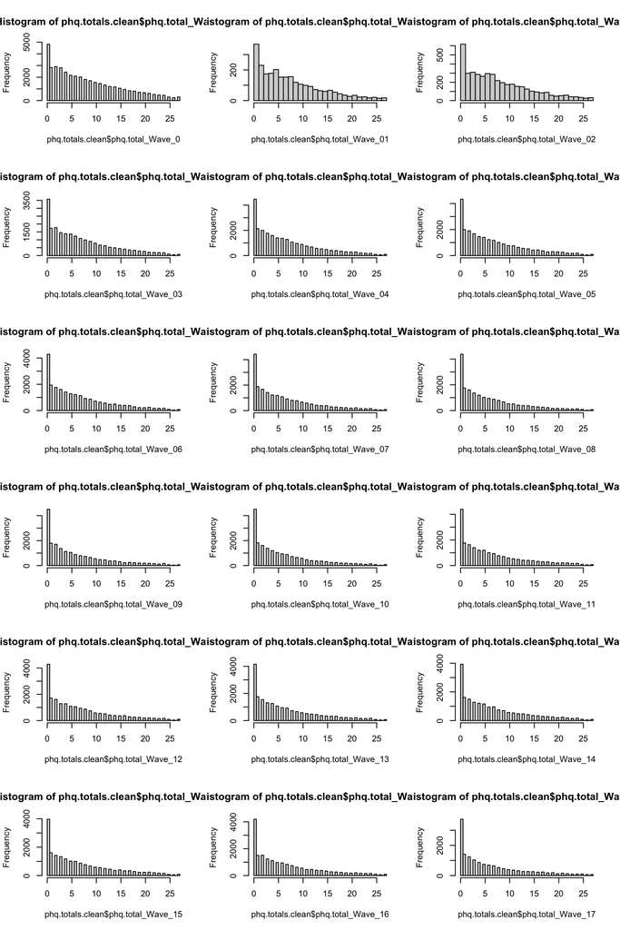

```r
layout(matrix(c(1:18), nrow=6, byrow=T))

hist(phq.totals.clean$phq.total_Wave_0, breaks="FD")
hist(phq.totals.clean$phq.total_Wave_01, breaks="FD")
hist(phq.totals.clean$phq.total_Wave_02, breaks="FD")

hist(phq.totals.clean$phq.total_Wave_03, breaks="FD")
hist(phq.totals.clean$phq.total_Wave_04, breaks="FD")
hist(phq.totals.clean$phq.total_Wave_05, breaks="FD")

hist(phq.totals.clean$phq.total_Wave_06, breaks="FD")
hist(phq.totals.clean$phq.total_Wave_07, breaks="FD")
hist(phq.totals.clean$phq.total_Wave_08, breaks="FD")

hist(phq.totals.clean$phq.total_Wave_09, breaks="FD")
hist(phq.totals.clean$phq.total_Wave_10, breaks="FD")
hist(phq.totals.clean$phq.total_Wave_11, breaks="FD")

hist(phq.totals.clean$phq.total_Wave_12, breaks="FD")
hist(phq.totals.clean$phq.total_Wave_13, breaks="FD")
hist(phq.totals.clean$phq.total_Wave_14, breaks="FD")

hist(phq.totals.clean$phq.total_Wave_15, breaks="FD")
hist(phq.totals.clean$phq.total_Wave_16, breaks="FD")
hist(phq.totals.clean$phq.total_Wave_17, breaks="FD")
```

```r
layout(1)
```